# A Multilevel and Robust Investigation of Delivery Lead Time in E‑Commerce

Tram Anh Hoang

# 1. Introduction and questions

Delivery performance is a central dimension of service quality in e‑commerce, and delays or high variability in delivery lead time can directly affect customer satisfaction and platform reputation. On large marketplaces such as Olist, substantial heterogeneity in delivery times may arise from differences in seller operations, geographic distance between sellers and customers, and order‑level characteristics such as shipment weight or payment conditions.

This project uses the Olist Brazilian e‑commerce dataset to study delivery lead time at the level of individual orders. The primary outcome is delivery lead time, defined as the time between order purchase and the customer delivery date, with additional information from customers, order items, sellers, and payments to characterize geographic and operational drivers. Building on the Advanced Multivariate Statistics syllabus, we adopt a multilevel modelling framework with random intercepts for sellers and customer states, complemented by robust procedures and bootstrap inference.

The analysis addresses three research questions:

- RQ1: How much of the variability in delivery lead time is attributable to seller‑level and geographic‑level heterogeneity?
- RQ2: Which order and shipment characteristics are significantly associated with faster or slower delivery times?
- RQ3: Are the estimated effects robust to extreme observations and sampling variability?

We answer these questions through a sequence of steps: exploratory analysis of raw delivery patterns, construction of a clean order‑level dataset, estimation of baseline and multilevel models, and assessment of robustness using trimming and bootstrap confidence intervals.

# 2. Data and variables

We loaded six Olist tables (orders, order_items, products, customers, sellers, geolocation) plus the category mapping table used for theme engineering. Variable names were standardized to lower case with underscores to simplify manipulation. Basic summaries showed that timestamps in the orders table cover purchases from 2016‑09‑04 to 2018‑10‑17 and estimated deliveries up to 2018‑11‑12.

### 2.1 Load Data

```r
knitr::opts_chunk$set(
  echo    = TRUE,
  message = FALSE,
  warning = FALSE,
  fig.align = "center"
)

library(dplyr)
library(lubridate)
library(ggplot2)
library(tidyverse)
library(janitor)
library(readr)
library(lme4)
library(lmerTest)
library(boot)
library(broom)
library(broom.mixed)
library(lme4)
library(insight)      # variance extraction style like in class
library(performance)  # ICC, R2, model checks
library(boot)         # for boot.ci style CIs (optional)
library(robustlmm)    # robust mixed models (rq3)
library(RColorBrewer)
library(gridExtra)
library(forcats)
library(corrplot)
library(robustbase)

# Minimal visual system with clearer color defaults for HTML readability
brand_blue <- "#2563eb"
brand_teal <- "#0f766e"
brand_orange <- "#d97706"
brand_rose <- "#be123c"
hist_fill <- "#93c5fd"
hist_border <- "white"

options(
  ggplot2.discrete.colour = c(brand_blue, brand_teal, brand_orange, brand_rose, "#7c3aed", "#15803d"),
  ggplot2.discrete.fill = c("#bfdbfe", "#99f6e4", "#fdba74", "#fda4af", "#c4b5fd", "#86efac"),
  ggplot2.continuous.colour = "viridis",
  ggplot2.continuous.fill = "viridis"
)

update_geom_defaults("boxplot", list(fill = "#dbeafe", colour = "#334155"))
update_geom_defaults("histogram", list(fill = hist_fill, colour = hist_border))
update_geom_defaults("line", list(colour = brand_blue))
update_geom_defaults("point", list(colour = brand_blue))
update_geom_defaults("smooth", list(colour = brand_teal, fill = "#ccfbf1"))

theme_set(
  theme_minimal(base_size = 10.5) +
    theme(
      plot.title = element_text(face = "bold", colour = "#0f172a"),
      plot.subtitle = element_text(colour = "#334155"),
      axis.title = element_text(colour = "#1f2937"),
      axis.text = element_text(colour = "#334155"),
      legend.position = "top"
    )
)
set.seed(42)
```

Orders: olist_orders_dataset with order id, customer id, status, purchase and delivery timestamps, estimated delivery.

```r
data_dir <- normalizePath("../data", winslash = "/", mustWork = TRUE)

files <- c(
  orders      = "olist_orders_dataset.csv",
  order_items = "olist_order_items_dataset.csv",
  products    = "olist_products_dataset.csv",
  customers   = "olist_customers_dataset.csv",
  sellers     = "olist_sellers_dataset.csv",
  geolocation = "olist_geolocation_dataset.csv",
  cat_matrix = "product_category_matrix.csv"
)

dfs <- purrr::imap(files, ~ readr::read_csv(file.path(data_dir, .x), show_col_types = FALSE) |>
                     janitor::clean_names())

orders      <- dfs$orders
order_items <- dfs$order_items
products    <- dfs$products
customers   <- dfs$customers
sellers     <- dfs$sellers
geolocation <- dfs$geolocation
cat_matrix  <- dfs$cat_matrix
```

```r
## Quick dimensions
purrr::imap(dfs, ~ tibble(table = .y, n = nrow(.x), p = ncol(.x))) |> bind_rows()
```

| table | n | p |
| --- | --- | --- |
| orders | 99441 | 8 |
| order_items | 112650 | 7 |
| products | 32951 | 9 |
| customers | 99441 | 5 |
| sellers | 3095 | 4 |
| geolocation | 1000163 | 5 |
| cat_matrix | 73 | 6 |

```r
## Variable names
summaries <- purrr::map(dfs, summary)
summaries
```

```
## $orders
##    order_id         customer_id        order_status
##  Length:99441       Length:99441       Length:99441
##  Class :character   Class :character   Class :character
##  Mode  :character   Mode  :character   Mode  :character
##
##
##
##
##  order_purchase_timestamp      order_approved_at
##  Min.   :2016-09-04 21:15:19   Min.   :2016-09-15 12:16:38
##  1st Qu.:2017-09-12 14:46:19   1st Qu.:2017-09-12 23:24:16
##  Median :2018-01-18 23:04:36   Median :2018-01-19 11:36:13
##  Mean   :2017-12-31 08:43:12   Mean   :2017-12-31 18:35:24
##  3rd Qu.:2018-05-04 15:42:16   3rd Qu.:2018-05-04 20:35:10
##  Max.   :2018-10-17 17:30:18   Max.   :2018-09-03 17:40:06
##                                NA's   :160
##  order_delivered_carrier_date  order_delivered_customer_date
##  Min.   :2016-10-08 10:34:01   Min.   :2016-10-11 13:46:32
##  1st Qu.:2017-09-15 22:28:50   1st Qu.:2017-09-25 22:07:22
##  Median :2018-01-24 16:10:58   Median :2018-02-02 19:28:10
##  Mean   :2018-01-04 21:49:48   Mean   :2018-01-14 12:09:19
##  3rd Qu.:2018-05-08 13:37:45   3rd Qu.:2018-05-15 22:48:52
##  Max.   :2018-09-11 19:48:28   Max.   :2018-10-17 13:22:46
##  NA's   :1783                  NA's   :2965
##  order_estimated_delivery_date
##  Min.   :2016-09-30 00:00:00
##  1st Qu.:2017-10-03 00:00:00
##  Median :2018-02-15 00:00:00
##  Mean   :2018-01-24 03:08:37
##  3rd Qu.:2018-05-25 00:00:00
##  Max.   :2018-11-12 00:00:00
##
##
## $order_items
##    order_id         order_item_id     product_id         seller_id
##  Length:112650      Min.   : 1.000   Length:112650      Length:112650
##  Class :character   1st Qu.: 1.000   Class :character   Class :character
##  Mode  :character   Median : 1.000   Mode  :character   Mode  :character
##                     Mean   : 1.198
```

[output cut: 72 more lines]

```
## $cat_matrix
##  product_category_name category_english   category_english_group
##  Length:73             Length:73          Length:73
##  Class :character      Class :character   Class :character
##  Mode  :character      Mode  :character   Mode  :character
##
##
##
##    is_hedonic     is_experience    matrix_quadrant
##  Min.   :0.0000   Min.   :0.0000   Length:73
##  1st Qu.:0.0000   1st Qu.:0.0000   Class :character
##  Median :0.0000   Median :0.0000   Mode  :character
##  Mean   :0.3973   Mean   :0.4384
##  3rd Qu.:1.0000   3rd Qu.:1.0000
##  Max.   :1.0000   Max.   :1.0000
```

### 2.2 Diagnostics

In the **orders** table, 2,965 orders (about 3%) lack a customer delivery timestamp, and 1783 lack a carrier delivery date, while purchase and estimated delivery timestamps are almost always present. Order status is mostly “delivered” (about 96k orders), with smaller groups in “shipped”, “invoiced”, and “canceled”.

```r
#Missingness report (only cols with missing)
miss <- purrr::imap_dfr(dfs, function(df, nm) {
  df |>
    summarise(across(everything(), ~ sum(is.na(.x)))) |>
    pivot_longer(everything(), names_to = "col", values_to = "n_missing") |>
    mutate(pct_missing = n_missing / nrow(df), table = nm) |>
    filter(n_missing > 0)
}) |>
  arrange(desc(pct_missing), desc(n_missing))

miss
```

| col | n_missing | pct_missing | table |
| --- | --- | --- | --- |
| order_delivered_customer_date | 2965 | 2.981668e-02 | orders |
| product_category_name | 610 | 1.851234e-02 | products |
| product_name_lenght | 610 | 1.851234e-02 | products |
| product_description_lenght | 610 | 1.851234e-02 | products |
| product_photos_qty | 610 | 1.851234e-02 | products |
| order_delivered_carrier_date | 1783 | 1.793023e-02 | orders |
| order_approved_at | 160 | 1.608994e-03 | orders |
| product_weight_g | 2 | 6.069619e-05 | products |
| product_length_cm | 2 | 6.069619e-05 | products |
| product_height_cm | 2 | 6.069619e-05 | products |

[output cut: 1 more lines]

```r
check_unique <- function(df, cols) {
  df |> count(across(all_of(cols))) |> filter(n > 1)
}

list(
  sellers_dup_keys     = check_unique(dfs$sellers, "seller_id"),
  customers_dup_keys   = check_unique(dfs$customers, "customer_id"),
  orders_dup_keys      = check_unique(dfs$orders, "order_id"),
  products_dup_keys    = check_unique(dfs$products, "product_id"),
  order_items_dup_keys = check_unique(dfs$order_items, c("order_id", "order_item_id"))
)
```

```
## $sellers_dup_keys
## # A tibble: 0 × 2
## # ℹ 2 variables: seller_id <chr>, n <int>
##
## $customers_dup_keys
## # A tibble: 0 × 2
## # ℹ 2 variables: customer_id <chr>, n <int>
##
## $orders_dup_keys
## # A tibble: 0 × 2
## # ℹ 2 variables: order_id <chr>, n <int>
##
## $products_dup_keys
## # A tibble: 0 × 2
## # ℹ 2 variables: product_id <chr>, n <int>
##
## $order_items_dup_keys
## # A tibble: 0 × 3
## # ℹ 3 variables: order_id <chr>, order_item_id <dbl>, n <int>
```

```r
order_items %>%
  distinct(order_id, seller_id) %>%
  count(order_id, name = "n_sellers") %>%
  count(n_sellers, name = "n_orders") %>%
  arrange(n_sellers)
```

| n_sellers | n_orders |
| --- | --- |
| 1 | 97388 |
| 2 | 1219 |
| 3 | 54 |
| 4 | 3 |
| 5 | 2 |

```r
order_items %>%
  distinct(order_id, seller_id) %>%
  count(order_id, name = "n_sellers") %>%
  summarise(
    n_orders = n(),
    n_multi  = sum(n_sellers > 1),
    pct_multi = 100 * mean(n_sellers > 1),
    max_sellers = max(n_sellers)
  )
```

| n_orders | n_multi | pct_multi | max_sellers |
| --- | --- | --- | --- |
| 98666 | 1278 | 1.295279 | 5 |

Joining order_items indicates that 98,666 orders appear in the order_items table, and that 97,388 of these (98.7%) involve exactly one seller, while only 1,278 orders (1.3%) involve multiple sellers, with a maximum of five sellers in a single order. This pattern supports focusing the main analysis on single‑seller orders so that each observation can be unambiguously associated with a single seller when specifying random intercepts.

```r
#FK integrity
list(
  orders_missing_customers =
    anti_join(dfs$orders, dfs$customers, by = "customer_id"),
  items_missing_orders =
    anti_join(dfs$order_items, dfs$orders, by = "order_id"),
  items_missing_products =
    anti_join(dfs$order_items, dfs$products, by = "product_id"),
  items_missing_sellers =
    anti_join(dfs$order_items, dfs$sellers, by = "seller_id")
) |>
  purrr::imap(~ nrow(.x))
```

```
## $orders_missing_customers
## [1] 0
##
## $items_missing_orders
## [1] 0
##
## $items_missing_products
## [1] 0
##
## $items_missing_sellers
## [1] 0
```

```r
#Orders without items
orders_without_items <- anti_join(dfs$orders, dfs$order_items |> distinct(order_id), by = "order_id")
orders_without_items |> count(order_status, sort = TRUE)
```

| order_status | n |
| --- | --- |
| unavailable | 603 |
| canceled | 164 |
| created | 5 |
| invoiced | 2 |
| shipped | 1 |

Next we construct a very simple raw delivery lead time (without any filtering) and inspect its distribution and obvious data issues.

```r
# Delivery Lead Time and Tails

orders_tmp <- orders %>%
  mutate(

    purchase_ts  = as.POSIXct(order_purchase_timestamp, tz = "UTC"),
    delivered_ts = as.POSIXct(order_delivered_customer_date, tz = "UTC"),
    estimated_ts = as.POSIXct(order_estimated_delivery_date, tz = "UTC"),
  # outcome + lateness vs estimate
    lead_time_days_raw = as.numeric(difftime(delivered_ts, purchase_ts, units = "days")),
    delay_vs_estimated_days = as.numeric(difftime(delivered_ts, estimated_ts, units = "days"))

)
orders_tmp %>%
  summarize(
    orders_n = n(),
    delivered_n = sum(order_status == "delivered", na.rm = TRUE),
    purchase_start = min(purchase_ts, na.rm = TRUE),
    purchase_end = max(purchase_ts, na.rm = TRUE),
    n_estimated_missing = sum(is.na(estimated_ts)),
    n_delay_missing = sum(is.na(delay_vs_estimated_days)),
    delay_min = min(delay_vs_estimated_days, na.rm = TRUE),
    delay_med = median(delay_vs_estimated_days, na.rm = TRUE),
    delay_max = max(delay_vs_estimated_days, na.rm = TRUE)
)
```

| orders_n | delivered_n | purchase_start | purchase_end | n_estimated_missing | n_delay_missing | delay_min | delay_med | delay_max |
| --- | --- | --- | --- | --- | --- | --- | --- | --- |
| 99441 | 96478 | 2016-09-04 21:15:19 | 2018-10-17 17:30:18 | 0 | 2965 | -146.0161 | -11.94894 | 188.9751 |

```r
table(orders_tmp$order_status)
```

```
##
##    approved    canceled     created   delivered    invoiced  processing
##           2         625           5       96478         314         301
##     shipped unavailable
##        1107         609
```

```r
#Check completeness of required timestamps
orders_tmp %>%
  filter(order_status == "delivered") %>%
  summarize(
    missing_purchase_ts = sum(is.na(purchase_ts)),
    missing_delivered_ts = sum(is.na(delivered_ts)),
    missing_estimated_ts = sum(is.na(estimated_ts))
  )
```

| missing_purchase_ts | missing_delivered_ts | missing_estimated_ts |
| --- | --- | --- |
| 0 | 8 | 0 |

```r
# Canceled but delivered timestamp present
orders_tmp |> filter(order_status == "canceled", !is.na(order_delivered_customer_date)) |> select(order_id, order_status, order_delivered_customer_date)
```

| order_id | order_status | order_delivered_customer_date |
| --- | --- | --- |
| 1950d777989f6a877539f53795b4c3c3 | canceled | 2018-03-21 22:03:51 |
| dabf2b0e35b423f94618bf965fcb7514 | canceled | 2016-10-16 14:36:59 |
| 770d331c84e5b214bd9dc70a10b829d0 | canceled | 2016-10-14 15:07:11 |
| 8beb59392e21af5eb9547ae1a9938d06 | canceled | 2016-10-19 18:47:43 |
| 65d1e226dfaeb8cdc42f665422522d14 | canceled | 2016-11-08 10:58:34 |
| 2c45c33d2f9cb8ff8b1c86cc28c11c30 | canceled | 2016-11-09 14:53:50 |

```r
orders_tmp$purchase_ts  <- ymd_hms(orders_tmp$order_purchase_timestamp)
orders_tmp$delivered_ts <- ymd_hms(orders_tmp$order_delivered_customer_date)

orders_tmp$lead_time_days_raw <- as.numeric(
  difftime(orders_tmp$delivered_ts,
           orders_tmp$purchase_ts,
           units = "days")
)

summary(orders_tmp$lead_time_days_raw)
```

```
##     Min.  1st Qu.   Median     Mean  3rd Qu.     Max.     NA's
##   0.5334   6.7665  10.2180  12.5588  15.7204 209.6286     2966
```

```r
# tail threshold
lead_tail <- orders_tmp %>%
  summarize(
    lead_p50 = quantile(lead_time_days_raw, 0.50, na.rm = TRUE),
    lead_p90 = quantile(lead_time_days_raw, 0.90, na.rm = TRUE),
    lead_p95 = quantile(lead_time_days_raw, 0.95, na.rm = TRUE),
    lead_p99 = quantile(lead_time_days_raw, 0.99, na.rm = TRUE),
    lead_max = max(lead_time_days_raw, na.rm = TRUE)
  )

lead_tail
```

| lead_p50 | lead_p90 | lead_p95 | lead_p99 | lead_max |
| --- | --- | --- | --- | --- |
| 10.21801 | 23.09768 | 29.27614 | 46.04997 | 209.6286 |

```r
trim_cut_99 <- quantile(orders_tmp$lead_time_days_raw, 0.99, na.rm = TRUE)
trim_cut_98 <- quantile(orders_tmp$lead_time_days_raw, 0.98, na.rm = TRUE)
trim_cut_99
```

```
##      99%
## 46.04997
```

```r
trim_cut_98
```

```
##      98%
## 38.95495
```

```r
table(
  negative = orders_tmp$lead_time_days_raw < 0,
  missing  = is.na(orders_tmp$lead_time_days_raw)
)
```

```
##         missing
## negative FALSE  TRUE
##    FALSE 96475     0
```

Overall most orders delivered within about 5–20 days, median lead time is around 10.2 days, the mean 12.6 days, with the 95th percentile at roughly 29 days. No negative durations were observed, but about 3% of orders have missing lead times. These quantiles indicate a strongly right-skewed distribution with a long upper tail and suggest using the 98th–99th percentiles (roughly 39–46 days) as natural thresholds for defining “extreme” lead times in subsequent robustness checks.

To explore potential hierarchical structure, we merge orders with customers and sellers and summarize raw lead times by customer_state and seller_state. Customer‑state summaries show substantial differences in typical delivery times: for example, the mean lead time in São Paulo (SP) is below 9 days, while several northern states such as Amazonas (AM) and Pará (PA) have means above 23–26 days and much higher upper quantiles. Seller‑state summaries also display marked variation, though with fewer observations per group, suggesting that both customer geography and seller location contribute to heterogeneity in delivery performance.

```r
# Patterns in customer and seller state delivery
orders_raw <- orders_tmp %>%
  mutate(
    lead_time_days_raw = as.numeric(difftime(delivered_ts, purchase_ts, units = "days"))
  )

# Attach customer_state to orders (raw, no filtering)
orders_cust_raw <- orders_raw %>%
  left_join(customers %>% select(customer_id, customer_state),
            by = "customer_id")

#For sellers: collapse items to one seller per order (rough look)
# (also keep n_sellers so you can see how many orders are multi-seller)
order_seller_raw <- order_items %>%
  distinct(order_id, seller_id) %>%
  group_by(order_id) %>%
  summarise(
    seller_id = first(seller_id),
    n_sellers = n_distinct(seller_id),
    .groups = "drop"
  )

orders_cs_raw <- orders_cust_raw %>%
  left_join(order_seller_raw, by = "order_id") %>%
  left_join(sellers %>% select(seller_id, seller_state),
            by = "seller_id")

#Simple summaries by state (like tapply(summary))
cust_state_summ <- orders_cs_raw %>%
  group_by(customer_state) %>%
  summarise(
    n     = sum(!is.na(lead_time_days_raw)),
    mean  = mean(lead_time_days_raw, na.rm = TRUE),
    sd    = sd(lead_time_days_raw, na.rm = TRUE),
    min   = min(lead_time_days_raw, na.rm = TRUE),
    q25   = quantile(lead_time_days_raw, .25, na.rm = TRUE),
    med   = median(lead_time_days_raw, na.rm = TRUE),
    q75   = quantile(lead_time_days_raw, .75, na.rm = TRUE),
    p90   = quantile(lead_time_days_raw, .90, na.rm = TRUE),
    p95   = quantile(lead_time_days_raw, .95, na.rm = TRUE),
    max   = max(lead_time_days_raw, na.rm = TRUE),
    .groups = "drop"
  ) %>%
  arrange(desc(n))

seller_state_summ <- orders_cs_raw %>%
  group_by(seller_state) %>%
  summarise(
    n     = sum(!is.na(lead_time_days_raw)),
    mean  = mean(lead_time_days_raw, na.rm = TRUE),
    sd    = sd(lead_time_days_raw, na.rm = TRUE),
    min   = min(lead_time_days_raw, na.rm = TRUE),
    q25   = quantile(lead_time_days_raw, .25, na.rm = TRUE),
    med   = median(lead_time_days_raw, na.rm = TRUE),
    q75   = quantile(lead_time_days_raw, .75, na.rm = TRUE),
    p90   = quantile(lead_time_days_raw, .90, na.rm = TRUE),
    p95   = quantile(lead_time_days_raw, .95, na.rm = TRUE),
    max   = max(lead_time_days_raw, na.rm = TRUE),
    .groups = "drop"
  ) %>%
  arrange(desc(n))

cust_state_summ
```

| customer_state | n | mean | sd | min | q25 | med | q75 | p90 | p95 | max |
| --- | --- | --- | --- | --- | --- | --- | --- | --- | --- | --- |
| SP | 40495 | 8.761357 | 6.752938 | 0.7813657 | 4.822986 | 7.210289 | 10.93762 | 15.77135 | 19.99191 | 191.46354 |
| RJ | 12353 | 15.310053 | 11.522270 | 0.5334144 | 8.109977 | 12.041308 | 18.47345 | 29.09449 | 38.31579 | 208.35176 |
| MG | 11355 | 12.010258 | 7.198316 | 1.0539005 | 7.401620 | 10.313646 | 14.55624 | 20.20440 | 24.70316 | 187.74384 |
| RS | 5344 | 15.300276 | 9.177480 | 1.0737384 | 9.391768 | 13.177488 | 18.51113 | 25.88308 | 32.84396 | 186.23677 |
| PR | 4922 | 11.992819 | 6.983113 | 1.0878704 | 7.470327 | 10.426134 | 14.58567 | 20.11766 | 24.74778 | 97.46851 |
| SC | 3547 | 14.959297 | 8.581277 | 1.5418981 | 9.004630 | 13.016400 | 18.77771 | 25.81929 | 30.98580 | 98.17800 |
| BA | 3256 | 19.335466 | 11.693903 | 0.8634259 | 12.437144 | 16.913964 | 23.16157 | 31.81253 | 36.82407 | 167.94375 |
| DF | 2080 | 12.967568 | 7.055114 | 1.2666782 | 8.086308 | 11.364925 | 16.07222 | 21.63961 | 25.91629 | 68.62115 |
| ES | 1995 | 15.789307 | 10.640684 | 2.1617940 | 9.974167 | 13.636956 | 18.93174 | 25.34981 | 31.15408 | 209.62861 |
| GO | 1957 | 15.606339 | 9.283502 | 1.2601157 | 10.253484 | 13.949606 | 18.47832 | 24.83900 | 29.27367 | 181.06052 |

[output cut: 17 more lines]

```r
seller_state_summ
```

| seller_state | n | mean | sd | min | q25 | med | q75 | p90 | p95 | max |
| --- | --- | --- | --- | --- | --- | --- | --- | --- | --- | --- |
| SP | 68417 | 12.36369 | 9.598201 | 0.7813657 | 6.274537 | 9.999086 | 15.60378 | 23.24142 | 29.58742 | 208.35176 |
| MG | 7648 | 12.87778 | 10.086263 | 0.8907523 | 7.133044 | 10.792772 | 15.78989 | 22.29519 | 28.56134 | 209.62861 |
| PR | 7428 | 13.43633 | 9.280403 | 1.0878704 | 7.717167 | 11.222454 | 16.18905 | 23.16386 | 30.07637 | 168.18191 |
| RJ | 4188 | 12.09833 | 9.209005 | 0.5334144 | 6.462028 | 9.965509 | 14.94567 | 22.17571 | 27.96273 | 142.46682 |
| SC | 3551 | 13.75527 | 9.101514 | 1.1500116 | 8.213600 | 11.746065 | 16.42359 | 23.08888 | 28.97896 | 133.24115 |
| RS | 1949 | 11.53346 | 8.447333 | 1.0737384 | 6.860231 | 9.586157 | 13.81275 | 20.17801 | 26.06038 | 189.86316 |
| DF | 803 | 12.45603 | 8.058591 | 1.2666782 | 7.553061 | 10.487836 | 15.15893 | 21.00313 | 27.02584 | 79.86326 |
| BA | 549 | 13.89625 | 9.983458 | 2.0505556 | 9.025961 | 11.765197 | 16.39880 | 21.82577 | 26.59067 | 168.08280 |
| GO | 451 | 12.86019 | 7.957837 | 1.2601157 | 7.811713 | 10.991910 | 15.86976 | 22.08079 | 27.57736 | 62.54786 |
| PE | 403 | 12.81158 | 6.657183 | 1.6699769 | 8.464080 | 11.101146 | 15.26108 | 20.28951 | 26.23342 | 49.26892 |

[output cut: 14 more lines]

Grouped summaries show strong heterogeneity in delivery times across customer states: for instance, the mean raw lead time in SP is about 8.8 days, whereas several northern states (e.g., AM, PA) show means above 23–26 days and much higher upper quantiles. Similar variation appears across seller states, although with fewer groups and smaller sample sizes. These patterns indicate that both geography and seller behavior contribute to variability in lead time and motivate the use of mixed‑effects models with random intercepts for customer state and seller identity.

Because delivery times are highly right‑skewed with a long tail, and we aim to interpret effects in relative terms, we model the logarithm of delivery lead time (equivalently, log1p(lead_time_days)) as the response in the mixed‑effects models, so that model assumptions are better satisfied and fixed effects can be read as approximate percentage differences in expected delivery time. Detailed state-level lead-time boxplots and routing contrasts are presented once in Section 4.1 to avoid repeated visuals across sections. These initial diagnostics highlight three key features: a skewed and heavy‑tailed distribution of delivery lead time, a small fraction of missing or unusable timestamps, and clear heterogeneity across customer and seller states. In the next section we formalize the cleaning rules and analysis plan, define a log‑transformed lead‑time outcome, and construct a clean order‑level dataset incorporating customer and seller information for multilevel modeling.

## 2.3 Cleaning

In this step, we focus on constructing a coherent base sample for modelling delivery lead time. We first restrict the orders table to completed deliveries with non-missing purchase and customer delivery timestamps and nonnegative raw lead times, so that the outcome is well defined and not driven by obvious data errors or incomplete processes. Given that almost all orders in the order_items table involve a single seller, we further retain only orders linked to exactly one seller in order to obtain a clear seller-level grouping structure for the subsequent mixed-effects models; this removes only about 1.3% of orders while ensuring that each observation can be uniquely associated with a single seller random intercept. We then attach minimal geographic information by joining customer_state and seller_state and construct an `is_same_state` indicator, together with simple calendar controls (purchase year, weekday, and broad season), which will later allow us to examine basic temporal patterns and distinguish within-state from cross-state shipments without overcomplicating the feature space at this stage.

```r
# 1) Base delivered sample with valid lead time
orders_base <- orders_tmp %>%
  filter(order_status == "delivered") %>%
  filter(!is.na(purchase_ts), !is.na(delivered_ts)) %>%
  filter(!is.na(lead_time_days_raw), lead_time_days_raw >= 0)

# 2) Restrict to orders linked to exactly 1 seller
seller_per_order <- order_items %>%
  distinct(order_id, seller_id) %>%
  count(order_id, name = "n_sellers") %>%
  left_join(
    order_items %>%
      group_by(order_id) %>%
      summarise(seller_id = first(seller_id), .groups = "drop"),
    by = "order_id"
  )

# collapse to one seller per order and keep n_sellers
order_seller_raw <- order_items %>%
  distinct(order_id, seller_id) %>%
  group_by(order_id) %>%
  summarise(
    seller_id = first(seller_id),
    n_sellers = n_distinct(seller_id),
    .groups = "drop"
  )

# attach customer and seller info
orders_cs_raw <- orders_base %>%
  left_join(customers %>% select(customer_id, customer_state), by = "customer_id") %>%
  left_join(order_seller_raw, by = "order_id") %>%
  left_join(sellers %>% select(seller_id, seller_state), by = "seller_id")

orders_1seller <- orders_base %>%
  left_join(seller_per_order, by = "order_id") %>%
  filter(n_sellers == 1)

# 3) Minimal geography attaches (states only)
orders_clean_core <- orders_1seller %>%
  left_join(customers %>% select(customer_id, customer_state), by = "customer_id") %>%
  left_join(sellers   %>% select(seller_id, seller_state),     by = "seller_id") %>%
  mutate(
    is_same_state = (customer_state == seller_state),
    purchase_year  = factor(year(purchase_ts)),
    purchase_wday  = factor(wday(purchase_ts, label = TRUE, abbr = TRUE)),
    season = factor(
      case_when(
        month(purchase_ts) %in% c(12, 1, 2) ~ "DJF",
        month(purchase_ts) %in% c(3, 4, 5)  ~ "MAM",
        month(purchase_ts) %in% c(6, 7, 8)  ~ "JJA",
        month(purchase_ts) %in% c(9, 10, 11) ~ "SON",
        TRUE ~ NA_character_
      ),
      levels = c("DJF", "MAM", "JJA", "SON")
    )
  )

tibble(
  step = c("Delivered + valid timestamps + lead_time>=0", "Restricted to 1 seller/order"),
  n_orders = c(nrow(orders_base), nrow(orders_clean_core))
)
```

| step | n_orders |
| --- | --- |
| Delivered + valid timestamps + lead_time>=0 | 96469 |
| Restricted to 1 seller/order | 95194 |

```r
dim(orders_clean_core)
```

```
## [1] 95194    21
```

```r
summary(orders_clean_core)
```

```
##    order_id         customer_id        order_status
##  Length:95194       Length:95194       Length:95194
##  Class :character   Class :character   Class :character
##  Mode  :character   Mode  :character   Mode  :character
##
##
##
##
##  order_purchase_timestamp      order_approved_at
##  Min.   :2016-09-15 12:16:38   Min.   :2016-09-15 12:16:38
##  1st Qu.:2017-09-13 18:49:02   1st Qu.:2017-09-14 03:04:55
##  Median :2018-01-20 12:14:21   Median :2018-01-20 18:30:33
##  Mean   :2018-01-01 12:53:25   Mean   :2018-01-02 00:17:23
##  3rd Qu.:2018-05-05 11:00:06   3rd Qu.:2018-05-05 17:16:10
##  Max.   :2018-08-29 15:00:37   Max.   :2018-08-29 15:10:26
##                                NA's   :14
##  order_delivered_carrier_date  order_delivered_customer_date
##  Min.   :2016-10-08 10:34:01   Min.   :2016-10-11 13:46:32
##  1st Qu.:2017-09-15 21:24:48   1st Qu.:2017-09-25 20:06:10
##  Median :2018-01-24 00:52:45   Median :2018-02-02 16:12:52
##  Mean   :2018-01-04 18:39:16   Mean   :2018-01-14 03:23:20
##  3rd Qu.:2018-05-08 13:43:00   3rd Qu.:2018-05-15 20:32:50
##  Max.   :2018-09-11 19:48:28   Max.   :2018-10-17 13:22:46
##  NA's   :1
##  order_estimated_delivery_date  purchase_ts
##  Min.   :2016-10-04 00:00:00   Min.   :2016-09-15 12:16:38
##  1st Qu.:2017-10-05 00:00:00   1st Qu.:2017-09-13 18:49:02
##  Median :2018-02-16 00:00:00   Median :2018-01-20 12:14:21
##  Mean   :2018-01-25 06:01:07   Mean   :2018-01-01 12:53:25
##  3rd Qu.:2018-05-28 00:00:00   3rd Qu.:2018-05-05 11:00:06
##  Max.   :2018-10-25 00:00:00   Max.   :2018-08-29 15:00:37
##
##   delivered_ts                  estimated_ts                 lead_time_days_raw
##  Min.   :2016-10-11 13:46:32   Min.   :2016-10-04 00:00:00   Min.   :  0.5334
##  1st Qu.:2017-09-25 20:06:10   1st Qu.:2017-10-05 00:00:00   1st Qu.:  6.7949
##  Median :2018-02-02 16:12:52   Median :2018-02-16 00:00:00   Median : 10.2518
##  Mean   :2018-01-14 03:23:20   Mean   :2018-01-25 06:01:07   Mean   : 12.6041
##  3rd Qu.:2018-05-15 20:32:50   3rd Qu.:2018-05-28 00:00:00   3rd Qu.: 15.7927
##  Max.   :2018-10-17 13:22:46   Max.   :2018-10-25 00:00:00   Max.   :209.6286
##
##  delay_vs_estimated_days   n_sellers  seller_id         customer_state
##  Min.   :-146.02         Min.   :1   Length:95194       Length:95194
##  1st Qu.: -16.22         1st Qu.:1   Class :character   Class :character
##  Median : -11.55         Median :1   Mode  :character   Mode  :character
##  Mean   : -11.11         Mean   :1
##  3rd Qu.:  -6.36         3rd Qu.:1
##  Max.   : 188.98         Max.   :1
##
##  seller_state       is_same_state   purchase_year purchase_wday season
##  Length:95194       Mode :logical   2016:  264    Sun:11437     DJF:21314
##  Class :character   FALSE:60961     2017:42948    Mon:15500     MAM:28562
##  Mode  :character   TRUE :34233     2018:51982    Tue:15314     JJA:29340
##                                                   Wed:14903     SON:15978
##                                                   Thu:14141
##                                                   Fri:13506
##                                                   Sat:10393
```

# 3. Data Construction

In this section we construct order‑level predictors for delivery lead time and put them on scales suitable for mixed‑effects modelling. We log‑transform the highly skewed outcome and shipment variables (weight, volume, value, freight, items), standardize continuous predictors, and collapse very rare product categories into an ‘other’ level, while carefully checking ranges, missingness, and collinearity. Missing or zero shipment dimensions are handled via simple median‑by‑category imputation with missingness indicators, and a complete‑case variant of the data confirms that these choices have negligible impact on the analysis.

## 3.1 Variables Transformation

### 3.1.1 Predictors Transformation

For predictors, we assigned each order a main product category by aggregating product categories at the order level, weighting items by their value (price + freight). Among 74 categories, 22 have fewer than 100 orders and together account for only about 0.85% of orders, so we collapsed these rare levels and unknowns into a single ‘other’ category to avoid unstable estimates from very small groups. The cleaned factor main_cat_pt_collapsed thus retains interpretable top categories while collecting very low‑volume or missing labels into a single residual level.

#### Enrich with category

```r
#Order-level distribution
# 1) main category per order (PT), weighted by item value
products_pt <- products %>%
  mutate(product_category_name = fct_explicit_na(product_category_name, na_level = "unknown"))

orders_main_cat_pt <- order_items %>%
  semi_join(orders_clean_core %>% select(order_id), by = "order_id") %>%
  left_join(products_pt %>% select(product_id, product_category_name), by = "product_id") %>%
  mutate(
    product_category_name = fct_explicit_na(product_category_name, "unknown"),
    item_value = price + freight_value
  ) %>%
  group_by(order_id, product_category_name) %>%
  summarise(cat_value = sum(item_value, na.rm = TRUE), .groups = "drop") %>%
  group_by(order_id) %>%
  arrange(desc(cat_value), .by_group = TRUE) %>%
  summarise(main_cat_pt = first(product_category_name), .groups = "drop")

orders_cat_pt_counts <- orders_main_cat_pt %>%
  count(main_cat_pt, name = "n_orders") %>%
  arrange(desc(n_orders))
```

```r
orders_cat_pt_counts %>%
  summarise(
    n_levels = n(),
    pct_levels_lt_50  = mean(n_orders < 50) * 100,
    pct_levels_lt_100 = mean(n_orders < 100) * 100,
    tail_share_lt_100 = sum(n_orders[n_orders < 100]) / sum(n_orders) * 100
  )
```

| n_levels | pct_levels_lt_50 | pct_levels_lt_100 | tail_share_lt_100 |
| --- | --- | --- | --- |
| 74 | 21.62162 | 29.72973 | 0.8540454 |

```r
# 2) counts per category (order-level)
cat_counts <- orders_main_cat_pt %>%
  count(main_cat_pt, name = "n_orders") %>%
  mutate(
    share = n_orders / sum(n_orders),
    share_pct = 100 * share
  ) %>%
  arrange(n_orders)

low_freq_cats <- cat_counts %>%
  filter(n_orders < 100, main_cat_pt != "unknown") %>%
  arrange(n_orders)


low_freq_cats
```

| main_cat_pt | n_orders | share | share_pct |
| --- | --- | --- | --- |
| seguros_e_servicos | 2 | 2.100973e-05 | 0.002100973 |
| fashion_roupa_infanto_juvenil | 5 | 5.252432e-05 | 0.005252432 |
| pc_gamer | 6 | 6.302918e-05 | 0.006302918 |
| la_cuisine | 11 | 1.155535e-04 | 0.011555350 |
| cds_dvds_musicais | 12 | 1.260584e-04 | 0.012605837 |
| portateis_cozinha_e_preparadores_de_alimentos | 13 | 1.365632e-04 | 0.013656323 |
| artes_e_artesanato | 21 | 2.206021e-04 | 0.022060214 |
| casa_conforto_2 | 22 | 2.311070e-04 | 0.023110700 |
| fashion_esporte | 24 | 2.521167e-04 | 0.025211673 |
| fraldas_higiene | 25 | 2.626216e-04 | 0.026262159 |

[output cut: 12 more lines]

```r
low_freq_cats %>%
  summarise(
    n_low_levels = n(),
    total_orders_in_low_levels = sum(n_orders),
    pct_orders_in_low_levels = 100 * sum(n_orders) / sum(cat_counts$n_orders)
  )
```

| n_low_levels | total_orders_in_low_levels | pct_orders_in_low_levels |
| --- | --- | --- |
| 22 | 813 | 0.8540454 |

22 categories have <100 orders and together represent 0.85% of orders, so we will collapse them to “other”.

```r
# identify sparse levels to collapse
sparse_levels <- low_freq_cats %>% pull(main_cat_pt)
orders_model <- orders_clean_core %>%
  left_join(orders_main_cat_pt, by = "order_id") %>%
  mutate(
    main_cat_pt = fct_explicit_na(main_cat_pt, "unknown"),
    main_cat_pt_collapsed = fct_collapse(main_cat_pt, other = sparse_levels),
    main_cat_pt_collapsed = fct_collapse(main_cat_pt_collapsed, other = "unknown")
  )
# check result
orders_model %>% count(main_cat_pt_collapsed, sort = TRUE)
```

| main_cat_pt_collapsed | n |
| --- | --- |
| cama_mesa_banho | 8920 |
| beleza_saude | 8559 |
| esporte_lazer | 7412 |
| informatica_acessorios | 6416 |
| moveis_decoracao | 6041 |
| utilidades_domesticas | 5593 |
| relogios_presentes | 5419 |
| telefonia | 4044 |
| automotivo | 3756 |
| brinquedos | 3749 |

[output cut: 42 more lines]

Product themes Collapsing detailed categories into binary indicators for product behavior:

- `is_hedonic`: hedonic vs utilitarian
- `is_experience`: experience vs search

We construct four product-theme quadrants by crossing the classic search vs experience dimension (Nelson, 1970, 1974) with the utilitarian vs hedonic distinction in shopping value and consumption (Hirschman & Holbrook, 1982; Babin et al., 1994), then map Olist categories into these quadrants.

Search vs experience goods: - Search goods: customers can evaluate quality before purchase (specifications, reviews, images), for example many electronics or tools. - Experience goods: quality is clearer after use, for example fashion, cosmetics, or hobby products.

Utilitarian vs hedonic goods: - Utilitarian goods: functional and problem-solving products with practical benefits, for example office supplies or appliances. - Hedonic goods: products linked to pleasure, enjoyment, or self-expression, for example gifts, games, and decorative items.

Crossing these dimensions yields four quadrants: - Search + Utilitarian: for example tools, office goods, and basic electronics. - Search + Hedonic: for example high-spec leisure electronics and some hobby categories. - Experience + Utilitarian: for example function-oriented apparel, health/beauty essentials, and practical personal-care products. - Experience + Hedonic: for example decor, gifts, and fashion-accessory categories.

Why this aggregation is used in this project: - It stabilizes estimation by reducing dozens of sparse Olist categories into a small number of interpretable groups. - It captures differences in how delivery timing may matter by product context. For search-utilitarian goods, customers may mainly value reliable, predictable delivery; for experience-hedonic or gift-like goods, late delivery can more strongly reduce satisfaction because timing is part of the experience.

This is a conceptual control for broad product mix, not a causal treatment variable.

```r
category_matrix <- readr::read_csv(
  file.path(data_dir, "product_category_matrix.csv"),
  show_col_types = FALSE
) %>%
  janitor::clean_names() %>%
  transmute(
    product_category_name = as.character(product_category_name),
    category_english = as.character(category_english),
    is_hedonic = as.integer(is_hedonic),
    is_experience = as.integer(is_experience)
  )

theme_quadrant_lookup <- category_matrix %>%
  mutate(
    theme_name = dplyr::case_when(
      is_experience == 0 & is_hedonic == 0 ~ "Search + Utilitarian",
      is_experience == 0 & is_hedonic == 1 ~ "Search + Hedonic",
      is_experience == 1 & is_hedonic == 0 ~ "Experience + Utilitarian",
      is_experience == 1 & is_hedonic == 1 ~ "Experience + Hedonic",
      TRUE ~ "Unknown"
    ),
    rationale = dplyr::case_when(
      theme_name == "Search + Utilitarian" ~ "Durable and spec-driven items; delivery reliability and utility are salient.",
      theme_name == "Search + Hedonic" ~ "Spec-comparable but discretionary goods; convenience and timing can shape purchase experience.",
      theme_name == "Experience + Utilitarian" ~ "Use-value goods with quality learned in use; delivery speed supports practical planning.",
      theme_name == "Experience + Hedonic" ~ "Affective and experiential goods; delivery timeliness affects perceived excitement and satisfaction.",
      TRUE ~ "Fallback mapping for categories outside the four quadrants."
    )
  ) %>%
  transmute(
    olist_category = product_category_name,
    english_label = category_english,
    theme = theme_name,
    rationale
  ) %>%
  arrange(theme, olist_category)
```

```r
theme_quadrant_lookup
```

| olist_category | english_label | theme | rationale |
| --- | --- | --- | --- |
| artes | art | Experience + Hedonic | Affective and experiential goods; delivery timeliness affects perceived excitement and satisfaction. |
| artes_e_artesanato | arts_and_craftmanship | Experience + Hedonic | Affective and experiential goods; delivery timeliness affects perceived excitement and satisfaction. |
| beleza_saude | health_beauty | Experience + Hedonic | Affective and experiential goods; delivery timeliness affects perceived excitement and satisfaction. |
| esporte_lazer | sports_leisure | Experience + Hedonic | Affective and experiential goods; delivery timeliness affects perceived excitement and satisfaction. |
| fashion_bolsas_e_acessorios | fashion_bags_accessories | Experience + Hedonic | Affective and experiential goods; delivery timeliness affects perceived excitement and satisfaction. |
| fashion_calcados | fashion_shoes | Experience + Hedonic | Affective and experiential goods; delivery timeliness affects perceived excitement and satisfaction. |
| fashion_esporte | fashion_sport | Experience + Hedonic | Affective and experiential goods; delivery timeliness affects perceived excitement and satisfaction. |
| fashion_roupa_feminina | fashion_female_clothing | Experience + Hedonic | Affective and experiential goods; delivery timeliness affects perceived excitement and satisfaction. |
| fashion_roupa_infanto_juvenil | fashion_childrens_clothes | Experience + Hedonic | Affective and experiential goods; delivery timeliness affects perceived excitement and satisfaction. |
| fashion_roupa_masculina | fashion_male_clothing | Experience + Hedonic | Affective and experiential goods; delivery timeliness affects perceived excitement and satisfaction. |

[output cut: 63 more lines]

```r
category_matrix_model <- category_matrix %>%
  dplyr::select(product_category_name, is_hedonic, is_experience)
```

```r
order_theme_raw <- orders_main_cat_pt %>%
  mutate(main_cat_pt_chr = as.character(main_cat_pt)) %>%
  left_join(category_matrix_model, by = c("main_cat_pt_chr" = "product_category_name"))

order_theme <- order_theme_raw %>%
  transmute(
    order_id,
    theme_matched = !is.na(is_hedonic) & !is.na(is_experience),
    is_hedonic = if_else(theme_matched, as.integer(is_hedonic), NA_integer_),
    is_experience = if_else(theme_matched, as.integer(is_experience), NA_integer_)
  )

orders_model <- orders_model %>%
  select(-any_of(c("theme_matched", "is_hedonic", "is_experience", "theme_name"))) %>%
  left_join(order_theme, by = "order_id") %>%
  mutate(
    # After theme matching, unmatched categories are collapsed into "other"
    main_cat_pt_collapsed = if_else(
      !coalesce(theme_matched, FALSE),
      "other",
      as.character(main_cat_pt_collapsed)
    ),
    main_cat_pt_collapsed = factor(main_cat_pt_collapsed),
    # Keep binary flags numeric for modeling; unmatched set to 0 after collapse
    is_hedonic = as.integer(coalesce(is_hedonic, 0L)),
    is_experience = as.integer(coalesce(is_experience, 0L)),
    theme_name = case_when(
      !coalesce(theme_matched, FALSE) ~ "Other (unmapped)",
      is_experience == 0 & is_hedonic == 0 ~ "Search + Utilitarian",
      is_experience == 0 & is_hedonic == 1 ~ "Search + Hedonic",
      is_experience == 1 & is_hedonic == 0 ~ "Experience + Utilitarian",
      is_experience == 1 & is_hedonic == 1 ~ "Experience + Hedonic",
      TRUE ~ "Unknown"
    )
  ) %>%
  select(-theme_matched)

orders_model %>%
  summarise(
    pct_hedonic = mean(is_hedonic == 1, na.rm = TRUE) * 100,
    pct_experience = mean(is_experience == 1, na.rm = TRUE) * 100
  )
```

| pct_hedonic | pct_experience |
| --- | --- |
| 39.95945 | 58.04673 |

```r
orders_model %>%
  count(theme_name, name = "n_orders") %>%
  mutate(pct_orders = 100 * n_orders / sum(n_orders)) %>%
  arrange(desc(n_orders))
```

| theme_name | n_orders | pct_orders |
| --- | --- | --- |
| Search + Utilitarian | 28535 | 29.975629 |
| Experience + Hedonic | 27977 | 29.389457 |
| Experience + Utilitarian | 27280 | 28.657268 |
| Search + Hedonic | 10062 | 10.569994 |
| Other (unmapped) | 1340 | 1.407652 |

```r
# Sanity check: categories with no theme mapping in category_matrix
order_theme_raw %>%
  filter(is.na(is_hedonic) | is.na(is_experience)) %>%
  count(main_cat_pt_chr, name = "n_orders") %>%
  arrange(desc(n_orders))
```

| main_cat_pt_chr | n_orders |
| --- | --- |
| unknown | 1340 |

#### Enrich with region

Using `POP2017_20220905.xls`, we build state-level population (2017) from municipal totals and map each UF to a macro-region (North, Northeast, Central-West, Southeast, South). We then attach customer/seller region and population to each order. We follow the standard IBGE macro-region grouping of Brazilian states.

```r
pop_mun_raw <- readxl::read_excel(
  file.path(data_dir, "POP2017_20220905.xls"),
  sheet = "Municípios",
  col_names = FALSE
)

pop_mun <- pop_mun_raw %>%
  slice(-(1:2)) %>%
  transmute(
    uf = stringr::str_to_upper(stringr::str_trim(as.character(...1))),
    pop_2017_mun = readr::parse_number(
      as.character(...5),
      locale = readr::locale(grouping_mark = ".", decimal_mark = ",")
    )
  ) %>%
  filter(!is.na(uf), !is.na(pop_2017_mun))

pop_state_2017 <- pop_mun %>%
  group_by(uf) %>%
  summarise(
    pop_2017_state = sum(pop_2017_mun, na.rm = TRUE),
    n_municipios = n(),
    .groups = "drop"
  )

uf_region <- tibble::tribble(
  ~uf, ~region,
  "AC", "North", "AL", "Northeast", "AP", "North", "AM", "North", "BA", "Northeast",
  "CE", "Northeast", "DF", "Central-West", "ES", "Southeast", "GO", "Central-West",
  "MA", "Northeast", "MT", "Central-West", "MS", "Central-West", "MG", "Southeast",
  "PA", "North", "PB", "Northeast", "PR", "South", "PE", "Northeast", "PI", "Northeast",
  "RJ", "Southeast", "RN", "Northeast", "RS", "South", "RO", "North", "RR", "North",
  "SC", "South", "SP", "Southeast", "SE", "Northeast", "TO", "North"
)

ibge_region_mapping <- uf_region %>%
  mutate(region = factor(region, levels = c("North", "Northeast", "Central-West", "Southeast", "South"))) %>%
  arrange(region, uf) %>%
  group_by(region) %>%
  summarise(
    n_states = n(),
    states = paste(uf, collapse = ", "),
    .groups = "drop"
  )

ibge_region_mapping
```

| region | n_states | states |
| --- | --- | --- |
| North | 7 | AC, AM, AP, PA, RO, RR, TO |
| Northeast | 9 | AL, BA, CE, MA, PB, PE, PI, RN, SE |
| Central-West | 4 | DF, GO, MS, MT |
| Southeast | 4 | ES, MG, RJ, SP |
| South | 3 | PR, RS, SC |

```r
state_region_pop <- uf_region %>%
  left_join(pop_state_2017, by = "uf")

orders_model <- orders_model %>%
  select(-any_of(c(
    "customer_region", "seller_region",
    "customer_state_pop_2017", "seller_state_pop_2017",
    "is_same_region"
  ))) %>%
  left_join(
    state_region_pop %>%
      transmute(
        customer_state = uf,
        customer_region = region,
        customer_state_pop_2017 = pop_2017_state
      ),
    by = "customer_state"
  ) %>%
  left_join(
    state_region_pop %>%
      transmute(
        seller_state = uf,
        seller_region = region,
        seller_state_pop_2017 = pop_2017_state
      ),
    by = "seller_state"
  ) %>%
  mutate(
    is_same_region = customer_region == seller_region
  )

orders_model %>%
  summarise(
    pct_na_customer_region = mean(is.na(customer_region)) * 100,
    pct_na_seller_region = mean(is.na(seller_region)) * 100,
    pct_same_region = mean(is_same_region, na.rm = TRUE) * 100
  )
```

| pct_na_customer_region | pct_na_seller_region | pct_same_region |
| --- | --- | --- |
| 0 | 0 | 62.15833 |

```r
# Region distribution: customer vs seller
region_dist <- bind_rows(
  orders_model %>%
    count(region = customer_region, name = "n_orders") %>%
    mutate(side = "Customer"),
  orders_model %>%
    count(region = seller_region, name = "n_orders") %>%
    mutate(side = "Seller")
) %>%
  filter(!is.na(region)) %>%
  group_by(side) %>%
  mutate(
    pct_orders = 100 * n_orders / sum(n_orders),
    region = factor(region, levels = c("North", "Northeast", "Central-West", "Southeast", "South"))
  ) %>%
  ungroup()

region_dist %>%
  arrange(side, desc(n_orders))
```

| region | n_orders | side | pct_orders |
| --- | --- | --- | --- |
| Southeast | 65281 | Customer | 68.57680106 |
| South | 13625 | Customer | 14.31287686 |
| Northeast | 8963 | Customer | 9.41550938 |
| Central-West | 5547 | Customer | 5.82704792 |
| North | 1778 | Customer | 1.86776478 |
| Southeast | 79492 | Seller | 83.50526294 |
| South | 12736 | Seller | 13.37899447 |
| Northeast | 1515 | Seller | 1.59148686 |
| Central-West | 1427 | Seller | 1.49904406 |
| North | 24 | Seller | 0.02521167 |

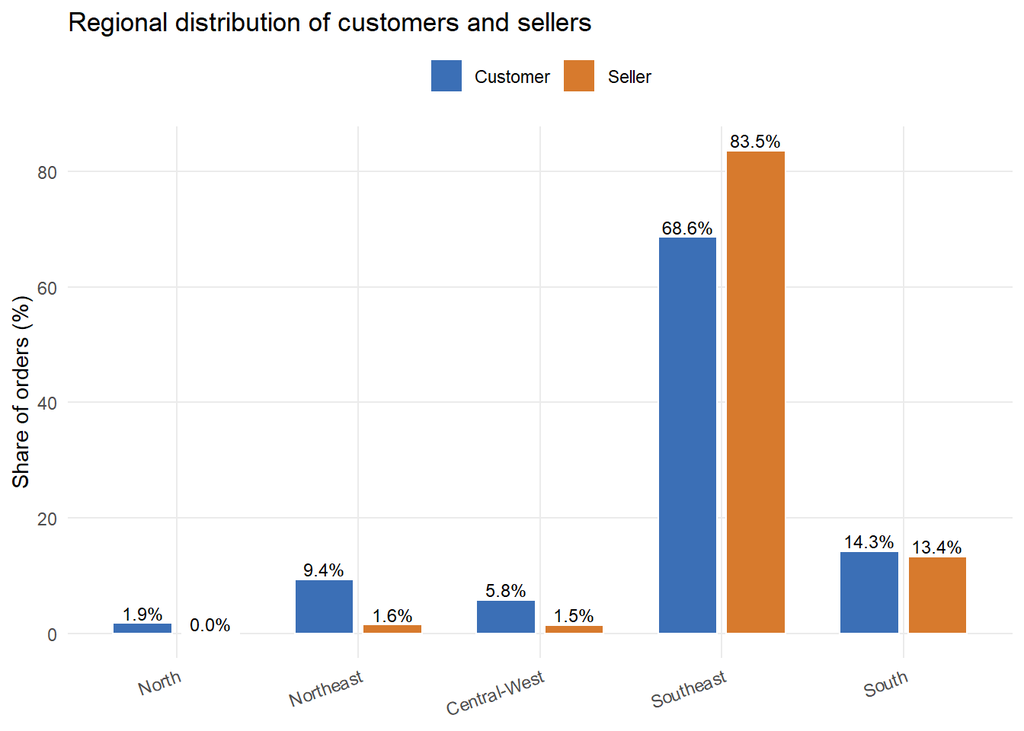

```r
ggplot(region_dist, aes(x = region, y = pct_orders, fill = side)) +
  geom_col(position = position_dodge(width = 0.75), width = 0.65) +
  geom_text(
    aes(label = sprintf("%.1f%%", pct_orders)),
    position = position_dodge(width = 0.75),
    vjust = -0.25,
    size = 3.1
  ) +
  scale_fill_manual(values = c("Customer" = "#3b6fb6", "Seller" = "#d77a2d")) +
  labs(
    title = "Regional distribution of customers and sellers",
    x = NULL,
    y = "Share of orders (%)",
    fill = NULL
  ) +
  theme_minimal(base_size = 11) +
  theme(
    panel.grid.minor = element_blank(),
    legend.position = "top",
    axis.text.x = element_text(angle = 20, hjust = 1)
  )
```

```r
# Population skewness
pop_hist <- orders_model %>%
  transmute(
    customer_state_pop_2017,
    seller_state_pop_2017,
    log_customer_pop = log1p(customer_state_pop_2017),
    log_seller_pop = log1p(seller_state_pop_2017),
    z_log_customer_pop = as.numeric(scale(log_customer_pop)),
    z_log_seller_pop = as.numeric(scale(log_seller_pop))
  ) %>%
  pivot_longer(everything(), names_to = "measure", values_to = "value") %>%
  mutate(
    variable = case_when(
      measure %in% c("customer_state_pop_2017", "log_customer_pop", "z_log_customer_pop") ~ "Customer state pop",
      measure %in% c("seller_state_pop_2017", "log_seller_pop", "z_log_seller_pop") ~ "Seller state pop",
      TRUE ~ "Other"
    ),
    stage = case_when(
      measure %in% c("customer_state_pop_2017", "seller_state_pop_2017") ~ "Raw",
      str_detect(measure, "^log_") ~ "log1p",
      str_detect(measure, "^z_") ~ "z-score(log1p)"
    ),
    stage = factor(stage, levels = c("Raw", "log1p", "z-score(log1p)")),
    panel = paste(variable, stage, sep = " — "),
    panel = factor(panel, levels = c(
      "Customer state pop — Raw", "Customer state pop — log1p", "Customer state pop — z-score(log1p)",
      "Seller state pop — Raw", "Seller state pop — log1p", "Seller state pop — z-score(log1p)"
    ))
  ) %>%
  filter(is.finite(value))
```

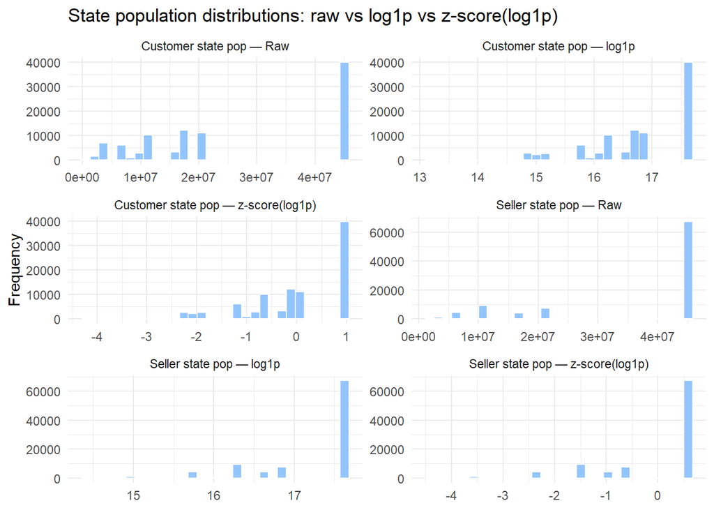

```r
ggplot(pop_hist, aes(x = value)) +
  geom_histogram(bins = 30, color = hist_border, fill = hist_fill) +
  facet_wrap(~ panel, scales = "free", ncol = 2) +
  theme_minimal() +
  labs(
    title = "State population distributions: raw vs log1p vs z-score(log1p)",
    x = NULL, y = "Frequency"
  )
```

```r
# Population density map + mean lead-time map by customer state
if (!exists("project_root_local") || is.null(project_root_local)) {
  project_root_local <- tryCatch(
    normalizePath(dirname(knitr::current_input(dir = TRUE)), winslash = "/", mustWork = FALSE),
    error = function(e) normalizePath(".", winslash = "/", mustWork = FALSE)
  )
}
if (!exists("tables_dir") || is.null(tables_dir)) {
  tables_dir <- file.path(project_root_local, "output", "tables")
  dir.create(tables_dir, recursive = TRUE, showWarnings = FALSE)
}
if (!exists("charts_dir") || is.null(charts_dir)) {
  charts_dir <- file.path(project_root_local, "output", "charts")
  dir.create(charts_dir, recursive = TRUE, showWarnings = FALSE)
}

state_area_km2 <- tibble::tribble(
  ~uf, ~area_km2,
  "AC", 164123.04, "AL", 27767.66, "AP", 142470.76, "AM", 1559167.89,
  "BA", 564760.43, "CE", 148894.44, "DF", 5760.78, "ES", 46095.58,
  "GO", 340111.38, "MA", 331937.45, "MT", 903206.99, "MS", 357145.53,
  "MG", 586521.12, "PA", 1245870.70, "PB", 56467.24, "PR", 199307.93,
  "PE", 98067.88, "PI", 251756.52, "RJ", 43780.17, "RN", 52796.79,
  "RS", 281730.22, "RO", 237590.86, "RR", 223644.53, "SC", 95730.92,
  "SP", 248219.63, "SE", 21910.35, "TO", 277620.91
)

geo_zip_lookup <- geolocation %>%
  transmute(
    zip_prefix = as.integer(geolocation_zip_code_prefix),
    customer_state = stringr::str_to_upper(stringr::str_trim(as.character(geolocation_state))),
    lon = as.numeric(geolocation_lng),
    lat = as.numeric(geolocation_lat)
  ) %>%
  filter(!is.na(zip_prefix), !is.na(customer_state), is.finite(lon), is.finite(lat)) %>%
  group_by(zip_prefix, customer_state) %>%
  summarise(
    lon = median(lon, na.rm = TRUE),
    lat = median(lat, na.rm = TRUE),
    .groups = "drop"
  )

customers_geo <- customers %>%
  transmute(
    customer_id,
    zip_prefix = as.integer(customer_zip_code_prefix),
    customer_state = stringr::str_to_upper(stringr::str_trim(as.character(customer_state))),
    customer_city = stringr::str_squish(as.character(customer_city))
  ) %>%
  left_join(geo_zip_lookup, by = c("zip_prefix", "customer_state"))

state_region_lookup <- state_region_pop %>%
  transmute(
    customer_state = uf,
    macro_region = region
  )

orders_geo_maps <- orders_clean_core %>%
  select(order_id, customer_id, lead_time_days_raw) %>%
  filter(!is.na(lead_time_days_raw), lead_time_days_raw >= 0, lead_time_days_raw <= 180) %>%
  left_join(customers_geo, by = "customer_id") %>%
  left_join(state_region_lookup, by = "customer_state") %>%
  filter(is.finite(lon), is.finite(lat), !is.na(macro_region))

city_metrics_maps <- orders_geo_maps %>%
  mutate(city_key = paste0(stringr::str_to_lower(customer_city), "|", customer_state)) %>%
  group_by(city_key, customer_city, customer_state, macro_region) %>%
  summarise(
    n_orders = n(),
    mean_actual_delivery_days = mean(lead_time_days_raw, na.rm = TRUE),
    lon = median(lon, na.rm = TRUE),
    lat = median(lat, na.rm = TRUE),
    .groups = "drop"
  ) %>%
  filter(is.finite(lon), is.finite(lat), !is.na(customer_city), customer_city != "")

region_labels <- city_metrics_maps %>%
  group_by(macro_region) %>%
  summarise(
    lon = weighted.mean(lon, w = pmax(n_orders, 1), na.rm = TRUE),
    lat = weighted.mean(lat, w = pmax(n_orders, 1), na.rm = TRUE),
    .groups = "drop"
  )

region_border <- city_metrics_maps %>%
  group_by(macro_region) %>%
  group_modify(
    ~ {
      if (nrow(.x) < 3) return(.x[0, c("lon", "lat")])
      hull_idx <- chull(.x$lon, .x$lat)
      hull <- .x[hull_idx, c("lon", "lat")]
      dplyr::bind_rows(hull, hull[1, c("lon", "lat")])
    }
  ) %>%
  ungroup()

top_city_labels <- city_metrics_maps %>%
  group_by(macro_region) %>%
  slice_max(order_by = n_orders, n = 1, with_ties = FALSE) %>%
  ungroup() %>%
  mutate(city_label = stringr::str_to_title(customer_city))

has_maps <- requireNamespace("maps", quietly = TRUE)
brazil_map_df <- if (has_maps) ggplot2::map_data("world", region = "Brazil") else NULL

map_theme_density <- theme_minimal(base_size = 10.5) +
  theme(
    panel.grid = element_blank(),
    axis.text = element_blank(),
    axis.title = element_blank(),
    axis.ticks = element_blank(),
    legend.position = "right",
    legend.direction = "vertical",
    legend.box = "vertical",
    legend.title = element_text(size = 9, face = "bold"),
    legend.text = element_text(size = 8.4),
    plot.title = element_text(face = "bold", size = 11.5),
    plot.subtitle = element_text(size = 9)
  )

map_heat_guide <- guide_colorbar(
  title.position = "top",
  title.hjust = 0.5,
  direction = "vertical",
  barwidth = grid::unit(8, "pt"),
  barheight = grid::unit(72, "pt"),
  ticks.colour = NA
)

p_order_density <- ggplot() +
  {if (has_maps) geom_polygon(
    data = brazil_map_df, aes(x = long, y = lat, group = group),
    fill = "grey95", color = "grey80", linewidth = 0.2
  )} +
  stat_bin_2d(
    data = orders_geo_maps,
    aes(x = lon, y = lat),
    bins = c(56, 56),
    alpha = 0.92
  ) +
  geom_path(
    data = region_border, aes(x = lon, y = lat, group = macro_region),
    inherit.aes = FALSE, color = "#4d4d4d", linewidth = 0.3, linetype = "22", alpha = 0.8
  ) +
  geom_text(
    data = region_labels, aes(x = lon, y = lat, label = macro_region),
    inherit.aes = FALSE, color = "#2B2B2B", fontface = "bold", size = 3.1, check_overlap = TRUE
  ) +
  geom_text(
    data = top_city_labels, aes(x = lon, y = lat, label = city_label),
    inherit.aes = FALSE, nudge_y = 0.4, color = "#1f1f1f", size = 2.4, check_overlap = TRUE
  ) +
  coord_quickmap(xlim = c(-75, -34), ylim = c(-34, 6), expand = FALSE) +
  scale_fill_gradientn(
    colors = c("#f7fbff", "#c6dbef", "#6baed6", "#2171b5", "#08306b"),
    trans = "log1p",
    labels = scales::label_number(accuracy = 1, scale_cut = scales::cut_short_scale()),
    name = "Customer\norders",
    na.value = "transparent",
    guide = map_heat_guide
  ) +
  map_theme_density +
  labs(
    title = "Customer Order Density Heatmap",
    subtitle = NULL
  )

p_mean_lead <- ggplot() +
  {if (has_maps) geom_polygon(
    data = brazil_map_df, aes(x = long, y = lat, group = group),
    fill = "grey95", color = "grey80", linewidth = 0.2
  )} +
  stat_summary_2d(
    data = orders_geo_maps,
    aes(x = lon, y = lat, z = lead_time_days_raw),
    fun = mean,
    bins = c(56, 56),
    alpha = 0.92
  ) +
  geom_path(
    data = region_border, aes(x = lon, y = lat, group = macro_region),
    inherit.aes = FALSE, color = "#4d4d4d", linewidth = 0.3, linetype = "22", alpha = 0.8
  ) +
  geom_text(
    data = region_labels, aes(x = lon, y = lat, label = macro_region),
    inherit.aes = FALSE, color = "#2B2B2B", fontface = "bold", size = 3.1, check_overlap = TRUE
  ) +
  geom_text(
    data = top_city_labels, aes(x = lon, y = lat, label = city_label),
    inherit.aes = FALSE, nudge_y = 0.4, color = "#1f1f1f", size = 2.4, check_overlap = TRUE
  ) +
  coord_quickmap(xlim = c(-75, -34), ylim = c(-34, 6), expand = FALSE) +
  scale_fill_gradientn(
    colors = c("#fff7ec", "#fee8c8", "#fdbb84", "#fc8d59", "#e34a33", "#b30000"),
    labels = scales::label_number(accuracy = 0.1),
    name = "Mean actual\ndelivery (days)",
    na.value = "transparent",
    guide = map_heat_guide
  ) +
  map_theme_density +
  labs(
    title = "Mean Delivery Lead Time Heatmap",
    subtitle = NULL
  )

readr::write_csv(
  city_metrics_maps %>%
    select(city_key, customer_city, customer_state, macro_region, lon, lat, n_orders, mean_actual_delivery_days),
  file.path(tables_dir, "city_order_delivery_metrics.csv")
)

plot_maps_combined <- gridExtra::arrangeGrob(
  p_order_density, p_mean_lead, ncol = 2,
  top = grid::textGrob(
    "Brazil: Customer Order Density and Mean Actual Delivery Time",
    gp = grid::gpar(fontsize = 11, fontface = "bold")
  )
)

ggplot2::ggsave(
  filename = file.path(charts_dir, "chart_order_delivery_density_maps.png"),
  plot = plot_maps_combined, width = 16, height = 7.8, dpi = 320, bg = "white"
)
```

```
## systemfonts and textshaping have been compiled with different versions of Freetype. Because of this, textshaping will not use the font cache provided by systemfonts
```

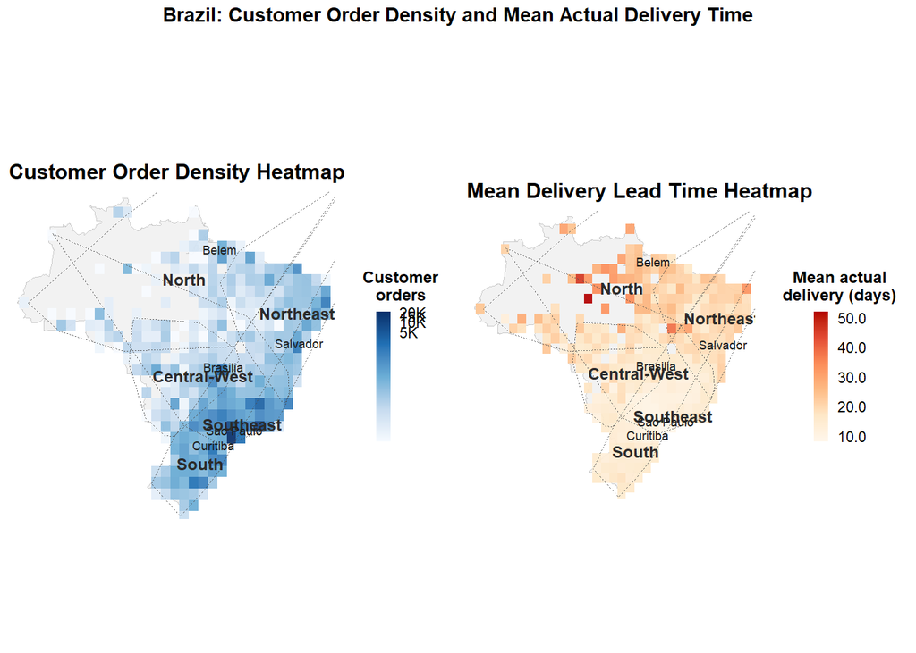

```r
grid::grid.newpage()
grid::grid.draw(plot_maps_combined)
```

```r
orders_model <- orders_model %>%
  mutate(
    log_customer_pop = log1p(customer_state_pop_2017),
    log_seller_pop = log1p(seller_state_pop_2017),
    z_log_customer_pop = as.numeric(scale(log_customer_pop)),
    z_log_seller_pop = as.numeric(scale(log_seller_pop))
  )
```

#### Enrich with product dimension

We constructed shipment‑level weight and volume by summing product weights and item volumes over items in each order. Histograms of weight and volume before and after log1p and z‑scaling show very heavy right tails on the raw scale and much more regular, roughly bell‑shaped distributions after transformation. We therefore use log1p‑transformed and z‑scored weight and volume as predictors, which reduces leverage from extremely bulky shipments and places them on a common scale.

```r
#Shipment dimensions

items_dim <- order_items %>%
  semi_join(orders_clean_core %>% select(order_id), by = "order_id") %>%
  left_join(
    products %>%
      select(product_id, product_weight_g, product_length_cm, product_height_cm, product_width_cm),
    by = "product_id"
  ) %>%
  mutate(item_volume_cm3 = product_length_cm * product_height_cm * product_width_cm)

order_dim_raw <- items_dim %>%
  group_by(order_id) %>%
  summarise(
    total_weight_g   = sum(product_weight_g, na.rm = TRUE),
    total_volume_cm3 = sum(item_volume_cm3,  na.rm = TRUE),
    .groups = "drop"

  )

orders_model <- orders_model %>%
  left_join(order_dim_raw, by = "order_id")
```

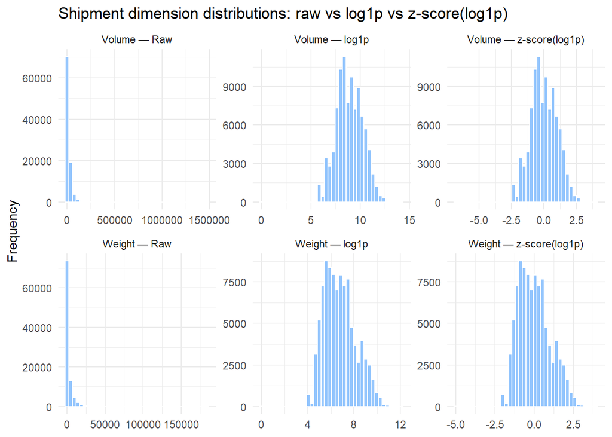

```r
# Check skewness
dim_hist <- orders_model %>%
  transmute(
    total_weight_g,
    total_volume_cm3,

    log_wgt = log1p(total_weight_g),
    log_vol = log1p(total_volume_cm3),

    z_log_wgt = as.numeric(scale(log_wgt)),
    z_log_vol = as.numeric(scale(log_vol))
  ) %>%
  pivot_longer(everything(), names_to = "measure", values_to = "value") %>%
  mutate(
    variable = if_else(str_detect(measure, "wgt|weight"), "Weight", "Volume"),
    stage = case_when(
      measure %in% c("total_weight_g", "total_volume_cm3") ~ "Raw",
      str_detect(measure, "^log_") ~ "log1p",
      str_detect(measure, "^z_")   ~ "z-score(log1p)"
    ),
    stage = factor(stage, levels = c("Raw", "log1p", "z-score(log1p)")),
    panel = paste(variable, stage, sep = " — "),
    panel = factor(panel, levels = c(
      "Volume — Raw", "Volume — log1p", "Volume — z-score(log1p)",
      "Weight — Raw", "Weight — log1p", "Weight — z-score(log1p)"
    ))
  ) %>%
  filter(is.finite(value))

ggplot(dim_hist, aes(x = value)) +
  geom_histogram(bins = 40, color = hist_border, fill = hist_fill) +
  facet_wrap(~ panel, scales = "free", ncol = 3) +
  theme_minimal() +
  labs(
    title = "Shipment dimension distributions: raw vs log1p vs z-score(log1p)",
    x = NULL, y = "Frequency"
  )
```

```r
orders_model <- orders_model %>%
  mutate(
    log_wgt = log1p(total_weight_g),
    log_vol = log1p(total_volume_cm3),
    z_log_wgt = as.numeric(scale(log_wgt)),
    z_log_vol = as.numeric(scale(log_vol))
  )
```

#### Enrich with product value

```r
#Order value / freight / items

order_money_raw <- order_items %>%
  semi_join(orders_clean_core %>% select(order_id), by = "order_id") %>%
  group_by(order_id) %>%
  summarise(
    n_items = n(),
    total_price   = sum(price, na.rm = TRUE),
    total_freight = sum(freight_value, na.rm = TRUE),
    total_value   = sum(price + freight_value, na.rm = TRUE),
    .groups = "drop"
  )

orders_model <- orders_model %>%
  left_join(order_money_raw, by = "order_id")
```

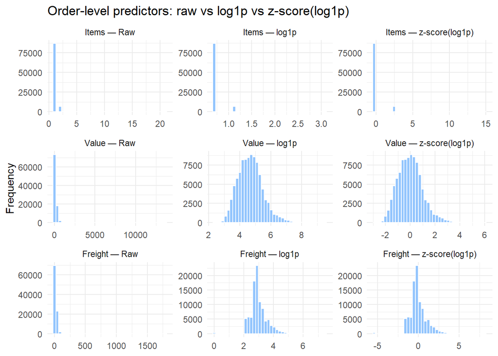

```r
#Skewness check
money_hist <- orders_model %>%
  transmute(
    n_items,
    total_value,
    total_freight,

    log_items   = log1p(n_items),
    log_value   = log1p(total_value),
    log_freight = log1p(total_freight),

    z_log_items   = as.numeric(scale(log_items)),
    z_log_value   = as.numeric(scale(log_value)),
    z_log_freight = as.numeric(scale(log_freight))
  ) %>%
  pivot_longer(everything(), names_to = "measure", values_to = "value") %>%
  mutate(
    variable = case_when(
      str_detect(measure, "items")   ~ "Items",
      str_detect(measure, "value")   ~ "Value",
      str_detect(measure, "freight") ~ "Freight"
    ),
    stage = case_when(
      measure %in% c("n_items", "total_value", "total_freight") ~ "Raw",
      str_detect(measure, "^log_") ~ "log1p",
      str_detect(measure, "^z_")   ~ "z-score(log1p)"
    ),
    stage = factor(stage, levels = c("Raw", "log1p", "z-score(log1p)")),
    panel = paste(variable, stage, sep = " — "),
    panel = factor(panel, levels = c(
      "Items — Raw", "Items — log1p", "Items — z-score(log1p)",
      "Value — Raw", "Value — log1p", "Value — z-score(log1p)",
      "Freight — Raw", "Freight — log1p", "Freight — z-score(log1p)"
    ))
  ) %>%
  filter(is.finite(value))

ggplot(money_hist, aes(x = value)) +
  geom_histogram(bins = 40, color = hist_border, fill = hist_fill) +
  facet_wrap(~ panel, scales = "free", ncol = 3) +
  theme_minimal() +
  labs(
    title = "Order-level predictors: raw vs log1p vs z-score(log1p)",
    x = NULL, y = "Frequency"
  )
```

```r
orders_model <- orders_model %>%
  mutate(
    log_items   = log1p(n_items),
    log_value   = log1p(total_value),
    log_freight = log1p(total_freight),

    z_log_items   = as.numeric(scale(log_items)),
    z_log_value   = as.numeric(scale(log_value)),
    z_log_freight = as.numeric(scale(log_freight))
  )
```

In our feature engineering, we first apply log1p to highly skewed positive predictors (e.g. order value, freight cost, shipment weight and volume) to reduce skewness and compress extreme values that would otherwise exert disproportionate influence on the fit. We then standardize these log‑transformed variables to z‑scores (mean 0, standard deviation 1), which places all continuous covariates on a common scale and improves the numerical conditioning of the mixed‑effects optimization.

### 3.1.2 Outcome Transformation

For the outcome, we compared the raw lead time with square‑root, log1p, and Winsorized variants using histograms. log1p(lead_time_days) yields a clearly more symmetric distribution than the raw or square‑root scales, while Winsorization mainly caps the most extreme values without resolving skewness. We therefore use log‑lead time as the main response, keeping trimming/Winsorization only for sensitivity checks

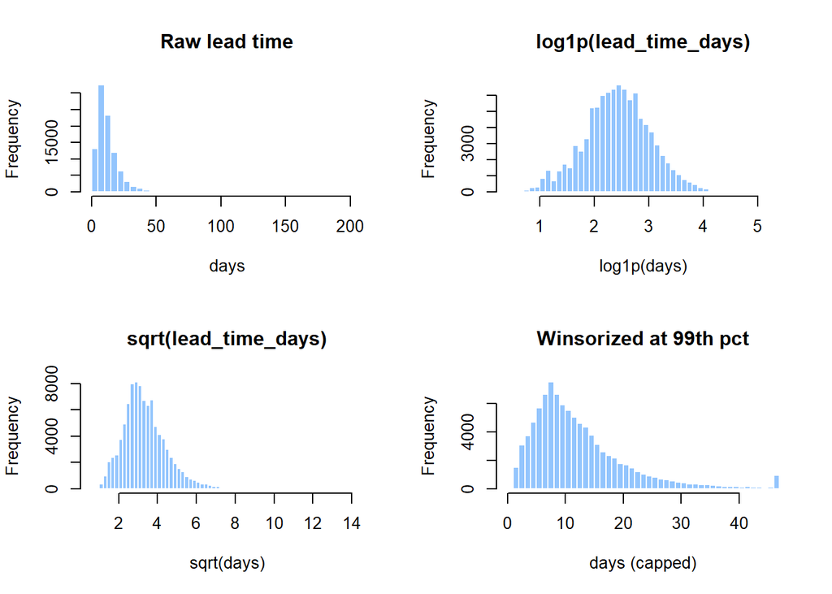

```r
orders_clean_core <- orders_clean_core %>%
  mutate(
    lead_time_days_raw = lead_time_days_raw,
    log_lead_time  = log1p(lead_time_days_raw),
    lead_sqrt   = sqrt(lead_time_days_raw),
    lead_wins99 = pmin(lead_time_days_raw, trim_cut_99)
  )

par(mfrow = c(2, 2))

hist(orders_clean_core$lead_time_days_raw,
     breaks = 50,
     main   = "Raw lead time",
     xlab   = "days",
     col    = hist_fill,
     border = hist_border)

hist(orders_clean_core$log_lead_time,
     breaks = 50,
     main   = "log1p(lead_time_days)",
     xlab   = "log1p(days)",
     col    = hist_fill,
     border = hist_border)

hist(orders_clean_core$lead_sqrt,
     breaks = 50,
     main   = "sqrt(lead_time_days)",
     xlab   = "sqrt(days)",
     col    = hist_fill,
     border = hist_border)

hist(orders_clean_core$lead_wins99,
     breaks = 50,
     main   = "Winsorized at 99th pct",
     xlab   = "days (capped)",
     col    = hist_fill,
     border = hist_border)
```

```r
par(mfrow = c(1, 1))
```

Visual inspection shows that log1p(lead_time_days) produces a markedly more symmetric distribution than the raw or square‑root scale, while Winsorization mainly truncates the very largest values without fully addressing skewness. We therefore adopt the log‑transformed outcome for the main models and reserve trimming/Winsorization for robustness checks.

```r
orders_clean_core <- orders_clean_core %>%
  mutate(
    lead_time_days_raw = if_else(lead_time_days_raw < 0, NA_real_, lead_time_days_raw),
    log_lead_time = log1p(lead_time_days_raw))


orders_model <- orders_model %>%

  select(-any_of(c("lead_time_days_raw", "log_lead_time", "lead_time_days"))) %>%
  left_join(
    orders_clean_core %>% select(order_id, lead_time_days_raw, log_lead_time),
    by = "order_id"
  )
```

## 3.2 Feature QA

```r
qa_counts <- tibble(
  n_core  = nrow(orders_clean_core),
  n_model = nrow(orders_model),
  n_distinct_order_id = n_distinct(orders_model$order_id),
  n_dup_order_id = nrow(orders_model) - n_distinct(orders_model$order_id)
)

qa_counts
```

| n_core | n_model | n_distinct_order_id | n_dup_order_id |
| --- | --- | --- | --- |
| 95194 | 95194 | 95194 | 0 |

```r
qa_missing <- orders_model %>%
  summarise(
    pct_na_customer_state = mean(is.na(customer_state)) * 100,
    pct_na_seller_state   = mean(is.na(seller_state)) * 100,

    pct_na_total_weight_g   = mean(is.na(total_weight_g)) * 100,
    pct_na_total_volume_cm3 = mean(is.na(total_volume_cm3)) * 100,
    pct_na_total_value      = mean(is.na(total_value)) * 100,
    pct_na_total_freight    = mean(is.na(total_freight)) * 100,
    pct_na_n_items          = mean(is.na(n_items)) * 100,

    pct_cat_other = mean(main_cat_pt_collapsed == "other", na.rm = TRUE) * 100,
    pct_theme_unmapped = mean(theme_name == "Other (unmapped)", na.rm = TRUE) * 100,

    pct_zero_weight = mean(total_weight_g == 0, na.rm = TRUE) * 100,
    pct_zero_volume = mean(total_volume_cm3 == 0, na.rm = TRUE) * 100
  )

qa_missing
```

| pct_na_customer_state | pct_na_seller_state | pct_na_total_weight_g | pct_na_total_volume_cm3 | pct_na_total_value | pct_na_total_freight | pct_na_n_items | pct_cat_other | pct_theme_unmapped | pct_zero_weight | pct_zero_volume |
| --- | --- | --- | --- | --- | --- | --- | --- | --- | --- | --- |
| 0 | 0 | 0 | 0 | 0 | 0 | 0 | 2.261697 | 1.407652 | 0.0231107 | 0.01680778 |

```r
qa_summary <- orders_model %>%
  summarise(
    lead_p01 = quantile(lead_time_days_raw, 0.01, na.rm = TRUE),
    lead_p50 = quantile(lead_time_days_raw, 0.50, na.rm = TRUE),
    lead_p99 = quantile(lead_time_days_raw, 0.99, na.rm = TRUE),

    wgt_p01 = quantile(total_weight_g, 0.01, na.rm = TRUE),
    wgt_p50 = quantile(total_weight_g, 0.50, na.rm = TRUE),
    wgt_p99 = quantile(total_weight_g, 0.99, na.rm = TRUE),

    vol_p01 = quantile(total_volume_cm3, 0.01, na.rm = TRUE),
    vol_p50 = quantile(total_volume_cm3, 0.50, na.rm = TRUE),
    vol_p99 = quantile(total_volume_cm3, 0.99, na.rm = TRUE),

    val_p01 = quantile(total_value, 0.01, na.rm = TRUE),
    val_p50 = quantile(total_value, 0.50, na.rm = TRUE),
    val_p99 = quantile(total_value, 0.99, na.rm = TRUE)
  )

qa_summary
```

| lead_p01 | lead_p50 | lead_p99 | wgt_p01 | wgt_p50 | wgt_p99 | vol_p01 | vol_p50 | vol_p99 | val_p01 | val_p50 | val_p99 |
| --- | --- | --- | --- | --- | --- | --- | --- | --- | --- | --- | --- |
| 1.828273 | 10.25179 | 46.13911 | 90 | 741 | 22350 | 352 | 7128 | 134292 | 22.38 | 104.16 | 1047.365 |

```r
library(car)
lm_tmp <- lm(log_lead_time ~ log_wgt + log_vol + log_value + log_freight + log_items +  log_customer_pop + log_seller_pop,
             data = orders_model)
car::vif(lm_tmp)
```

```
##          log_wgt          log_vol        log_value      log_freight
##         3.080682         2.563891         1.704067         2.344288
##        log_items log_customer_pop   log_seller_pop
##         1.251906         1.268755         1.080982
```

## 3.3 Missingness handling

Product weight and volume are occasionally missing or recorded as zero, but this affects only a small share of orders. We treat zero weight as invalid, create indicators for missing/zero dimensions, and impute log-weight and log-volume using category-specific medians (with a global median fallback), then standardize these imputed values. In parallel, we keep a stricter modeling subset that drops rows with missing `log_wgt`/`log_vol` and unmapped themes.

```r
# Recompute dimensions properly (all-NA -> NA, not 0)
items_dim <- order_items %>%
  semi_join(orders_clean_core %>% select(order_id), by = "order_id") %>%
  left_join(
    products %>%
      select(product_id, product_weight_g, product_length_cm, product_height_cm, product_width_cm),
    by = "product_id"
  ) %>%
  mutate(item_volume_cm3 = product_length_cm * product_height_cm * product_width_cm)

order_dim_raw <- items_dim %>%
  group_by(order_id) %>%
  summarise(
    total_weight_g = if (all(is.na(product_weight_g))) NA_real_ else sum(product_weight_g, na.rm = TRUE),
    total_volume_cm3 = if (all(is.na(item_volume_cm3))) NA_real_ else sum(item_volume_cm3, na.rm = TRUE),

    any_missing_weight = any(is.na(product_weight_g)),
    any_missing_volume = any(is.na(item_volume_cm3)),
    any_zero_weight    = any(!is.na(product_weight_g) & product_weight_g == 0),
    .groups = "drop"
  )

orders_model <- orders_model %>%
  select(-any_of(c("total_weight_g","total_volume_cm3","any_missing_weight","any_missing_volume","any_zero_weight",
                   "log_wgt","log_vol","z_log_wgt","z_log_vol"))) %>%
  left_join(order_dim_raw, by = "order_id")
```

```r
orders_model <- orders_model %>%
  mutate(
    miss_wgt = is.na(total_weight_g) | total_weight_g == 0,   # treat 0 as invalid for weight
    miss_vol = is.na(total_volume_cm3)                        # volume: usually missing not 0
  ) %>%
  mutate(
    log_wgt = log1p(total_weight_g),
    log_vol = log1p(total_volume_cm3)
  )

# category medians on log-scale (using observed only)
med_by_cat <- orders_model %>%
  group_by(main_cat_pt_collapsed) %>%
  summarise(
    med_log_wgt = median(log_wgt[!is.na(log_wgt) & is.finite(log_wgt)], na.rm = TRUE),
    med_log_vol = median(log_vol[!is.na(log_vol) & is.finite(log_vol)], na.rm = TRUE),
    .groups = "drop"
  )

# global fallback
global_meds <- orders_model %>%
  summarise(
    g_med_log_wgt = median(log_wgt, na.rm = TRUE),
    g_med_log_vol = median(log_vol, na.rm = TRUE)
  )

orders_model <- orders_model %>%
  left_join(med_by_cat, by = "main_cat_pt_collapsed") %>%
  mutate(
    imp_wgt = miss_wgt,
    imp_vol = miss_vol,

    log_wgt_imp = if_else(miss_wgt, coalesce(med_log_wgt, global_meds$g_med_log_wgt), log_wgt),
    log_vol_imp = if_else(miss_vol, coalesce(med_log_vol, global_meds$g_med_log_vol), log_vol)
  ) %>%
  # z-scores on the log1p scale (use mean/sd from observed log values, then apply)
  mutate(
    mu_log_wgt = mean(log_wgt, na.rm = TRUE),
    sd_log_wgt = sd(log_wgt, na.rm = TRUE),
    mu_log_vol = mean(log_vol, na.rm = TRUE),
    sd_log_vol = sd(log_vol, na.rm = TRUE),

    z_log_wgt = (log_wgt_imp - mu_log_wgt) / sd_log_wgt,
    z_log_vol = (log_vol_imp - mu_log_vol) / sd_log_vol
  ) %>%
  select(-med_log_wgt, -med_log_vol, -mu_log_wgt, -sd_log_wgt, -mu_log_vol, -sd_log_vol)
```

```r
# pct of imputed values
orders_model %>%
  summarise(
    pct_imp_wgt = mean(imp_wgt) * 100,
    pct_imp_vol = mean(imp_vol) * 100
  )
```

| pct_imp_wgt | pct_imp_vol |
| --- | --- |
| 0.0231107 | 0.01680778 |

```r
orders_model_strict <- orders_model %>%
  mutate(
    log_wgt = log1p(total_weight_g),
    log_vol = log1p(total_volume_cm3)
  ) %>%
  filter(
    !is.na(log_wgt),
    !is.na(log_vol),
    theme_name != "Other (unmapped)"
  ) %>%
  mutate(
    z_log_wgt = as.numeric(scale(log_wgt)),
    z_log_vol = as.numeric(scale(log_vol))
  )

tibble(
  n_main   = nrow(orders_model),
  n_strict = nrow(orders_model_strict),
  pct_kept = 100 * nrow(orders_model_strict) / nrow(orders_model)
)
```

| n_main | n_strict | pct_kept |
| --- | --- | --- |
| 95194 | 93853 | 98.5913 |

The strict complete-case dataset drops rows with missing weight/volume logs and unmapped themes; the retained share is reported in the table above.

```r
orders_eda <- orders_model %>%
  transmute(
    # IDs / grouping
    order_id,
    seller_id,
    customer_state,
    seller_state,
    customer_region,
    seller_region,
    is_same_state,
    is_same_region,
    customer_state_pop_2017,
    seller_state_pop_2017,
    log_customer_pop,
    log_seller_pop,
    z_log_customer_pop,
    z_log_seller_pop,

    # time controls
    purchase_ts,
    purchase_year,
    purchase_wday,
    season,

    # outcome
    lead_time_days_raw,
    delay_vs_estimated_days,
    log_lead_time,

    # predictors with log*
    log_items,
    log_value,
    log_freight,
    log_wgt,
    log_vol,
    # predictors with z-score
    z_log_items,
    z_log_value,
    z_log_freight,
    z_log_wgt,
    z_log_vol,
    # category

    is_hedonic,
    is_experience,
    theme_name,



    # for eda
    n_items,
    total_value,
    total_freight,
    total_weight_g,
    total_volume_cm3

  )


orders_eda %>%
  summarise(
    n = n(),
    n_orders = n_distinct(order_id),
    n_sellers = n_distinct(seller_id),
    pct_na_y = mean(is.na(log_lead_time)) * 100
  )
```

| n | n_orders | n_sellers | pct_na_y |
| --- | --- | --- | --- |
| 95194 | 95194 | 2948 | 0 |

```r
# Theme names available in modeling table
orders_eda %>%
  count(theme_name, name = "n_orders") %>%
  mutate(pct_orders = 100 * n_orders / sum(n_orders))
```

| theme_name | n_orders | pct_orders |
| --- | --- | --- |
| Experience + Hedonic | 27977 | 29.389457 |
| Experience + Utilitarian | 27280 | 28.657268 |
| Other (unmapped) | 1340 | 1.407652 |
| Search + Hedonic | 10062 | 10.569994 |
| Search + Utilitarian | 28535 | 29.975629 |

```r
orders_eda_strict <- orders_model_strict %>%
  transmute(
    # IDs / grouping
    order_id,
    seller_id,
    customer_state,
    seller_state,
    customer_region,
    seller_region,
    is_same_state,
    is_same_region,
    customer_state_pop_2017,
    seller_state_pop_2017,
    log_customer_pop,
    log_seller_pop,
    z_log_customer_pop,
    z_log_seller_pop,

    # time controls
    purchase_ts,
    purchase_year,
    purchase_wday,
    season,

    # outcome
    lead_time_days_raw,
    delay_vs_estimated_days,
    log_lead_time,

    # predictors with log*
    log_items,
    log_value,
    log_freight,
    log_wgt,
    log_vol,
    # predictors with z-score
    z_log_items,
    z_log_value,
    z_log_freight,
    z_log_wgt,
    z_log_vol,
    # category

    is_hedonic,
    is_experience,
    theme_name,



    # for eda
    n_items,
    total_value,
    total_freight,
    total_weight_g,
    total_volume_cm3

  )


orders_eda %>%
  summarise(
    n = n(),
    n_orders = n_distinct(order_id),
    n_sellers = n_distinct(seller_id),
    pct_na_y = mean(is.na(log_lead_time)) * 100
  )
```

| n | n_orders | n_sellers | pct_na_y |
| --- | --- | --- | --- |
| 95194 | 95194 | 2948 | 0 |

```r
# Theme names available in modeling table
orders_eda_strict %>%
  count(theme_name, name = "n_orders") %>%
  mutate(pct_orders = 100 * n_orders / sum(n_orders))
```

| theme_name | n_orders | pct_orders |
| --- | --- | --- |
| Experience + Hedonic | 27977 | 29.80938 |
| Experience + Utilitarian | 27279 | 29.06567 |
| Search + Hedonic | 10062 | 10.72102 |
| Search + Utilitarian | 28535 | 30.40393 |

```r
# Lock analysis datasets for reproducibility

dir.create("output", showWarnings = FALSE, recursive = TRUE)

saveRDS(orders_eda, "output/orders_eda.rds")
saveRDS(orders_eda_strict, "output/orders_eda_strict.rds")

readr::write_csv(orders_eda, "output/orders_eda.csv", na = "")
readr::write_csv(orders_eda_strict, "output/orders_eda_strict.csv", na = "")

tibble(
  dataset = c("orders_eda", "orders_eda_strict"),
  n_rows = c(nrow(orders_eda), nrow(orders_eda_strict)),
  n_cols = c(ncol(orders_eda), ncol(orders_eda_strict)),
  rds_path = c("output/orders_eda.rds", "output/orders_eda_strict.rds"),
  csv_path = c("output/orders_eda.csv", "output/orders_eda_strict.csv")
)
```

| dataset | n_rows | n_cols | rds_path | csv_path |
| --- | --- | --- | --- | --- |
| orders_eda | 95194 | 39 | output/orders_eda.rds | output/orders_eda.csv |
| orders_eda_strict | 93853 | 39 | output/orders_eda_strict.rds | output/orders_eda_strict.csv |

# 4. Exploratory Data Analysis

This section focuses on interpretable relationships between delivery lead time and predictors. Dataset-construction checks (missingness, transformations, uniqueness, and VIF diagnostics) are reported in Section 3, and the locked `orders_eda` table is used here for outcome-oriented EDA.

```r
# load locked data
# Optional shortcut for interactive work:
# set TRUE to load saved analysis tables from output/ and continue from Section 4.
use_locked_data <- TRUE

if (use_locked_data) {
  lock_orders <- "output/orders_eda.rds"
  lock_strict <- "output/orders_eda_strict.rds"

  stopifnot(file.exists(lock_orders), file.exists(lock_strict))

  orders_eda <- readRDS(lock_orders)
  orders_eda_strict <- readRDS(lock_strict)

  message("Loaded locked data: orders_eda + orders_eda_strict from output/.")
}
```

```r
orders_eda %>%
  summarise(
    n_orders   = n(),
    n_sellers  = n_distinct(seller_id),
    n_states   = n_distinct(customer_state)
  )
```

| n_orders | n_sellers | n_states |
| --- | --- | --- |
| 95194 | 2948 | 27 |

## 4.1 Delivery Lead Time vs predictors

[figure not shown]

```r
# Delivery lead time vs customer region
orders_eda %>%
  filter(!is.na(customer_region), !is.na(lead_time_days_raw)) %>%
  mutate(customer_region = factor(customer_region,
                                  levels = c("North", "Northeast", "Central-West", "Southeast", "South"))) %>%
  ggplot(aes(x = customer_region, y = log_lead_time)) +
  geom_boxplot(outlier.alpha = 0.15) +
  labs(title = "Delivery lead time by customer region",
       x = "Customer region", y = "Lead time (days)") +
  theme(axis.text.x = element_text(angle = 20, hjust = 1))
```

```r
orders_eda %>%
  filter(!is.na(customer_region)) %>%
  group_by(customer_region) %>%
  summarise(
    n = n(),
    mean_delivery_days = mean(lead_time_days_raw, na.rm = TRUE),
    median_delivery_days = median(lead_time_days_raw, na.rm = TRUE),
    .groups = "drop"
  ) %>%
  arrange(customer_region)
```

| customer_region | n | mean_delivery_days | median_delivery_days |
| --- | --- | --- | --- |
| Central-West | 5547 | 15.07444 | 13.340683 |
| North | 1778 | 22.62928 | 20.167818 |
| Northeast | 8963 | 20.05293 | 17.343762 |
| South | 13625 | 14.08127 | 12.155822 |
| Southeast | 65281 | 10.79013 | 8.752141 |

Breaking down lead times by customer and seller region reveals clear geography patterns: the Southeast region (which includes SP, RJ, MG, ES) exhibits the lowest median delivery times (customer region: 8.75 days; seller region: 10.1 days), reflecting high seller density and short‑distance shipments. In contrast, the North and Northeast regions show substantially longer medians (North customer: 20.2 days; Northeast customer: 17.3 days), consistent with sparser logistics infrastructure and longer shipping distances from the predominantly Southeast‑based seller pool. Seller region patterns are less pronounced because 79,492 of 95,194 orders originate from Southeast sellers. These regional differences underscore the importance of including state‑level random effects and same‑region fixed effects to capture geography‑driven variation

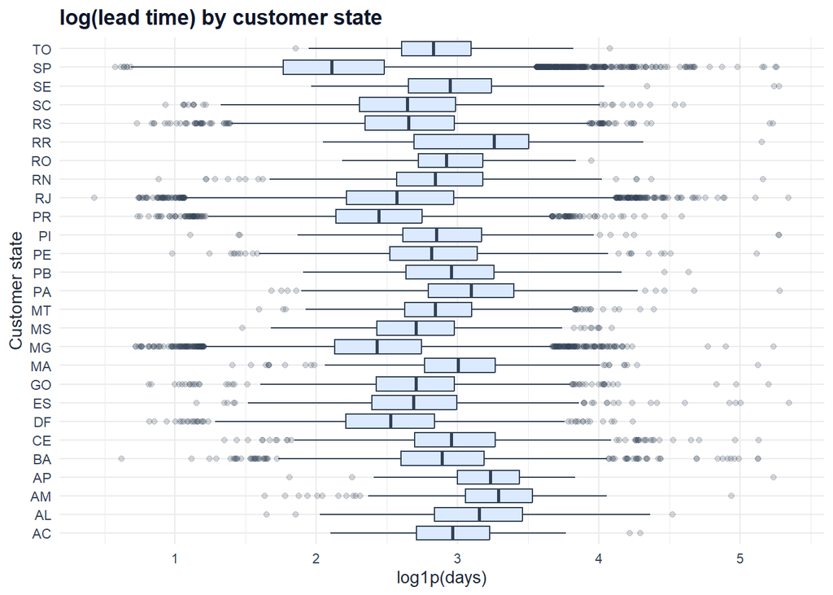

```r
# Heterogeneity by state
ggplot(orders_eda, aes(x = customer_state, y = log_lead_time)) +
  geom_boxplot(outlier.alpha = 0.2) +
  coord_flip() +
  labs(
    title = "log(lead time) by customer state",
    x = "Customer state", y = "log1p(days)"
  )
```

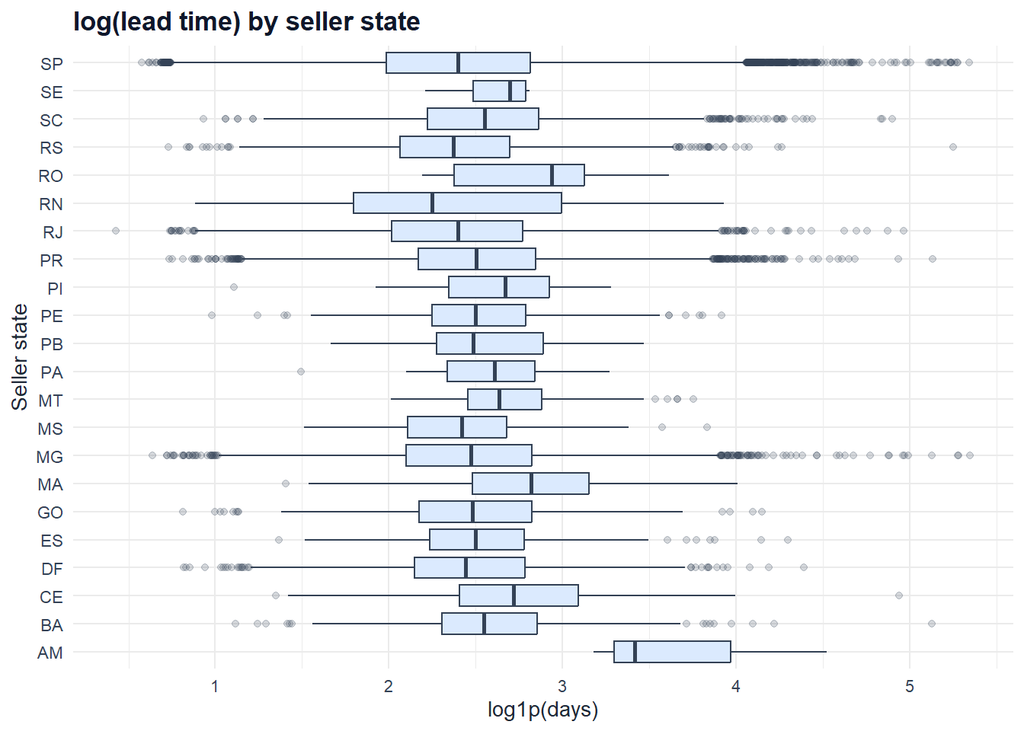

```r
ggplot(orders_eda, aes(x = seller_state, y = log_lead_time)) +
  geom_boxplot(outlier.alpha = 0.2) +
  coord_flip() +
  labs(
    title = "log(lead time) by seller state",
    x = "Seller state", y = "log1p(days)"
  )
```

The boxplots by customer state and seller state reveal substantial between‑state heterogeneity in median log‑delivery times: for example, São Paulo (SP) customers experience a median of about 7.2 raw days while customers in more remote states like Amazonas (AM) or Roraima (RR) see medians above 20 days. Similarly, sellers located in certain states systematically ship faster than others. The state‑level summary table confirms that SP—the most populated state—handles the largest volume (n = 39,927 orders) with the shortest median (7.22 days), whereas smaller or more distant states exhibit higher medians and 90th percentiles. This pronounced clustering by state and seller motivates the use of crossed random intercepts for customer_state and seller_id in our mixed‑effects models.

```r
state_summ <- orders_eda %>%
  group_by(customer_state) %>%
  summarise(
    n = n(),
    med_delivery_days = median(lead_time_days_raw, na.rm = TRUE),
    p90_delivery_days = quantile(lead_time_days_raw, .90, na.rm = TRUE),
    .groups = "drop"
  ) %>%
  arrange(desc(n))

state_summ
```

| customer_state | n | med_delivery_days | p90_delivery_days |
| --- | --- | --- | --- |
| SP | 39927 | 7.223229 | 15.82870 |
| RJ | 12194 | 12.084537 | 29.16228 |
| MG | 11192 | 10.323611 | 20.27040 |
| RS | 5258 | 13.219890 | 25.97701 |
| PR | 4861 | 10.480972 | 20.16959 |
| SC | 3506 | 13.054688 | 25.84878 |
| BA | 3220 | 16.952060 | 31.89687 |
| DF | 2056 | 11.510515 | 21.80197 |
| ES | 1968 | 13.704288 | 25.42020 |
| GO | 1927 | 13.978345 | 24.98169 |

[output cut: 17 more lines]

```r
# Routing: same vs cross state/region
eda_same_state <- orders_eda %>%
  count(is_same_state, name = "n") %>%
  left_join(
    orders_eda %>%
      group_by(is_same_state) %>%
      summarise(
        mean_delivery_days = mean(lead_time_days_raw, na.rm = TRUE),
        med_delivery_days  = median(lead_time_days_raw, na.rm = TRUE),
        .groups = "drop"
      ),
    by = "is_same_state"
  )

eda_same_state
```

| is_same_state | n | mean_delivery_days | med_delivery_days |
| --- | --- | --- | --- |
| FALSE | 60961 | 15.208279 | 12.841123 |
| TRUE | 34233 | 7.966679 | 6.589838 |

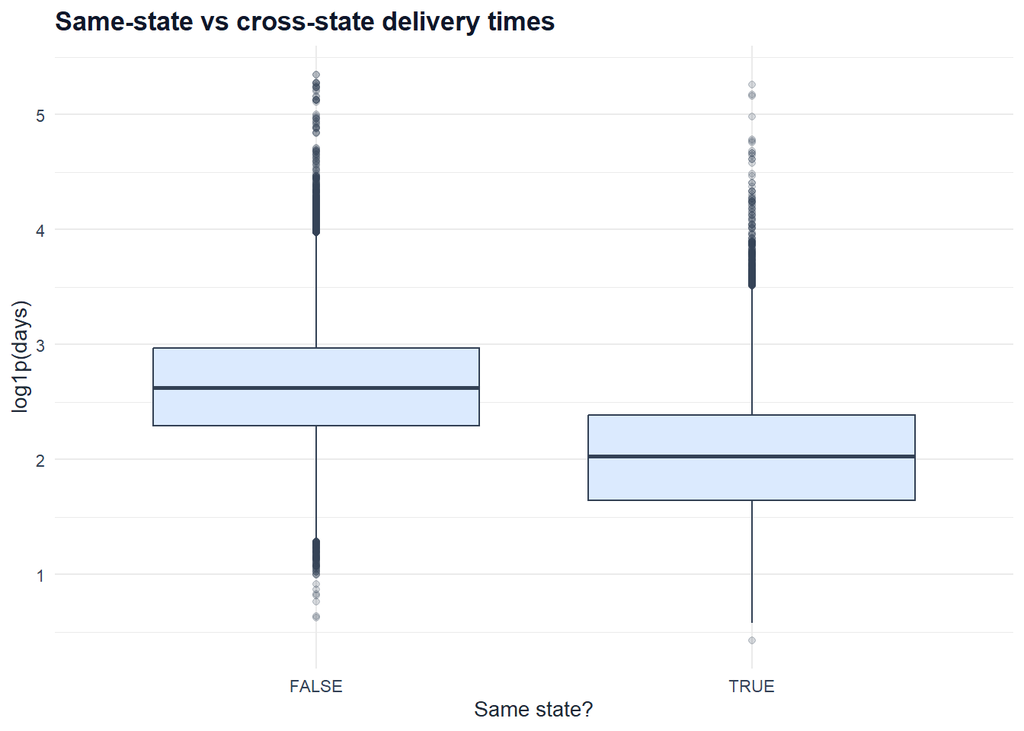

```r
ggplot(orders_eda, aes(x = is_same_state, y = log_lead_time)) +
  geom_boxplot(outlier.alpha = 0.2) +
  labs(
    title = "Same-state vs cross-state delivery times",
    x = "Same state?", y = "log1p(days)"
  )
```

```r
#Shipment size and value predictors

# simple correlations with outcome
ship_vars <- c("z_log_wgt","z_log_vol","z_log_value","z_log_freight","z_log_items")
cor_outcome <- orders_eda %>%
  select(log_lead_time, all_of(ship_vars)) %>%
  cor(use = "pairwise.complete.obs") %>%
  as.data.frame() %>%
  rownames_to_column("var")

cor_outcome
```

| var | log_lead_time | z_log_wgt | z_log_vol | z_log_value | z_log_freight | z_log_items |
| --- | --- | --- | --- | --- | --- | --- |
| log_lead_time | 1.000000000 | 0.09952614 | 0.08192888 | 0.1500962 | 0.3402238 | -0.007837977 |
| z_log_wgt | 0.099526145 | 1.00000000 | 0.77680283 | 0.5530153 | 0.5207915 | 0.185072334 |
| z_log_vol | 0.081928876 | 0.77680283 | 1.00000000 | 0.4441062 | 0.4552371 | 0.202546527 |
| z_log_value | 0.150096196 | 0.55301529 | 0.44410616 | 1.0000000 | 0.5610783 | 0.215284362 |
| z_log_freight | 0.340223750 | 0.52079147 | 0.45523706 | 0.5610783 | 1.0000000 | 0.395436163 |
| z_log_items | -0.007837977 | 0.18507233 | 0.20254653 | 0.2152844 | 0.3954362 | 1.000000000 |

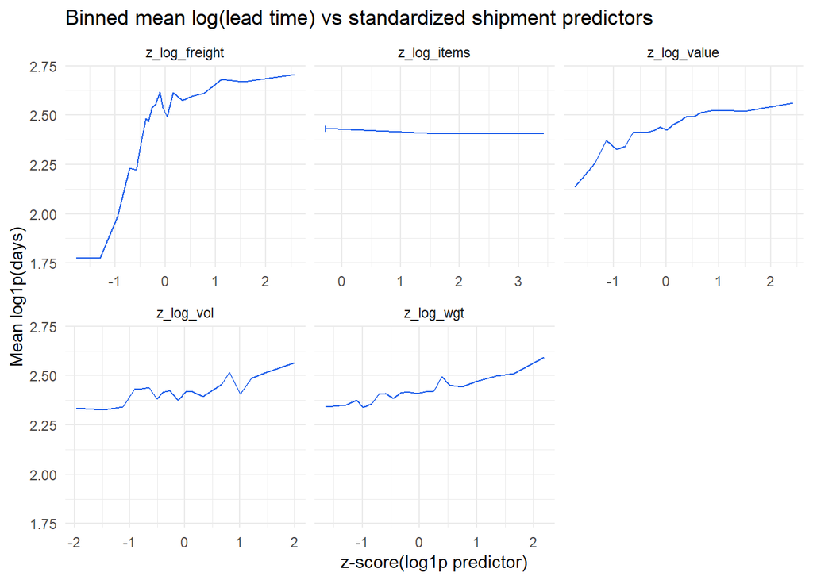

```r
#  log_lead_time vs each standardized predictor
bin_means <- function(data, x, y = "log_lead_time", nbins = 20) {
  x_sym <- rlang::sym(x); y_sym <- rlang::sym(y)
  data %>%
    filter(is.finite(!!x_sym), is.finite(!!y_sym)) %>%
    mutate(bin = ntile(!!x_sym, nbins)) %>%
    group_by(bin) %>%
    summarise(
      x_mid = mean(!!x_sym, na.rm = TRUE),
      y_mean = mean(!!y_sym, na.rm = TRUE),
      .groups = "drop"
    ) %>%
    mutate(var = x)
}

binned_list <- map(ship_vars, ~bin_means(orders_eda, .x))
binned_df   <- bind_rows(binned_list)

ggplot(binned_df, aes(x = x_mid, y = y_mean)) +
  geom_line() +
  facet_wrap(~ var, scales = "free_x") +
  labs(
    title = "Binned mean log(lead time) vs standardized shipment predictors",
    x = "z-score(log1p predictor)", y = "Mean log1p(days)"
  ) +
  theme_minimal()
```

```r
#Delivery lead time vs season -------------------------------------------------

orders_eda %>%
  count(season, name = "n") %>%
  left_join(
    orders_eda %>%
      group_by(season) %>%
      summarise(
        mean_delivery_days = mean(lead_time_days_raw, na.rm = TRUE),
        med_delivery_days  = median(lead_time_days_raw, na.rm = TRUE),
        .groups = "drop"
      ),
    by = "season"
  )
```

| season | n | mean_delivery_days | med_delivery_days |
| --- | --- | --- | --- |
| DJF | 21314 | 15.209318 | 12.853374 |
| MAM | 28562 | 13.063717 | 10.641713 |
| JJA | 29340 | 9.765179 | 8.230995 |
| SON | 15978 | 13.520314 | 11.336950 |

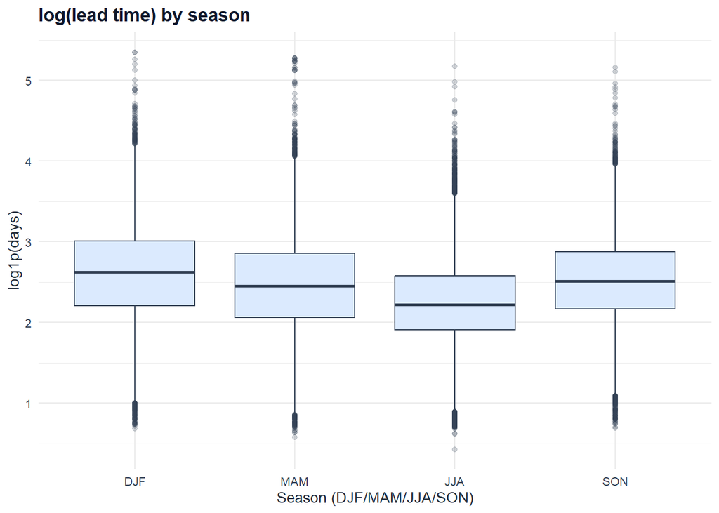

```r
ggplot(orders_eda, aes(x = season, y = log_lead_time)) +
  geom_boxplot(outlier.alpha = 0.2) +
  labs(
    title = "log(lead time) by season",
    x = "Season (DJF/MAM/JJA/SON)", y = "log1p(days)"
  )
```

Seasonal variation is moderate: the boxplot and summary table show that median lead times are highest in the December–January–February (DJF) period (12.9 days raw, mean 15.2) and lowest in June–July–August (JJA) (median 8.23 days, mean 9.77), consistent with end‑of‑year holiday demand spikes and mid‑year low‑demand periods. However, distributions overlap substantially and seasonal ranges are narrower than state‑level differences, suggesting that a four‑level season factor is an adequate coarse time control rather than a primary driver of variation

[figure not shown]

```r
## Delivery lead time vs product themes
orders_eda %>%
  filter(!is.na(theme_name), theme_name != "Other (unmapped)", !is.na(lead_time_days_raw)) %>%
  mutate(theme_name = fct_reorder(theme_name, log_lead_time, median, na.rm = TRUE)) %>%
  ggplot(aes(x = theme_name, y = log_lead_time)) +
  geom_boxplot(outlier.alpha = 0.15) +
  coord_flip() +
  labs(title = "Delivery lead time by product theme",
       x = "Product theme", y = "Lead time (days)")
```

```r
orders_eda %>%
  filter(!is.na(theme_name), theme_name != "Other (unmapped)") %>%
  group_by(theme_name) %>%
  summarise(
    n = n(),
    mean = mean(lead_time_days_raw, na.rm = TRUE),
    median = median(lead_time_days_raw, na.rm = TRUE),
    .groups = "drop"
  ) %>%
  arrange(desc(n))
```

| theme_name | n | mean | median |
| --- | --- | --- | --- |
| Search + Utilitarian | 28535 | 13.13272 | 10.910347 |
| Experience + Hedonic | 27977 | 12.22776 | 9.945961 |
| Experience + Utilitarian | 27280 | 12.51715 | 10.175336 |
| Search + Hedonic | 10062 | 12.35790 | 10.113530 |

Grouping orders by product theme (combinations of search/experience and utilitarian/hedonic attributes) reveals modest but interpretable differences: Experience + Hedonic products (e.g. fashion, beauty) have slightly shorter median lead times (9.95 days) than Search + Utilitarian products (10.9 days), possibly because hedonic goods are lighter or prioritized in fulfillment. However, the theme distributions overlap substantially—means range only from 12.2 to 13.1 days across the four main themes—and sample sizes are large and balanced (10,062 to 28,535 orders per theme). Because theme_name collapses many sparse product categories into a small number of interpretable cells without inflating the parameter count, it provides a convenient way to control for product‑mix effects in the regression models.

## 4.2 Correlation

The correlation matrix among log shipment predictors shows moderate pairwise associations: log_wgt and log_vol correlate at 0.78 (expected, since heavier items tend to be bulkier), log_value and log_freight at 0.56 (both reflect shipment cost), and log_items correlates weakly with the size/value predictors (0.18–0.40). Despite these moderate correlations, no pair exceeds 0.80, and variance inflation factors (computed in Section 3) remain below 3.0, indicating that weight, volume, value, freight, and item count capture related but non‑redundant aspects of shipment characteristics and can be entered jointly as linear covariates without severe multicollinearity.

The table of correlations between log_lead_time and key predictors highlights is_same_state as the dominant univariate predictor (r = −0.493), followed by log_freight (r = 0.340) and log_value (r = 0.150). Weight and volume show weak positive correlations with lead time (0.099 and 0.082), while log_items is nearly uncorrelated (−0.008). The correlation heatmap visually confirms these patterns: is_same_state clusters in a distinct block from the shipment‑size predictors, and freight and value form a moderately correlated subgroup. Together, these correlations motivate the progressive strategy in Section 5: isolate routing effects (M1), add shipment predictors (M2), add season/theme controls (M3), then test cluster-conditioned heterogeneity (M4).

```r
pred_cor <- orders_eda %>%
  select(log_wgt, log_vol, log_value, log_freight, log_items) %>%
  cor(use = "pairwise.complete.obs")

pred_cor
```

```
##               log_wgt   log_vol log_value log_freight log_items
## log_wgt     1.0000000 0.7758470 0.5524174   0.5201779 0.1847498
## log_vol     0.7758470 1.0000000 0.4441046   0.4552377 0.2025663
## log_value   0.5524174 0.4441046 1.0000000   0.5610783 0.2152844
## log_freight 0.5201779 0.4552377 0.5610783   1.0000000 0.3954362
## log_items   0.1847498 0.2025663 0.2152844   0.3954362 1.0000000
```

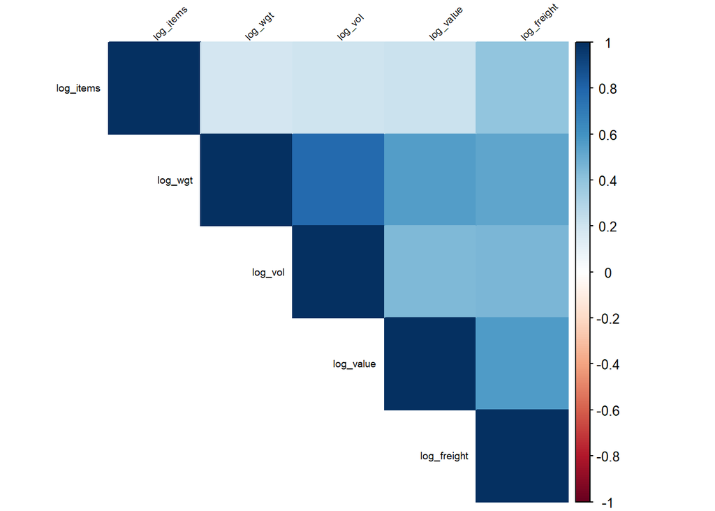

```r
pred_cor_mat <- pred_cor

corrplot(
  pred_cor_mat,
  method = "color", type = "upper", order = "hclust",
  tl.col = "black", tl.srt = 45, tl.cex = 0.6, number.cex = 0.6
)
```

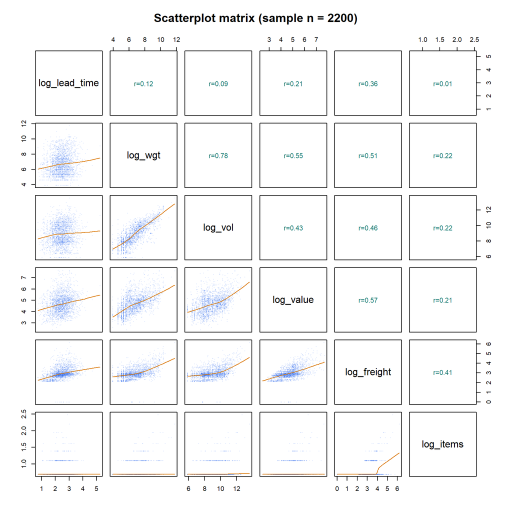

```r
set.seed(2026)

spm_vars <- c("log_lead_time", "log_wgt", "log_vol", "log_value", "log_freight", "log_items")
spm_df <- orders_eda %>%
  select(all_of(spm_vars)) %>%
  drop_na()

n_spm <- min(2200L, nrow(spm_df))
idx_spm <- sample.int(nrow(spm_df), size = n_spm, replace = FALSE)
spm_sample <- spm_df[idx_spm, , drop = FALSE]

panel_cor <- function(x, y, digits = 2, prefix = "r=", ...) {
  usr <- par("usr")
  on.exit(par(usr))
  par(usr = c(0, 1, 0, 1))
  r <- stats::cor(x, y, use = "complete.obs")
  txt <- paste0(prefix, formatC(r, digits = digits, format = "f"))
  text(0.5, 0.5, txt, cex = 1.05, col = "#0f766e")
}

panel_scatter <- function(x, y, ...) {
  points(
    x, y, pch = 16, cex = 0.32,
    col = grDevices::adjustcolor("#2563eb", alpha.f = 0.18)
  )
  ok <- is.finite(x) & is.finite(y)
  if (sum(ok) > 10) {
    lines(stats::lowess(x[ok], y[ok], f = 2 / 3), col = "#d97706", lwd = 1.1)
  }
}

pairs(
  spm_sample[, spm_vars, drop = FALSE],
  lower.panel = panel_scatter,
  upper.panel = panel_cor,
  main = paste0("Scatterplot matrix (sample n = ", n_spm, ")")
)
```

```r
y_cor <- orders_eda %>%
  transmute(
    log_lead_time,
    log_wgt, log_vol, log_value, log_freight, log_items,
    is_same_state = as.numeric(is_same_state), is_hedonic = as.numeric(is_hedonic),
    is_experience = as.numeric(is_experience)
  ) %>%
  summarise(across(-log_lead_time, ~ cor(log_lead_time, .x, use = "pairwise.complete.obs"))) %>%
  pivot_longer(everything(), names_to = "predictor", values_to = "cor_with_outcome") %>%
  arrange(desc(abs(cor_with_outcome)))

y_cor
```

| predictor | cor_with_outcome |
| --- | --- |
| is_same_state | -0.493357749 |
| log_freight | 0.340223750 |
| log_value | 0.150096196 |
| log_wgt | 0.099441618 |
| log_vol | 0.081939892 |
| is_hedonic | -0.039160111 |
| is_experience | -0.035572962 |
| log_items | -0.007837977 |

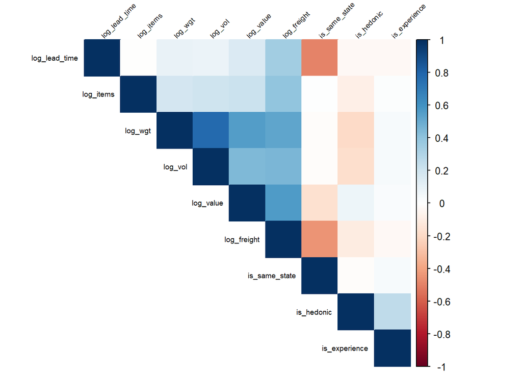

```r
corr_df_y <- orders_eda %>%
  transmute(
    log_lead_time,
    log_wgt, log_vol, log_value, log_freight, log_items,
    is_same_state = as.numeric(is_same_state), is_hedonic = as.numeric(is_hedonic),
    is_experience = as.numeric(is_experience)
  )

cor_mat_y <- cor(corr_df_y, use = "pairwise.complete.obs")

corrplot(
  cor_mat_y,
  method = "color", type = "upper", order = "hclust",
  tl.col = "black", tl.srt = 45, tl.cex = 0.6, number.cex = 0.6
)
```

## 4.3 Pre-model unsupervised clustering EDA

### 4.3.1 Cluster Engineering

```r
orders_eda_strict <- orders_model_strict %>%
  transmute(
    # IDs / grouping
    order_id,
    seller_id,
    customer_state,
    seller_state,
    customer_region,
    seller_region,
    is_same_state,
    is_same_region,
    customer_state_pop_2017,
    seller_state_pop_2017,
    log_customer_pop,
    log_seller_pop,
    z_log_customer_pop,
    z_log_seller_pop,

    # time controls
    purchase_ts,
    purchase_year,
    purchase_wday,
    season,

    # outcome
    lead_time_days_raw,
    delay_vs_estimated_days,
    log_lead_time,

    # predictors with log*
    log_items,
    log_value,
    log_freight,
    log_wgt,
    log_vol,

    # predictors with z-score
    z_log_items,
    z_log_value,
    z_log_freight,
    z_log_wgt,
    z_log_vol,

    # product themes
    is_hedonic,
    is_experience,
    theme_name,

    # for EDA only
    n_items,
    total_value,
    total_freight,
    total_weight_g,
    total_volume_cm3
  )

# 2. Quick sanity check on strict EDA table
orders_eda_strict %>%
  summarise(
    n         = n(),
    n_orders  = n_distinct(order_id),
    n_sellers = n_distinct(seller_id),
    pct_na_y  = mean(is.na(log_lead_time)) * 100
  )
```

| n | n_orders | n_sellers | pct_na_y |
| --- | --- | --- | --- |
| 93853 | 93853 | 2892 | 0 |

```r
# 3. Theme distribution before modelling filter
orders_eda_strict %>%
  count(theme_name, name = "n_orders") %>%
  mutate(pct_orders = 100 * n_orders / sum(n_orders))
```

| theme_name | n_orders | pct_orders |
| --- | --- | --- |
| Experience + Hedonic | 27977 | 29.80938 |
| Experience + Utilitarian | 27279 | 29.06567 |
| Search + Hedonic | 10062 | 10.72102 |
| Search + Utilitarian | 28535 | 30.40393 |

```r
# Final Modeling dataset
## --- Final modeling dataset used in all models: orders_mod ----
# 4. Define final modelling dataset
#    - drop rows with missing outcome
#    - drop unmapped theme bucket (kept only for EDA)
orders_mod <- orders_eda_strict %>%
  filter(
    !is.na(log_lead_time),
    theme_name != "Other (unmapped)"
  )

# 5. Sanity checks on modelling sample
orders_mod %>%
  summarise(
    n         = n(),
    n_orders  = n_distinct(order_id),
    n_sellers = n_distinct(seller_id),
    pct_na_y  = mean(is.na(log_lead_time)) * 100
  )
```

| n | n_orders | n_sellers | pct_na_y |
| --- | --- | --- | --- |
| 93853 | 93853 | 2892 | 0 |

```r
orders_mod %>%
  count(theme_name, name = "n_orders") %>%
  mutate(pct_orders = 100 * n_orders / sum(n_orders))
```

| theme_name | n_orders | pct_orders |
| --- | --- | --- |
| Experience + Hedonic | 27977 | 29.80938 |
| Experience + Utilitarian | 27279 | 29.06567 |
| Search + Hedonic | 10062 | 10.72102 |
| Search + Utilitarian | 28535 | 30.40393 |

```r
glimpse(orders_mod)
```

```
## Rows: 93,853
## Columns: 39
## $ order_id                <chr> "e481f51cbdc54678b7cc49136f2d6af7", "53cdb2fc8…
## $ seller_id               <chr> "3504c0cb71d7fa48d967e0e4c94d59d9", "289cdb325…
## $ customer_state          <chr> "SP", "BA", "GO", "RN", "SP", "PR", "RJ", "RS"…
## $ seller_state            <chr> "SP", "SP", "SP", "MG", "SP", "SP", "SP", "SP"…
## $ customer_region         <chr> "Southeast", "Northeast", "Central-West", "Nor…
## $ seller_region           <chr> "Southeast", "Southeast", "Southeast", "Southe…
## $ is_same_state           <lgl> TRUE, FALSE, FALSE, FALSE, TRUE, FALSE, FALSE,…
## $ is_same_region          <lgl> TRUE, FALSE, FALSE, FALSE, TRUE, FALSE, TRUE, …
## $ customer_state_pop_2017 <dbl> 45094866, 15344447, 6778772, 3507003, 45094866…
## $ seller_state_pop_2017   <dbl> 45094866, 45094866, 45094866, 21119536, 450948…
## $ log_customer_pop        <dbl> 17.62428, 16.54626, 15.72931, 15.07027, 17.624…
## $ log_seller_pop          <dbl> 17.62428, 17.62428, 17.62428, 16.86571, 17.624…
## $ z_log_customer_pop      <dbl> 0.96205490, -0.29313663, -1.24436507, -2.01171…
```

[output cut: 26 more lines]

Before fitting mixed-effects models, I run a **diagnostic** unsupervised clustering step to identify broad shipment regimes. This is used for EDA and model-design intuition only (e.g., interaction candidates), not as a causal modeling block.

**Observe:** shipment predictors are multivariate, correlated, and heavy-tailed.  
**Hypothesis H1:** the order-level shipment space is better represented by multiple latent groups than by one homogeneous cloud.  
**Hypothesis H2:** a parsimonious number of groups can be selected consistently across model-based and geometry-based diagnostics.  
**Confirm test:** Gaussian mixtures (`mclust`) with BIC/ICL for model-based selection, plus k-means silhouette as a geometric cross-check.  
**Decision rule:** BIC/ICL are primary; silhouette and resampling stability are supporting diagnostics. If BIC/ICL peak at the maximum tested `G`, treat it as a boundary warning and run a focused guardrail sensitivity on `K \in \{3,4,5,6\}` using posterior uncertainty and cluster-balance diagnostics before selecting final `K`.

```r
if (!requireNamespace("mclust", quietly = TRUE)) {
  stop("Package 'mclust' is required for Section 4.3 pre-model clustering EDA.")
}
# `Mclust()` may evaluate `mclustBIC` in the caller frame in some environments.
# Define a local alias so knitting works without attaching the whole package.
if (!exists("mclustBIC", mode = "function")) {
  mclustBIC <- mclust::mclustBIC
}

cluster_vars <- c(
  "z_log_wgt", "z_log_vol", "z_log_value", "z_log_freight", "z_log_items"
)
G_grid_pre <- 1:10
k_grid_pre <- 2:10

delay_vec_pre <- if ("delay_vs_estimated_days" %in% names(orders_mod)) {
  as.numeric(orders_mod$delay_vs_estimated_days)
} else {
  rep(NA_real_, nrow(orders_mod))
}

precluster_df <- orders_mod %>%
  dplyr::mutate(row_id = dplyr::row_number()) %>%
  dplyr::transmute(
    row_id,
    seller_id,
    log_lead_time,
    lead_time_days_raw,
    is_hedonic = as.numeric(is_hedonic),
    is_experience = as.numeric(is_experience),
    n_items = as.numeric(n_items),
    total_value = as.numeric(total_value),
    total_freight = as.numeric(total_freight),
    total_weight_g = as.numeric(total_weight_g),
    total_volume_cm3 = as.numeric(total_volume_cm3),
    delay_vs_estimated_days = delay_vec_pre,
    log_wgt, log_vol, log_value, log_freight, log_items,
    z_log_wgt, z_log_vol, z_log_value, z_log_freight, z_log_items,
    is_same_state = as.numeric(is_same_state),
    is_same_region = as.numeric(is_same_region)
  )

precluster_cc <- precluster_df %>%
  dplyr::filter(dplyr::if_all(dplyr::all_of(cluster_vars), is.finite))

if (nrow(precluster_cc) < 500) {
  stop("Too few complete cases for stable pre-model clustering EDA.")
}

precluster_cc <- precluster_cc %>%
  dplyr::mutate(
    freight_per_kg_raw = total_freight / pmax(total_weight_g / 1000, 0.05),
    value_density_raw = total_value / pmax(total_volume_cm3 / 1000, 0.10),
    is_late_est = as.numeric(delay_vs_estimated_days > 0)
  )

cap_freight_perkg_pre <- if (all(!is.finite(precluster_cc$freight_per_kg_raw))) {
  NA_real_
} else {
  as.numeric(stats::quantile(precluster_cc$freight_per_kg_raw, 0.99, na.rm = TRUE))
}
cap_value_density_pre <- if (all(!is.finite(precluster_cc$value_density_raw))) {
  NA_real_
} else {
  as.numeric(stats::quantile(precluster_cc$value_density_raw, 0.99, na.rm = TRUE))
}

cap_freight_perkg_use <- if (is.finite(cap_freight_perkg_pre)) cap_freight_perkg_pre else Inf
cap_value_density_use <- if (is.finite(cap_value_density_pre)) cap_value_density_pre else Inf

precluster_cc <- precluster_cc %>%
  dplyr::mutate(
    freight_per_kg_brl = pmin(freight_per_kg_raw, cap_freight_perkg_use),
    value_density_brl_l = pmin(value_density_raw, cap_value_density_use)
  )

X_pre <- as.matrix(precluster_cc[, cluster_vars, drop = FALSE])
storage.mode(X_pre) <- "double"
X_pre <- scale(X_pre)

n_select <- min(4000L, nrow(precluster_cc))
set.seed(42)
idx_select <- sample(seq_len(nrow(precluster_cc)), size = n_select)
X_select <- X_pre[idx_select, , drop = FALSE]
```

Here I setup chunk defines the clustering matrix (`X_pre`) from standardized shipment features and builds additional KPI variables for interpretation. The clustering fit uses only shipment features; KPI variables are used later to profile cluster meaning.

```r
fit_pre_mclust <- mclust::Mclust(
  X_select,
  G = G_grid_pre,
  modelNames = c("EII", "VII", "EEI", "VVI"),
  verbose = FALSE
)
icl_pre <- mclust::mclustICL(
  X_select,
  G = G_grid_pre,
  modelNames = c("EII", "VII", "EEI", "VVI")
)

pre_tidy_mclust_criterion <- function(obj, value_name) {
  as.data.frame(as.matrix(unclass(obj)), stringsAsFactors = FALSE) %>%
    tibble::rownames_to_column("G") %>%
    dplyr::mutate(G = suppressWarnings(as.integer(G))) %>%
    tidyr::pivot_longer(-G, names_to = "model", values_to = value_name) %>%
    dplyr::filter(!is.na(G), is.finite(.data[[value_name]]))
}

bic_by_g_pre <- pre_tidy_mclust_criterion(fit_pre_mclust$BIC, "BIC") %>%
  dplyr::group_by(G) %>%
  dplyr::slice_max(BIC, n = 1, with_ties = FALSE) %>%
  dplyr::ungroup() %>%
  dplyr::mutate(delta_from_best = max(BIC) - BIC) %>%
  dplyr::arrange(G)
icl_by_g_pre <- pre_tidy_mclust_criterion(icl_pre, "ICL") %>%
  dplyr::group_by(G) %>%
  dplyr::slice_max(ICL, n = 1, with_ties = FALSE) %>%
  dplyr::ungroup() %>%
  dplyr::mutate(delta_from_best = max(ICL) - ICL) %>%
  dplyr::arrange(G)

sil_by_k_pre <- purrr::map_dfr(k_grid_pre, function(k) {
  set.seed(100 + k)
  km <- stats::kmeans(X_select, centers = k, nstart = 30, iter.max = 100)
  sil <- cluster::silhouette(km$cluster, stats::dist(X_select))
  tibble::tibble(
    k = k,
    avg_sil = mean(sil[, 3]),
    tot_withinss = km$tot.withinss
  )
})

k_bic_pre <- fit_pre_mclust$G
k_icl_pre <- icl_by_g_pre %>%
  dplyr::slice_min(delta_from_best, n = 1, with_ties = FALSE) %>%
  dplyr::pull(G)
k_sil_pre <- sil_by_k_pre %>%
  dplyr::slice_max(avg_sil, n = 1, with_ties = FALSE) %>%
  dplyr::pull(k)

k_boundary_pre <- max(G_grid_pre)
boundary_flag_pre <- any(c(k_bic_pre, k_icl_pre) == k_boundary_pre)
model_select_pre <- fit_pre_mclust$modelName

k_guardrail_pre <- sort(unique(intersect(c(3L, 4L, 5L, 6L), G_grid_pre)))
if (length(k_guardrail_pre) == 0) {
  k_guardrail_pre <- sort(unique(intersect(c(k_sil_pre, k_bic_pre, k_icl_pre), G_grid_pre)))
}
if (length(k_guardrail_pre) == 0) {
  k_guardrail_pre <- sort(unique(pmax(2L, c(k_sil_pre, k_icl_pre))))
}

pre_guardrail_metrics <- purrr::map_dfr(k_guardrail_pre, function(k_now) {
  fit_now <- tryCatch(
    mclust::Mclust(X_pre, G = k_now, modelNames = model_select_pre, verbose = FALSE),
    error = function(e) NULL
  )
  if (is.null(fit_now)) {
    return(tibble::tibble(
      k = as.integer(k_now),
      mean_uncertainty = NA_real_,
      p90_uncertainty = NA_real_,
      pct_uncert_gt_0_20 = NA_real_,
      min_cluster_pct = NA_real_,
      max_cluster_pct = NA_real_,
      n_small_clusters_lt5 = NA_integer_
    ))
  }

  pred_now <- tryCatch(predict(fit_now, newdata = X_pre), error = function(e) NULL)
  cl_now <- if (!is.null(pred_now$classification)) pred_now$classification else fit_now$classification
  z_now <- if (!is.null(pred_now$z)) pred_now$z else fit_now$z
  if (is.null(cl_now)) {
    return(tibble::tibble(
      k = as.integer(k_now),
      mean_uncertainty = NA_real_,
      p90_uncertainty = NA_real_,
      pct_uncert_gt_0_20 = NA_real_,
      min_cluster_pct = NA_real_,
      max_cluster_pct = NA_real_,
      n_small_clusters_lt5 = NA_integer_
    ))
  }

  uncertainty_now <- if (!is.null(z_now)) 1 - apply(z_now, 1, max) else rep(NA_real_, length(cl_now))
  size_now <- as.numeric(table(factor(cl_now, levels = seq_len(k_now))))
  pct_now <- 100 * size_now / sum(size_now)

  tibble::tibble(
    k = as.integer(k_now),
    mean_uncertainty = mean(uncertainty_now, na.rm = TRUE),
    p90_uncertainty = stats::quantile(uncertainty_now, 0.90, na.rm = TRUE),
    pct_uncert_gt_0_20 = 100 * mean(uncertainty_now > 0.20, na.rm = TRUE),
    min_cluster_pct = min(pct_now),
    max_cluster_pct = max(pct_now),
    n_small_clusters_lt5 = sum(pct_now < 5)
  )
})

pre_guardrails <- pre_guardrail_metrics %>%
  dplyr::left_join(
    bic_by_g_pre %>% dplyr::transmute(k = G, bic_delta = delta_from_best),
    by = "k"
  ) %>%
  dplyr::left_join(
    icl_by_g_pre %>% dplyr::transmute(k = G, icl_delta = delta_from_best),
    by = "k"
  ) %>%
  dplyr::left_join(
    sil_by_k_pre %>% dplyr::transmute(k, silhouette = avg_sil),
    by = "k"
  ) %>%
  dplyr::mutate(
    rank_bic = dplyr::dense_rank(bic_delta),
    rank_icl = dplyr::dense_rank(icl_delta),
    rank_sil = dplyr::dense_rank(dplyr::desc(silhouette)),
    rank_unc = dplyr::dense_rank(mean_uncertainty),
    rank_balance = dplyr::dense_rank(dplyr::desc(min_cluster_pct)),
    rank_small = dplyr::dense_rank(n_small_clusters_lt5),
    guardrail_score = rank_bic + rank_icl + rank_sil + rank_unc + rank_balance + rank_small
  ) %>%
  dplyr::arrange(guardrail_score, k) %>%
  dplyr::mutate(recommend = dplyr::if_else(dplyr::row_number() == 1, "YES", "NO"))

k_final_pre <- pre_guardrails %>%
  dplyr::slice(1) %>%
  dplyr::pull(k) %>%
  as.integer()

# Optional manual override (set to 3L/4L/5L/6L if needed for reporting sensitivity).
# Current choice: K=5 to prioritize the strongest stability solution.
k_override_pre <- 5L
if (is.finite(k_override_pre) && k_override_pre %in% k_guardrail_pre) {
  k_final_pre <- as.integer(k_override_pre)
}

pre_guardrails <- pre_guardrails %>%
  dplyr::mutate(selected_final = dplyr::if_else(k == k_final_pre, "YES", "NO"))

decision_rule_pre <- if (is.finite(k_override_pre) && k_override_pre %in% k_guardrail_pre) {
  paste0(
    "Stability-priority override: K=", k_final_pre,
    " (best subsample ARI in candidate range)"
  )
} else {
  "Guardrail score on K=3,4,5,6"
}

selection_pre <- tibble::tibble(
  criterion = c(
    "BIC (mclust)",
    "ICL (mclust)",
    "Silhouette (kmeans)",
    "Candidate K range",
    "Boundary warning",
    "Final K used",
    "Selected covariance model",
    "Final decision rule"
  ),
  value = c(
    as.character(k_bic_pre),
    as.character(k_icl_pre),
    as.character(k_sil_pre),
    paste(range(k_guardrail_pre), collapse = " to "),
    ifelse(boundary_flag_pre, "YES", "NO"),
    as.character(k_final_pre),
    model_select_pre,
    decision_rule_pre
  ),
  note = c(
    "best G under BIC",
    "best G under ICL (stronger overlap penalty)",
    "max mean silhouette on selection sample",
    "focused sensitivity window for practical segmentation",
    paste0("BIC/ICL reached G = ", k_boundary_pre, "?"),
    "selected from combined fit/geometry/posterior/balance diagnostics",
    "used for final mclust fit on full sample",
    "if override is active, this supersedes rank-based recommendation"
  )
)
```

This chunk estimates candidate solutions and builds all selection diagnostics. `k_bic_pre`, `k_icl_pre`, and `k_sil_pre` are criterion-wise winners; `pre_guardrails` is the cross-criterion comparison table used to support final choice.

```r
selection_pre
```

| criterion | value | note |
| --- | --- | --- |
| BIC (mclust) | 10 | best G under BIC |
| ICL (mclust) | 10 | best G under ICL (stronger overlap penalty) |
| Silhouette (kmeans) | 3 | max mean silhouette on selection sample |
| Candidate K range | 3 to 6 | focused sensitivity window for practical segmentation |
| Boundary warning | YES | BIC/ICL reached G = 10? |
| Final K used | 5 | selected from combined fit/geometry/posterior/balance diagnostics |
| Selected covariance model | VII | used for final mclust fit on full sample |
| Final decision rule | Stability-priority override: K=5 (best subsample ARI in candidate range) | if override is active, this supersedes rank-based recommendation |

**Interpretation note:** `selection_pre` is the one-line audit trail. It records boundary warnings, candidate range, final selected `K`, and the explicit decision rule used in this run.

```r
pre_guardrails
```

| k | mean_uncertainty | p90_uncertainty | pct_uncert_gt_0_20 | min_cluster_pct | max_cluster_pct | n_small_clusters_lt5 | bic_delta | icl_delta | silhouette | rank_bic | rank_icl | rank_sil | rank_unc | rank_balance | rank_small | guardrail_score | recommend | selected_final |
| --- | --- | --- | --- | --- | --- | --- | --- | --- | --- | --- | --- | --- | --- | --- | --- | --- | --- | --- |
| 3 | 0.07063129 | 0.2742070 | 13.88022 | 21.01371 | 43.98368 | 0 | 4124.551 | 3846.9485 | 0.3496466 | 4 | 4 | 1 | 1 | 1 | 1 | 12 | YES | NO |
| 5 | 0.09547822 | 0.3444335 | 19.23433 | 13.16847 | 31.79547 | 0 | 2001.737 | 1337.4292 | 0.2816696 | 2 | 2 | 2 | 3 | 3 | 1 | 13 | NO | YES |
| 4 | 0.09135309 | 0.3195220 | 18.01541 | 14.58984 | 38.11919 | 0 | 2917.836 | 2201.6153 | 0.2753404 | 3 | 3 | 3 | 2 | 2 | 1 | 14 | NO | NO |
| 6 | 0.12498190 | 0.3954720 | 25.62518 | 11.70554 | 21.57736 | 0 | 1387.508 | 745.5587 | 0.2502455 | 1 | 1 | 4 | 4 | 4 | 1 | 15 | NO | NO |

**Interpretation note:** in `pre_guardrails`, lower `guardrail_score` is better. Also inspect `mean_uncertainty`, `min_cluster_pct`, and `silhouette` directly so the selection is not driven by one metric.

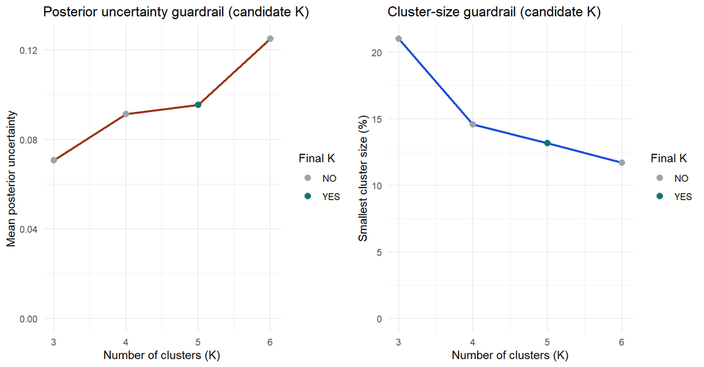

```r
p_unc_pre <- ggplot(pre_guardrails, aes(x = k, y = mean_uncertainty)) +
  geom_line(color = "#9a3412", linewidth = 0.95) +
  geom_point(aes(color = selected_final), size = 2.4) +
  scale_color_manual(values = c("YES" = "#0f766e", "NO" = "#9ca3af")) +
  scale_x_continuous(breaks = sort(unique(pre_guardrails$k))) +
  coord_cartesian(ylim = c(0, NA)) +
  labs(
    title = "Posterior uncertainty guardrail (candidate K)",
    x = "Number of clusters (K)",
    y = "Mean posterior uncertainty",
    color = "Final K"
  ) +
  theme_minimal(base_size = 11)

p_bal_pre <- ggplot(pre_guardrails, aes(x = k, y = min_cluster_pct)) +
  geom_line(color = "#1d4ed8", linewidth = 0.95) +
  geom_point(aes(color = selected_final), size = 2.4) +
  scale_color_manual(values = c("YES" = "#0f766e", "NO" = "#9ca3af")) +
  scale_x_continuous(breaks = sort(unique(pre_guardrails$k))) +
  coord_cartesian(ylim = c(0, NA)) +
  labs(
    title = "Cluster-size guardrail (candidate K)",
    x = "Number of clusters (K)",
    y = "Smallest cluster size (%)",
    color = "Final K"
  ) +
  theme_minimal(base_size = 11)

gridExtra::grid.arrange(p_unc_pre, p_bal_pre, ncol = 2)
```

**Interpretation note:** the left panel should favor lower uncertainty, while the right panel should avoid very small minimum cluster shares. The highlighted point marks the final selected `K`.

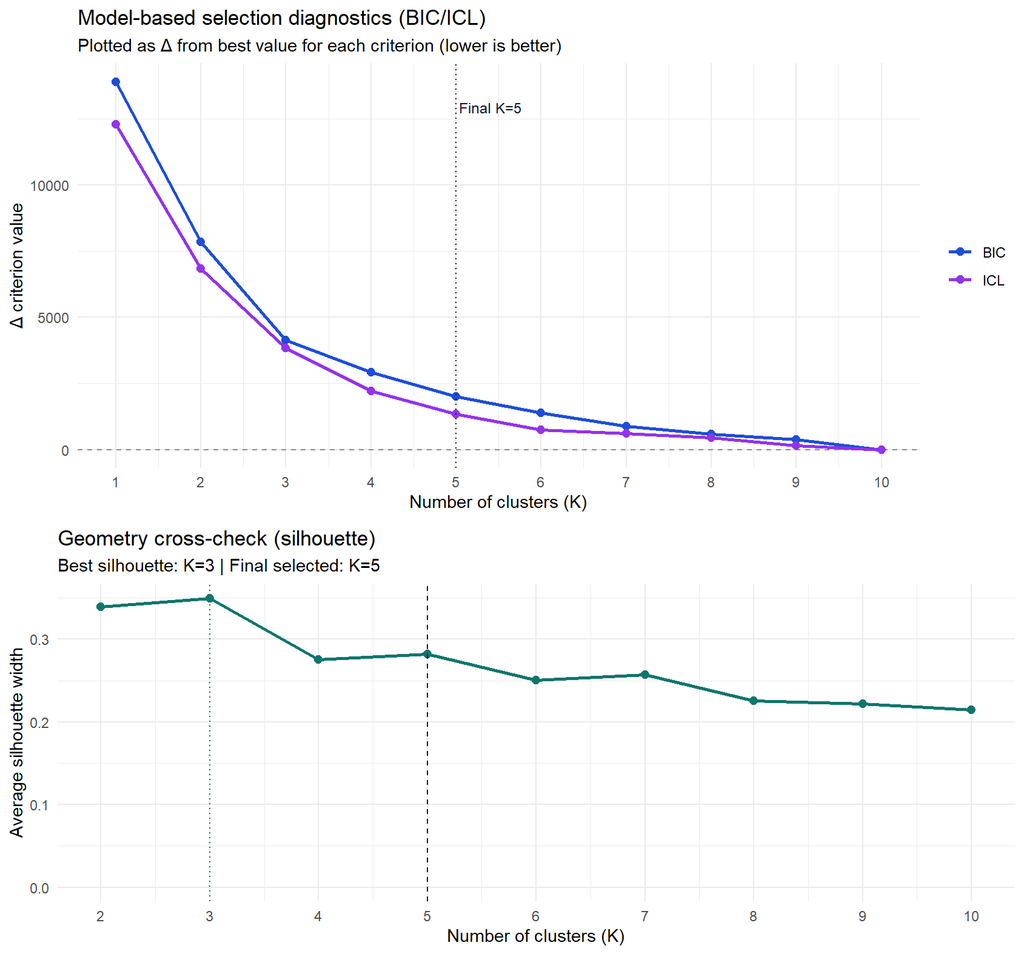

```r
model_delta_pre <- dplyr::bind_rows(
  bic_by_g_pre %>% dplyr::transmute(K = G, metric = "BIC", delta = delta_from_best),
  icl_by_g_pre %>% dplyr::transmute(K = G, metric = "ICL", delta = delta_from_best)
)

p_model_pre <- ggplot(model_delta_pre, aes(x = K, y = delta, color = metric)) +
  geom_hline(yintercept = 0, linetype = 2, color = "grey55") +
  geom_line(linewidth = 0.95) +
  geom_point(size = 2.2) +
  geom_vline(xintercept = k_final_pre, linetype = 3, color = "#111827") +
  annotate(
    "text",
    x = k_final_pre,
    y = max(model_delta_pre$delta, na.rm = TRUE) * 0.93,
    label = paste0("Final K=", k_final_pre),
    color = "#111827",
    hjust = -0.05,
    size = 3.2
  ) +
  scale_color_manual(values = c("BIC" = "#1d4ed8", "ICL" = "#9333ea")) +
  scale_x_continuous(breaks = G_grid_pre) +
  labs(
    title = "Model-based selection diagnostics (BIC/ICL)",
    subtitle = "Plotted as Δ from best value for each criterion (lower is better)",
    x = "Number of clusters (K)",
    y = "Δ criterion value",
    color = NULL
  ) +
  theme_minimal(base_size = 11)

p_sil_pre <- ggplot(sil_by_k_pre, aes(x = k, y = avg_sil)) +
  geom_line(color = "#0f766e", linewidth = 0.95) +
  geom_point(color = "#0f766e", size = 2.2) +
  geom_vline(xintercept = k_sil_pre, linetype = 3, color = "#0f766e") +
  geom_vline(xintercept = k_final_pre, linetype = 2, color = "#111827") +
  scale_x_continuous(breaks = k_grid_pre) +
  coord_cartesian(ylim = c(0, NA)) +
  labs(
    title = "Geometry cross-check (silhouette)",
    subtitle = paste0("Best silhouette: K=", k_sil_pre, " | Final selected: K=", k_final_pre),
    x = "Number of clusters (K)",
    y = "Average silhouette width"
  ) +
  theme_minimal(base_size = 11)

gridExtra::grid.arrange(p_model_pre, p_sil_pre, ncol = 1, heights = c(1.2, 1))
```

**Interpretation note:** top panel shows model-fit trends (BIC/ICL deltas; lower is better), bottom panel shows geometric separation (silhouette; higher is better). If BIC/ICL improve at the boundary, use this plot with guardrails/stability to justify a practical `K`.

### 4.3.2 Cluster Profile

```r
# Fit the final selected model on full pre-clustering data.

fit_pre_final <- mclust::Mclust(
  X_pre,
  G = k_final_pre,
  modelNames = model_select_pre,
  verbose = FALSE
)
pred_pre <- predict(fit_pre_final, newdata = X_pre)
if (is.null(pred_pre$classification)) {
  stop("mclust prediction did not return classifications.")
}
z_pre <- if (!is.null(pred_pre$z)) pred_pre$z else fit_pre_final$z

profile_cols_pre <- c(
  "seller_id", "is_hedonic", "is_experience",
  "n_items", "total_value", "total_freight", "total_weight_g", "total_volume_cm3",
  "delay_vs_estimated_days", "log_wgt", "log_vol", "log_value", "log_freight", "log_items"
)

if (!all(profile_cols_pre %in% names(precluster_cc))) {
  profile_ref_pre <- orders_mod %>%
    dplyr::mutate(row_id = dplyr::row_number()) %>%
    dplyr::transmute(
      row_id,
      seller_id,
      is_hedonic = as.numeric(is_hedonic),
      is_experience = as.numeric(is_experience),
      n_items = as.numeric(n_items),
      total_value = as.numeric(total_value),
      total_freight = as.numeric(total_freight),
      total_weight_g = as.numeric(total_weight_g),
      total_volume_cm3 = as.numeric(total_volume_cm3),
      delay_vs_estimated_days = if ("delay_vs_estimated_days" %in% names(orders_mod)) {
        as.numeric(delay_vs_estimated_days)
      } else {
        NA_real_
      },
      log_wgt, log_vol, log_value, log_freight, log_items
    )

  precluster_cc <- precluster_cc %>%
    dplyr::select(-dplyr::any_of(profile_cols_pre)) %>%
    dplyr::left_join(profile_ref_pre, by = "row_id")
}

if (!all(c("freight_per_kg_brl", "value_density_brl_l", "is_late_est") %in% names(precluster_cc))) {
  precluster_cc <- precluster_cc %>%
    dplyr::mutate(
      freight_per_kg_raw = total_freight / pmax(total_weight_g / 1000, 0.05),
      value_density_raw = total_value / pmax(total_volume_cm3 / 1000, 0.10),
      is_late_est = as.numeric(delay_vs_estimated_days > 0)
    )

  cap_freight_fit_pre <- if (all(!is.finite(precluster_cc$freight_per_kg_raw))) {
    NA_real_
  } else {
    as.numeric(stats::quantile(precluster_cc$freight_per_kg_raw, 0.99, na.rm = TRUE))
  }
  cap_density_fit_pre <- if (all(!is.finite(precluster_cc$value_density_raw))) {
    NA_real_
  } else {
    as.numeric(stats::quantile(precluster_cc$value_density_raw, 0.99, na.rm = TRUE))
  }

  cap_freight_fit_use <- if (is.finite(cap_freight_fit_pre)) cap_freight_fit_pre else Inf
  cap_density_fit_use <- if (is.finite(cap_density_fit_pre)) cap_density_fit_pre else Inf

  precluster_cc <- precluster_cc %>%
    dplyr::mutate(
      freight_per_kg_brl = pmin(freight_per_kg_raw, cap_freight_fit_use),
      value_density_brl_l = pmin(value_density_raw, cap_density_fit_use)
    )
}

precluster_cc <- precluster_cc %>%
  dplyr::mutate(
    cluster_raw = pred_pre$classification,
    cluster_uncertainty = 1 - apply(z_pre, 1, max)
  )

cluster_order_pre <- precluster_cc %>%
  dplyr::group_by(cluster_raw) %>%
  dplyr::summarise(
    mean_ship_index = mean(z_log_wgt + z_log_vol + z_log_value + z_log_freight + z_log_items, na.rm = TRUE),
    .groups = "drop"
  ) %>%
  dplyr::arrange(mean_ship_index) %>%
  dplyr::mutate(precluster = dplyr::row_number()) %>%
  dplyr::select(cluster_raw, precluster)

precluster_cc <- precluster_cc %>%
  dplyr::select(-dplyr::any_of(c("precluster", "mean_ship_index"))) %>%
  dplyr::left_join(cluster_order_pre, by = "cluster_raw") %>%
  dplyr::mutate(
    precluster = factor(
      precluster,
      levels = sort(unique(cluster_order_pre$precluster))
    )
  ) %>%
  dplyr::select(-cluster_raw)

orders_mod$precluster <- NA_character_
orders_mod$precluster[precluster_cc$row_id] <- as.character(precluster_cc$precluster)
orders_mod$precluster <- factor(orders_mod$precluster)

precluster_profile <- precluster_cc %>%
  dplyr::group_by(precluster) %>%
  dplyr::summarise(
    n_orders = dplyr::n(),
    n_sellers = dplyr::n_distinct(seller_id),
    median_orders_per_seller = median(as.numeric(table(seller_id))),
    pct_sample = 100 * dplyr::n() / nrow(precluster_cc),
    mean_lead_days = mean(lead_time_days_raw, na.rm = TRUE),
    median_lead_days = median(lead_time_days_raw, na.rm = TRUE),
    pct_same_state = 100 * mean(is_same_state, na.rm = TRUE),
    pct_same_region = 100 * mean(is_same_region, na.rm = TRUE),
    pct_hedonic = 100 * mean(is_hedonic == 1, na.rm = TRUE),
    pct_experience = 100 * mean(is_experience == 1, na.rm = TRUE),
    median_freight_per_kg_brl = median(freight_per_kg_brl, na.rm = TRUE),
    median_value_density_brl_l = median(value_density_brl_l, na.rm = TRUE),
    median_delay_vs_est_days = dplyr::if_else(
      all(!is.finite(delay_vs_estimated_days), na.rm = TRUE),
      NA_real_,
      median(delay_vs_estimated_days, na.rm = TRUE)
    ),
    pct_late_vs_est = dplyr::if_else(
      all(is.na(is_late_est)),
      NA_real_,
      100 * mean(is_late_est == 1, na.rm = TRUE)
    ),
    median_weight_kg = median(expm1(log_wgt) / 1000, na.rm = TRUE),
    median_volume_l = median(expm1(log_vol) / 1000, na.rm = TRUE),
    median_order_value_brl = median(expm1(log_value), na.rm = TRUE),
    median_freight_brl = median(expm1(log_freight), na.rm = TRUE),
    median_items = median(expm1(log_items), na.rm = TRUE),
    mean_z_wgt = mean(z_log_wgt, na.rm = TRUE),
    mean_z_vol = mean(z_log_vol, na.rm = TRUE),
    mean_z_value = mean(z_log_value, na.rm = TRUE),
    mean_z_freight = mean(z_log_freight, na.rm = TRUE),
    mean_z_items = mean(z_log_items, na.rm = TRUE),
    mean_uncertainty = mean(cluster_uncertainty, na.rm = TRUE),
    .groups = "drop"
  ) %>%
  dplyr::arrange(precluster)

precluster_summary <- precluster_profile %>%
  dplyr::transmute(
    precluster,
    n_orders,
    n_sellers,
    median_orders_per_seller,
    pct_sample,
    median_lead_days,
    pct_late_vs_est,
    median_delay_vs_est_days,
    pct_same_state,
    pct_same_region,
    pct_hedonic,
    pct_experience,
    median_weight_kg,
    median_volume_l,
    median_freight_per_kg_brl,
    median_value_density_brl_l,
    median_order_value_brl,
    median_freight_brl,
    median_items,
    mean_uncertainty
  )
```

We fit the final `mclust` model on full data, assigns clusters, computes posterior uncertainty, and builds interpretable profile summaries for each cluster.

```r
precluster_profile
```

| precluster | n_orders | n_sellers | median_orders_per_seller | pct_sample | mean_lead_days | median_lead_days | pct_same_state | pct_same_region | pct_hedonic | pct_experience | median_freight_per_kg_brl | median_value_density_brl_l | median_delay_vs_est_days | pct_late_vs_est | median_weight_kg | median_volume_l | median_order_value_brl | median_freight_brl | median_items | mean_z_wgt | mean_z_vol | mean_z_value | mean_z_freight | mean_z_items | mean_uncertainty |
| --- | --- | --- | --- | --- | --- | --- | --- | --- | --- | --- | --- | --- | --- | --- | --- | --- | --- | --- | --- | --- | --- | --- | --- | --- | --- |
| 1 | 29845 | 1597 | 4 | 31.79973 | 11.11712 | 9.012431 | 44.48651 | 68.30290 | 41.97353 | 52.69224 | 52.085714 | 20.835938 | -11.12578 | 7.374770 | 0.250 | 2.560 | 50.39 | 14.100 | 1 | -0.9203747 | -0.8918325 | -0.9428707 | -0.61059790 | -0.2830786 | 0.06083692 |
| 2 | 13107 | 1071 | 3 | 13.96546 | 13.81986 | 11.295683 | 23.72778 | 51.17113 | 65.67483 | 65.21706 | 40.447761 | 49.855957 | -12.29247 | 9.262226 | 0.444 | 3.520 | 180.91 | 17.640 | 1 | -0.4847022 | -0.5768828 | 0.7283564 | -0.05436527 | -0.2830786 | 0.15138909 |
| 3 | 23392 | 1470 | 4 | 24.92408 | 12.20105 | 10.040012 | 39.29121 | 67.73256 | 37.20075 | 66.28762 | 13.015414 | 6.952023 | -11.37926 | 7.848837 | 1.250 | 14.000 | 94.63 | 16.250 | 1 | 0.2484219 | 0.4478216 | -0.1778641 | -0.25771804 | -0.2830786 | 0.12447716 |
| 4 | 15135 | 1245 | 3 | 16.12628 | 14.40400 | 11.918669 | 28.19293 | 55.36835 | 26.99042 | 53.29369 | 5.107357 | 6.096190 | -12.21336 | 9.289726 | 5.700 | 32.736 | 184.90 | 26.460 | 1 | 1.2894708 | 1.0460208 | 0.7115472 | 0.67545729 | -0.2830786 | 0.11131544 |
| 5 | 12374 | 1664 | 3 | 13.18445 | 13.43977 | 11.139844 | 31.46921 | 56.49749 | 33.27138 | 59.88363 | 16.671364 | 12.214249 | -12.17766 | 8.315824 | 2.000 | 16.698 | 208.76 | 36.605 | 2 | 0.6864674 | 0.6360900 | 0.9774529 | 1.21318148 | 1.8670963 | 0.04548481 |

**Interpretation note:** use `precluster_profile` for full technical detail. Report medians (days, weight, freight, value, items, delay) and shares (same-state, same-region, late) to describe each regime in operational terms.

```r
precluster_summary
```

| precluster | n_orders | n_sellers | median_orders_per_seller | pct_sample | median_lead_days | pct_late_vs_est | median_delay_vs_est_days | pct_same_state | pct_same_region | pct_hedonic | pct_experience | median_weight_kg | median_volume_l | median_freight_per_kg_brl | median_value_density_brl_l | median_order_value_brl | median_freight_brl | median_items | mean_uncertainty |
| --- | --- | --- | --- | --- | --- | --- | --- | --- | --- | --- | --- | --- | --- | --- | --- | --- | --- | --- | --- |
| 1 | 29845 | 1597 | 4 | 31.79973 | 9.012431 | 7.374770 | -11.12578 | 44.48651 | 68.30290 | 41.97353 | 52.69224 | 0.250 | 2.560 | 52.085714 | 20.835938 | 50.39 | 14.100 | 1 | 0.06083692 |
| 2 | 13107 | 1071 | 3 | 13.96546 | 11.295683 | 9.262226 | -12.29247 | 23.72778 | 51.17113 | 65.67483 | 65.21706 | 0.444 | 3.520 | 40.447761 | 49.855957 | 180.91 | 17.640 | 1 | 0.15138909 |
| 3 | 23392 | 1470 | 4 | 24.92408 | 10.040012 | 7.848837 | -11.37926 | 39.29121 | 67.73256 | 37.20075 | 66.28762 | 1.250 | 14.000 | 13.015414 | 6.952023 | 94.63 | 16.250 | 1 | 0.12447716 |
| 4 | 15135 | 1245 | 3 | 16.12628 | 11.918669 | 9.289726 | -12.21336 | 28.19293 | 55.36835 | 26.99042 | 53.29369 | 5.700 | 32.736 | 5.107357 | 6.096190 | 184.90 | 26.460 | 1 | 0.11131544 |
| 5 | 12374 | 1664 | 3 | 13.18445 | 11.139844 | 8.315824 | -12.17766 | 31.46921 | 56.49749 | 33.27138 | 59.88363 | 2.000 | 16.698 | 16.671364 | 12.214249 | 208.76 | 36.605 | 2 | 0.04548481 |

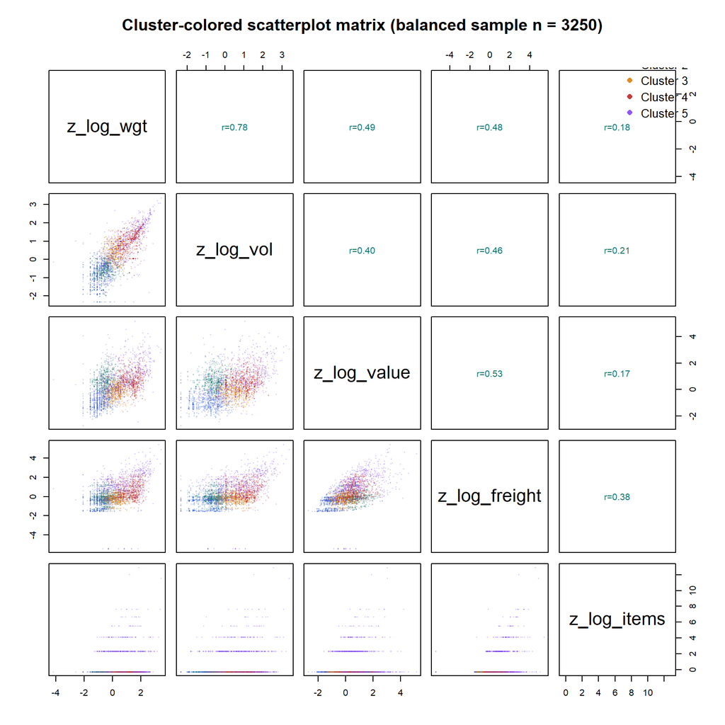

```r
set.seed(2026)

spm_cl_vars <- c("z_log_wgt", "z_log_vol", "z_log_value", "z_log_freight", "z_log_items")
spm_cl_df <- precluster_cc %>%
  dplyr::select(dplyr::all_of(spm_cl_vars), precluster) %>%
  dplyr::filter(!is.na(precluster)) %>%
  dplyr::filter(dplyr::if_all(dplyr::all_of(spm_cl_vars), is.finite))

spm_cl_sample <- spm_cl_df %>%
  dplyr::group_by(precluster) %>%
  dplyr::group_modify(~ {
    n_take <- min(650L, nrow(.x))
    .x[sample.int(nrow(.x), size = n_take, replace = FALSE), , drop = FALSE]
  }) %>%
  dplyr::ungroup()

cl_levels <- levels(droplevels(spm_cl_sample$precluster))
cl_palette <- c("#1d4ed8", "#0f766e", "#d97706", "#b91c1c", "#7c3aed", "#ec4899")
cl_col_map <- stats::setNames(
  grDevices::adjustcolor(cl_palette[seq_along(cl_levels)], alpha.f = 0.30),
  cl_levels
)
pt_col_cl <- cl_col_map[as.character(spm_cl_sample$precluster)]

panel_cor_cl <- function(x, y, digits = 2, prefix = "r=", ...) {
  usr <- par("usr")
  on.exit(par(usr))
  par(usr = c(0, 1, 0, 1))
  r <- stats::cor(x, y, use = "complete.obs")
  txt <- paste0(prefix, formatC(r, digits = digits, format = "f"))
  text(0.5, 0.5, txt, cex = 1.0, col = "#0f766e")
}

panel_scatter_cl <- function(x, y, ...) {
  points(x, y, pch = 16, cex = 0.30, col = pt_col_cl)
}

pairs(
  spm_cl_sample[, spm_cl_vars, drop = FALSE],
  lower.panel = panel_scatter_cl,
  upper.panel = panel_cor_cl,
  main = paste0("Cluster-colored scatterplot matrix (balanced sample n = ", nrow(spm_cl_sample), ")")
)
legend(
  "topright",
  legend = paste("Cluster", cl_levels),
  col = grDevices::adjustcolor(cl_palette[seq_along(cl_levels)], alpha.f = 0.85),
  pch = 16, bty = "n", cex = 0.85
)
```

```r
set.seed(2026)
B_stab_pre <- 12
frac_stab_pre <- 0.70
n_stab_cap_pre <- min(12000L, nrow(X_pre))
idx_stab_pool_pre <- sort(sample.int(nrow(X_pre), size = n_stab_cap_pre, replace = FALSE))
X_stab_pre <- X_pre[idx_stab_pool_pre, , drop = FALSE]
k_stab_pre <- sort(unique(c(3L, 4L, 5L, 6L, k_final_pre)))

stability_pre <- purrr::map_dfr(k_stab_pre, function(k_now) {
  ari_vals <- purrr::map_dbl(seq_len(B_stab_pre), function(b) {
    n_now <- nrow(X_stab_pre)
    n_sub <- as.integer(max(500, floor(frac_stab_pre * n_now)))
    idx1 <- sort(sample.int(n_now, size = n_sub, replace = FALSE))
    idx2 <- sort(sample.int(n_now, size = n_sub, replace = FALSE))

    fit1 <- tryCatch(
      mclust::Mclust(X_stab_pre[idx1, , drop = FALSE], G = k_now, modelNames = model_select_pre, verbose = FALSE),
      error = function(e) NULL
    )
    fit2 <- tryCatch(
      mclust::Mclust(X_stab_pre[idx2, , drop = FALSE], G = k_now, modelNames = model_select_pre, verbose = FALSE),
      error = function(e) NULL
    )
    if (is.null(fit1) || is.null(fit2)) return(NA_real_)

    overlap <- intersect(idx1, idx2)
    if (length(overlap) < max(120, 12 * k_now)) return(NA_real_)

    cl1 <- fit1$classification[match(overlap, idx1)]
    cl2 <- fit2$classification[match(overlap, idx2)]
    mclust::adjustedRandIndex(cl1, cl2)
  })

  tibble::tibble(
    k = k_now,
    n_valid = sum(is.finite(ari_vals)),
    mean_ari = mean(ari_vals, na.rm = TRUE),
    median_ari = median(ari_vals, na.rm = TRUE),
    q25_ari = quantile(ari_vals, 0.25, na.rm = TRUE),
    q75_ari = quantile(ari_vals, 0.75, na.rm = TRUE),
    n_pool = n_stab_cap_pre,
    n_boot = B_stab_pre
  )
})
```

This chunk computes subsample stability via ARI for candidate `K`. Higher `mean_ari` and tighter IQR indicate more reproducible segmentation under resampling.

```r
stability_pre
```

| k | n_valid | mean_ari | median_ari | q25_ari | q75_ari | n_pool | n_boot |
| --- | --- | --- | --- | --- | --- | --- | --- |
| 3 | 12 | 0.9300447 | 0.9355424 | 0.8878416 | 0.9646071 | 12000 | 12 |
| 4 | 12 | 0.6777287 | 0.5155099 | 0.4937920 | 0.9289913 | 12000 | 12 |
| 5 | 12 | 0.9599502 | 0.9648492 | 0.9539732 | 0.9686782 | 12000 | 12 |
| 6 | 12 | 0.7201173 | 0.6819248 | 0.5527622 | 0.8811270 | 12000 | 12 |

**Interpretation note:** check `n_valid` first (should be close to `n_boot`), then compare `mean_ari` and `q25_ari`. A robust choice should not rely on a high mean with a very low lower quartile.

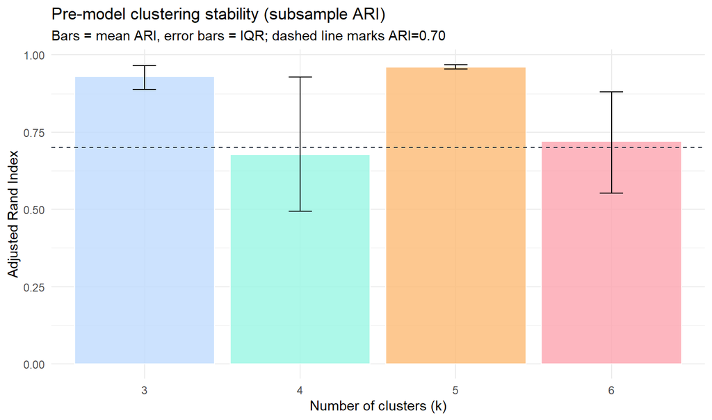

```r
ggplot(stability_pre, aes(x = factor(k), y = mean_ari, fill = factor(k))) +
  geom_col(alpha = 0.8) +
  geom_errorbar(aes(ymin = q25_ari, ymax = q75_ari), width = 0.15) +
  geom_hline(yintercept = 0.70, linetype = 2, color = "#1f2937") +
  labs(
    title = "Pre-model clustering stability (subsample ARI)",
    subtitle = "Bars = mean ARI, error bars = IQR; dashed line marks ARI=0.70",
    x = "Number of clusters (k)",
    y = "Adjusted Rand Index"
  ) +
  theme_minimal(base_size = 11) +
  theme(legend.position = "none")
```

**Interpretation note:** bars above the dashed threshold (`ARI=0.70`) indicate acceptable stability; prefer the candidate with both high mean and narrow uncertainty (IQR).

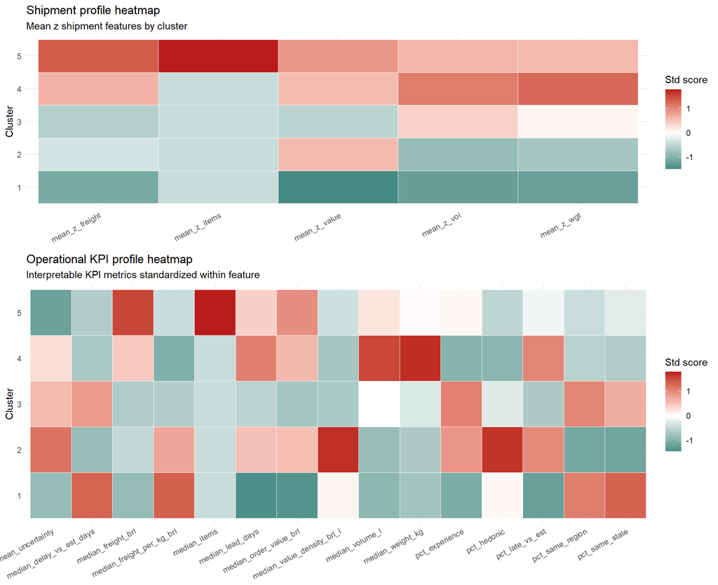

```r
z_within_feature <- function(x) {
  x_num <- as.numeric(x)
  if (all(!is.finite(x_num))) {
    rep(NA_real_, length(x_num))
  } else {
    as.numeric(scale(x_num))
  }
}

ship_cols_pre <- c("mean_z_wgt", "mean_z_vol", "mean_z_value", "mean_z_freight", "mean_z_items")
kpi_cols_pre <- c(
  "median_lead_days", "pct_same_state", "pct_same_region",
  "pct_hedonic", "pct_experience",
  "median_weight_kg", "median_volume_l",
  "median_order_value_brl", "median_freight_brl", "median_items",
  "median_freight_per_kg_brl", "median_value_density_brl_l",
  "pct_late_vs_est", "median_delay_vs_est_days", "mean_uncertainty"
)

ship_cols_use_pre <- intersect(ship_cols_pre, names(precluster_profile))
kpi_cols_use_pre <- intersect(kpi_cols_pre, names(precluster_profile))

precluster_heat_ship <- precluster_profile %>%
  dplyr::select(precluster, dplyr::all_of(ship_cols_use_pre)) %>%
  tidyr::pivot_longer(-precluster, names_to = "feature", values_to = "value") %>%
  dplyr::group_by(feature) %>%
  dplyr::mutate(value_std = z_within_feature(value)) %>%
  dplyr::ungroup()

precluster_heat_kpi <- precluster_profile %>%
  dplyr::select(precluster, dplyr::all_of(kpi_cols_use_pre)) %>%
  tidyr::pivot_longer(-precluster, names_to = "feature", values_to = "value") %>%
  dplyr::group_by(feature) %>%
  dplyr::mutate(value_std = z_within_feature(value)) %>%
  dplyr::ungroup()

p_heat_ship_pre <- ggplot(precluster_heat_ship, aes(x = feature, y = precluster, fill = value_std)) +
  geom_tile(color = "white") +
  scale_fill_gradient2(
    low = "#0f766e", mid = "white", high = "#b91c1c", midpoint = 0,
    na.value = "grey90"
  ) +
  labs(
    title = "Shipment profile heatmap",
    subtitle = "Mean z shipment features by cluster",
    x = NULL,
    y = "Cluster",
    fill = "Std score"
  ) +
  theme_minimal(base_size = 11) +
  theme(axis.text.x = element_text(angle = 28, hjust = 1))

p_heat_kpi_pre <- ggplot(precluster_heat_kpi, aes(x = feature, y = precluster, fill = value_std)) +
  geom_tile(color = "white") +
  scale_fill_gradient2(
    low = "#0f766e", mid = "white", high = "#b91c1c", midpoint = 0,
    na.value = "grey90"
  ) +
  labs(
    title = "Operational KPI profile heatmap",
    subtitle = "Interpretable KPI metrics standardized within feature",
    x = NULL,
    y = "Cluster",
    fill = "Std score"
  ) +
  theme_minimal(base_size = 11) +
  theme(axis.text.x = element_text(angle = 28, hjust = 1))

gridExtra::grid.arrange(p_heat_ship_pre, p_heat_kpi_pre, ncol = 1, heights = c(1, 1.35))
```

**Interpretation note:** colors are standardized within each feature, so this heatmap compares clusters relative to each feature’s own scale. Use it to label clusters as low/mid/high shipment intensity and to attach KPI differences.

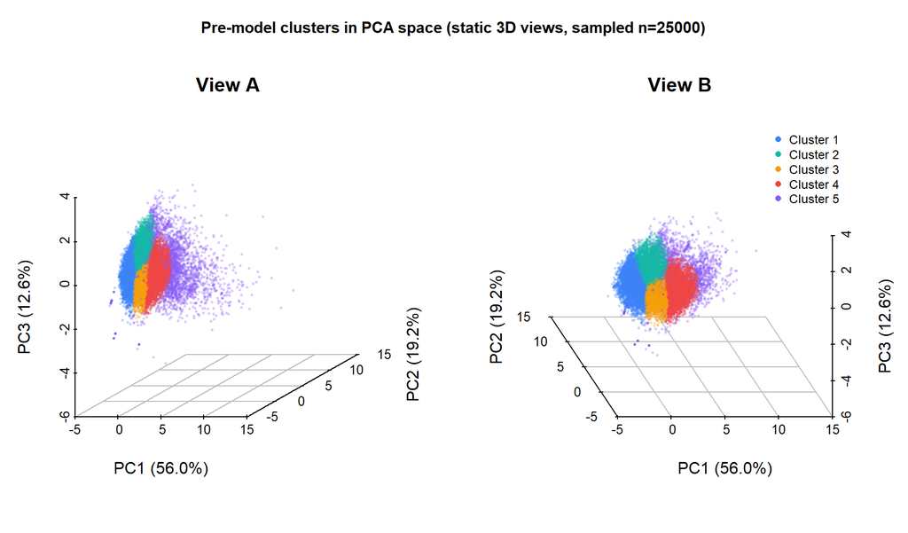

```r
pca_pre <- stats::prcomp(X_pre, center = FALSE, scale. = FALSE)
pca_var_pre <- (pca_pre$sdev^2) / sum(pca_pre$sdev^2)
pca_df_pre <- tibble::tibble(
  PC1 = pca_pre$x[, 1],
  PC2 = pca_pre$x[, 2],
  PC3 = pca_pre$x[, 3],
  precluster = precluster_cc$precluster
)

n_plot_pca_pre <- min(25000L, nrow(pca_df_pre))
set.seed(2026)
idx_plot_pca_pre <- sample.int(nrow(pca_df_pre), size = n_plot_pca_pre, replace = FALSE)
pca_df_plot_pre <- pca_df_pre[idx_plot_pca_pre, , drop = FALSE]

cluster_levels_pre <- sort(unique(as.character(pca_df_plot_pre$precluster)))
palette_pre <- c("#3b82f6", "#14b8a6", "#f59e0b", "#ef4444", "#8b5cf6", "#ec4899", "#0ea5e9", "#84cc16")
if (length(cluster_levels_pre) > length(palette_pre)) {
  palette_pre <- grDevices::hcl.colors(length(cluster_levels_pre), palette = "Dark 3")
}
col_map_pre <- stats::setNames(palette_pre[seq_along(cluster_levels_pre)], cluster_levels_pre)
pt_col_pre <- grDevices::adjustcolor(col_map_pre[as.character(pca_df_plot_pre$precluster)], alpha.f = 0.32)

if (requireNamespace("scatterplot3d", quietly = TRUE)) {
  old_par <- par(no.readonly = TRUE)
  on.exit(par(old_par), add = TRUE)
  par(mfrow = c(1, 2), mar = c(3.8, 3.8, 2.0, 1.0), oma = c(0.2, 0.1, 2.2, 0.1))

  scatterplot3d::scatterplot3d(
    x = pca_df_plot_pre$PC1,
    y = pca_df_plot_pre$PC2,
    z = pca_df_plot_pre$PC3,
    color = pt_col_pre,
    pch = 16,
    cex.symbols = 0.33,
    angle = 32,
    box = FALSE,
    grid = TRUE,
    xlab = paste0("PC1 (", sprintf("%.1f", 100 * pca_var_pre[1]), "%)"),
    ylab = paste0("PC2 (", sprintf("%.1f", 100 * pca_var_pre[2]), "%)"),
    zlab = paste0("PC3 (", sprintf("%.1f", 100 * pca_var_pre[3]), "%)"),
    main = "View A"
  )

  scatterplot3d::scatterplot3d(
    x = pca_df_plot_pre$PC1,
    y = pca_df_plot_pre$PC2,
    z = pca_df_plot_pre$PC3,
    color = pt_col_pre,
    pch = 16,
    cex.symbols = 0.33,
    angle = 118,
    box = FALSE,
    grid = TRUE,
    xlab = paste0("PC1 (", sprintf("%.1f", 100 * pca_var_pre[1]), "%)"),
    ylab = paste0("PC2 (", sprintf("%.1f", 100 * pca_var_pre[2]), "%)"),
    zlab = paste0("PC3 (", sprintf("%.1f", 100 * pca_var_pre[3]), "%)"),
    main = "View B"
  )

  legend(
    "topright",
    legend = paste("Cluster", cluster_levels_pre),
    col = col_map_pre[cluster_levels_pre],
    pch = 16,
    cex = 0.75,
    bty = "n"
  )

  mtext(
    paste0("Pre-model clusters in PCA space (static 3D views, sampled n=", n_plot_pca_pre, ")"),
    outer = TRUE,
    line = 0.35,
    cex = 0.95,
    font = 2
  )
} else {
  ggplot(pca_df_plot_pre, aes(x = PC1, y = PC2, color = precluster)) +
    geom_point(alpha = 0.22, size = 0.7) +
    stat_ellipse(level = 0.70, linewidth = 0.6, show.legend = FALSE) +
    labs(
      title = "Pre-model clusters in PCA space (2D fallback)",
      subtitle = "Install 'scatterplot3d' for static 3D views",
      x = paste0("PC1 (", sprintf("%.1f", 100 * pca_var_pre[1]), "%)"),
      y = paste0("PC2 (", sprintf("%.1f", 100 * pca_var_pre[2]), "%)"),
      color = "Cluster"
    ) +
    theme_minimal(base_size = 11)
}
```

**Interpretation note:** PCA is a visual diagnostic only. For PDF/LaTeX, use the static 3D twin-view figure above to check whether overlap in one projection separates under rotation; residual overlap does not invalidate clustering when stability and uncertainty diagnostics are strong.

```r
n_plot3_pre <- min(25000L, nrow(pca_df_pre))
set.seed(2026)
idx_plot3_pre <- sample.int(nrow(pca_df_pre), size = n_plot3_pre, replace = FALSE)
pca_df3_pre <- pca_df_pre[idx_plot3_pre, , drop = FALSE]

if (requireNamespace("plotly", quietly = TRUE)) {
  col_map_pre <- c(
    "1" = "#3b82f6", "2" = "#14b8a6", "3" = "#f59e0b",
    "4" = "#ef4444", "5" = "#8b5cf6", "6" = "#ec4899"
  )

  p3_pre <- plotly::plot_ly(
    data = pca_df3_pre,
    x = ~PC1, y = ~PC2, z = ~PC3,
    color = ~precluster,
    text = ~paste0("Cluster: ", precluster),
    colors = col_map_pre,
    type = "scatter3d",
    mode = "markers",
    marker = list(size = 2.0, opacity = 0.35),
    hovertemplate = paste(
      "%{text}<br>",
      "PC1: %{x:.2f}<br>",
      "PC2: %{y:.2f}<br>",
      "PC3: %{z:.2f}<extra></extra>"
    )
  )

  p3_pre <- plotly::layout(
    p3_pre,
    title = paste0(
      "Pre-model clusters in PCA space (3D, sampled n=", n_plot3_pre, ")"
    ),
    scene = list(
      xaxis = list(title = paste0("PC1 (", sprintf("%.1f", 100 * pca_var_pre[1]), "%)")),
      yaxis = list(title = paste0("PC2 (", sprintf("%.1f", 100 * pca_var_pre[2]), "%)")),
      zaxis = list(title = paste0("PC3 (", sprintf("%.1f", 100 * pca_var_pre[3]), "%)"))
    )
  )
  p3_pre
} else {
  message("Interactive 3D rotation is available in HTML when 'plotly' is installed.")
}
```

[interactive chart not shown]

**Interpretation note:** use the interactive 3D widget for rotation checks in HTML output. For PDF/LaTeX reporting, rely on the static 3D PCA figure above.

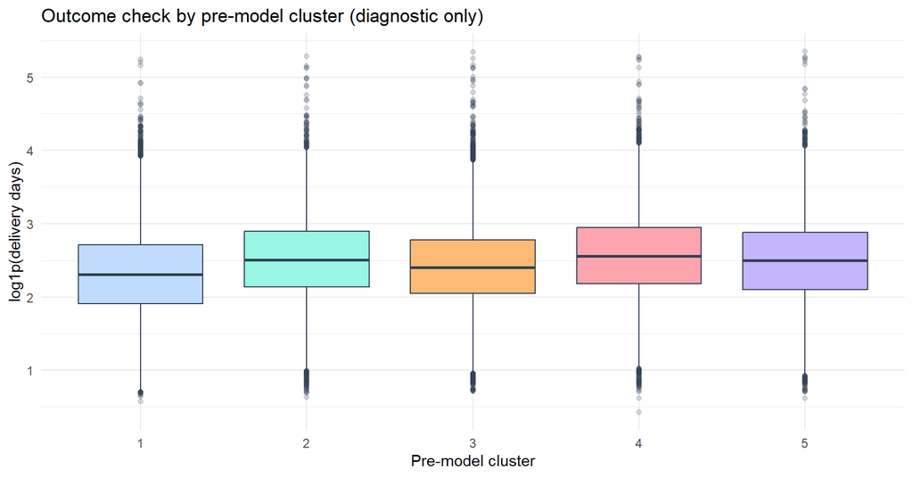

```r
ggplot(precluster_cc, aes(x = precluster, y = log_lead_time, fill = precluster)) +
  geom_boxplot(outlier.alpha = 0.2) +
  labs(
    title = "Outcome check by pre-model cluster (diagnostic only)",
    x = "Pre-model cluster",
    y = "log1p(delivery days)",
    fill = "Cluster"
  ) +
  theme_minimal(base_size = 11) +
  theme(legend.position = "none")
```

This section confirms meaningful latent structure in shipment space and supports using pre-model clusters as an engineering diagnostic before mixed-effects modelling.

From model-based criteria, BIC and ICL improve up to the maximum tested range (`K=10`), so fit criteria alone do not give a clean interior optimum. Geometry gives a different signal: silhouette is highest at `K=3` (`0.350`) and declines afterward, with `K=5` (`0.282`) still slightly better than `K=4` (`0.275`) and clearly better than `K=6` (`0.250`).

Guardrail diagnostics show the expected trade-off between parsimony and segmentation detail. `K=3` has the lowest posterior uncertainty (`0.071`) and strongest minimum cluster share (`21.0%`), while `K=5` remains acceptable on both uncertainty (`0.095`) and balance (`13.2%` smallest cluster), without creating tiny clusters (`<5%`).

Stability is the strongest argument for the final choice in this experiment. Subsample ARI is highest at `K=5` (mean `0.960`, IQR `0.954` to `0.969`), compared with `K=3` (mean `0.930`) and much weaker behaviour for `K=4` (mean `0.678`). Based on this stability-priority objective, I select `K=5` as the final pre-model segmentation.

In practical terms, this means I keep a finer but still interpretable shipment-regime partition that is highly reproducible under resampling. These clusters are used as diagnostic structure to inform model engineering (heterogeneity checks and interaction ideas), not as causal evidence by themselves; confirmatory inference remains in the mixed-effects models below.

The two displays below convert the main EDA findings into decision-ready summaries: (i) how large the same-state routing gap is in raw days, and (ii) which predictors are most strongly associated with log lead time in univariate terms.

```r
eda_routing_gap <- orders_eda %>%
  dplyr::filter(!is.na(lead_time_days_raw), !is.na(is_same_state)) %>%
  dplyr::mutate(route_group = if_else(is_same_state, "Same-state", "Cross-state")) %>%
  dplyr::group_by(route_group) %>%
  dplyr::summarise(
    n_orders = n(),
    median_days = median(lead_time_days_raw, na.rm = TRUE),
    mean_days = mean(lead_time_days_raw, na.rm = TRUE),
    p90_days = quantile(lead_time_days_raw, 0.90, na.rm = TRUE),
    .groups = "drop"
  ) %>%
  dplyr::arrange(route_group)

eda_routing_gap
```

| route_group | n_orders | median_days | mean_days | p90_days |
| --- | --- | --- | --- | --- |
| Cross-state | 60961 | 12.841123 | 15.208279 | 26.36204 |
| Same-state | 34233 | 6.589838 | 7.966679 | 14.27975 |

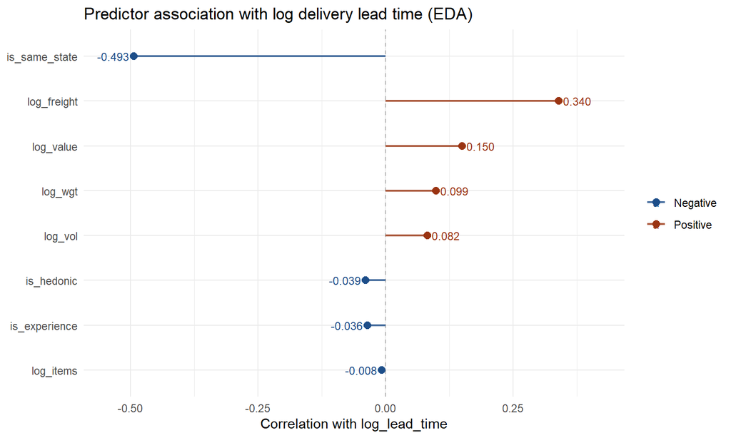

```r
y_cor_plot <- y_cor %>%
  dplyr::mutate(
    predictor = factor(predictor, levels = rev(predictor)),
    direction = if_else(cor_with_outcome >= 0, "Positive", "Negative")
  )

ggplot(y_cor_plot, aes(x = cor_with_outcome, y = predictor, color = direction)) +
  geom_vline(xintercept = 0, color = "grey70", linetype = 2) +
  geom_segment(
    aes(x = 0, xend = cor_with_outcome, y = predictor, yend = predictor),
    linewidth = 0.8,
    alpha = 0.8
  ) +
  geom_point(size = 2.5) +
  geom_text(
    aes(label = sprintf("%.3f", cor_with_outcome)),
    hjust = ifelse(y_cor_plot$cor_with_outcome > 0, -0.15, 1.15),
    size = 3.1
  ) +
  scale_color_manual(values = c("Negative" = "#1d4e89", "Positive" = "#9a3412")) +
  labs(
    title = "Predictor association with log delivery lead time (EDA)",
    x = "Correlation with log_lead_time",
    y = NULL,
    color = NULL
  ) +
  coord_cartesian(xlim = c(min(y_cor_plot$cor_with_outcome, na.rm = TRUE) - 0.05, max(y_cor_plot$cor_with_outcome, na.rm = TRUE) + 0.08)) +
  theme_minimal(base_size = 11)
```

Taken together, the EDA supports five modelling decisions for Section 5: (1) substantial clustering by seller and customer state, motivating crossed random intercepts; (2) a large routing contrast (same-state vs cross-state), so `is_same_state` and `is_same_region` must remain core fixed effects; (3) moderate but non-redundant shipment predictors, so weight/volume/value/freight/items are included jointly; (4) pre-model unsupervised structure in shipment space, with a stable $K=5$ segmentation (highest subsample ARI among candidate $K \in \{3,4,5,6\}$); (5) time and theme factors are relevant controls, but should be interpreted as adjustment terms rather than primary operational levers.

This bridge is important: the clustering result is not treated as a standalone final model, but as evidence that coefficient heterogeneity is plausible. That directly motivates the `M4_c1` and `M4_c2` extensions tested in Section 5.2.5.

# 5. Modelling

## 5.1 Robust Multivariate Diagnostics

Minimum Covariance Determinant (MCD) is a robust way to estimate the multivariate center and covariance of shipment predictors, using the most central subset of observations and downweighting extremes. Mahalanobis distance then measures how far each order is from that robust center while accounting for correlation and scale across predictors (distance is in MD$^2$ units here).

We use MCD + robust Mahalanobis distance because shipment variables are correlated and heavy-tailed, so classical covariance and Euclidean distance can be distorted by extremes. This gives a more stable outlier flag (`ship_outlier_mcd`) for robustness checks in later models.

Interpretation of plots: - Distance plot: each vertical line is one order’s robust MD$^2$; values above the red chi-square cutoff are flagged multivariate outliers. - QQ plot: if points follow the 45-degree line, distances are close to a multivariate-normal reference; upward tail deviations indicate more extreme orders than normal expectation.

```r
# Keep only a compact numeric tail profile here; distribution and geography visuals are in Sections 3.1.2 and 4.1.
orders_mod %>%
  summarise(
    n           = n(),
    mean_days   = mean(lead_time_days_raw, na.rm = TRUE),
    med_days    = median(lead_time_days_raw, na.rm = TRUE),
    p90_days    = quantile(lead_time_days_raw, 0.90, na.rm = TRUE),
    p95_days    = quantile(lead_time_days_raw, 0.95, na.rm = TRUE),
    max_days    = max(lead_time_days_raw, na.rm = TRUE)
  )
```

| n | mean_days | med_days | p90_days | p95_days | max_days |
| --- | --- | --- | --- | --- | --- |
| 93853 | 12.60101 | 10.24818 | 23.14667 | 29.39409 | 209.6286 |

```r
# robust location/scale for lead time
lead_vec <- orders_mod$lead_time_days_raw

alpha_trim <- 0.1
trim_bounds <- stats::quantile(
  lead_vec,
  probs = c(alpha_trim, 1 - alpha_trim),
  na.rm = TRUE,
  names = FALSE
)
lead_wins <- pmax(pmin(lead_vec, trim_bounds[2]), trim_bounds[1])

lead_summary <- tibble(
  mean          = mean(lead_vec, na.rm = TRUE),
  trimmed_mean  = mean(lead_vec, trim = alpha_trim, na.rm = TRUE),
  wins_mean     = base::mean(lead_wins, na.rm = TRUE),
  median        = median(lead_vec, na.rm = TRUE),
  sd            = sd(lead_vec, na.rm = TRUE),
  MAD           = mad(lead_vec, constant = 1, na.rm = TRUE),
  IQR           = IQR(lead_vec, na.rm = TRUE)
)

lead_summary
```

| mean | trimmed_mean | wins_mean | median | sd | MAD | IQR |
| --- | --- | --- | --- | --- | --- | --- |
| 12.60101 | 11.19637 | 11.68874 | 10.24818 | 9.576378 | 4.157477 | 8.994745 |

Location:

Mean lead time ≈ 12.6 days

Trimmed mean (10%) ≈ 11.2 days

Winsorized mean ≈ 11.7 days

Median ≈ 10.25 days

So the classical mean is about 2.3 days higher than the median and 1.4 days higher than the 10% trimmed mean. This tells us the upper tail pulls the mean noticeably upward.

Spread:

SD ≈ 9.58 days

MAD ≈ 4.16 days

IQR ≈ 8.99 days

The robust MAD is less than half the SD, again reflecting a heavy right tail.

```r
# Robust multivariate outliers with rank-safe, regularized MCD

ship_cols <- c("z_log_wgt", "z_log_vol",  "z_log_freight", "z_log_items")

# Build complete-case shipment matrix
ship_df <- orders_mod[, ship_cols, drop = FALSE]
ship_keep_idx <- which(stats::complete.cases(ship_df))
X <- as.matrix(ship_df[ship_keep_idx, , drop = FALSE])
storage.mode(X) <- "double"

# Remove degenerate columns and enforce full column rank
X <- X[, apply(X, 2, stats::sd) > 1e-10, drop = FALSE]
if (ncol(X) == 0L) {
  stop("All shipment predictors were dropped as near-constant.")
}

qrX <- qr(X)
if (qrX$rank == 0L) {
  stop("Shipment predictor matrix has rank 0 after QR filtering.")
}
X <- X[, qrX$pivot[seq_len(qrX$rank)], drop = FALSE]

if (nrow(X) <= ncol(X)) {
  stop("Too few complete cases for MCD after filtering (need nrow(X) > ncol(X)).")
}

# Fit MCD and regularize covariance if needed
set.seed(42)
mcd_fit <- robustbase::covMcd(X, alpha = 0.75)

S <- mcd_fit$cov
eps <- 1e-8
iter <- 0L
while ((!is.finite(rcond(S)) || rcond(S) < 1e-10) && iter < 8L) {
  S <- S + diag(eps, ncol(S))
  eps <- eps * 10
  iter <- iter + 1L
}
if (!is.finite(rcond(S)) || rcond(S) < 1e-10) {
  stop("Regularized MCD covariance is still near-singular; check predictors.")
}

# Robust Mahalanobis distances (squared) and chi-square cutoff
md_robust <- stats::mahalanobis(X, center = mcd_fit$center, cov = S)
df_md <- ncol(X)
cut_chi <- stats::qchisq(0.975, df = df_md)

# Map outlier flags back to full modelling dataset
orders_mod$ship_outlier_mcd <- FALSE
orders_mod$ship_outlier_mcd[ship_keep_idx] <- md_robust > cut_chi

outlier_share_mcd <- mean(orders_mod$ship_outlier_mcd)  # proportion flagged
outlier_share_mcd
```

```
## [1] 0.09637412
```

The estimated outlier share is 9.64%. Under a 97.5% chi-square cutoff, this is clearly above the ~2.5% expected under near-Gaussian behavior, so the shipment-feature space is materially heavy-tailed.

Intuitively, it means:

- Most orders form a “normal cloud” of shipment profiles.
- About 9.6% sit clearly outside that cloud when considering variables jointly (not variable-by-variable).
- So our data has a meaningful minority of unusual shipment combinations (e.g., very heavy + very high freight + multi-item), which can pull classical models.

Important nuance: these are not automatically bad records; they are just atypical patterns. Also, with a 97.5% cutoff, a near-normal dataset would flag ~2.5%, so 9.6% suggests a heavier tail than normal.

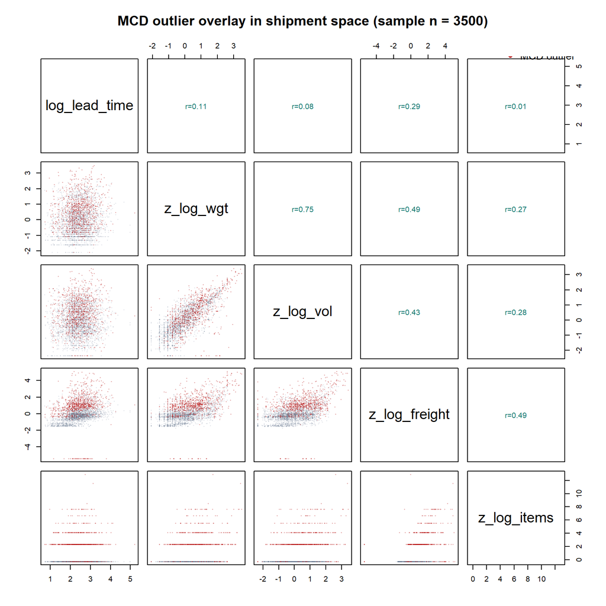

```r
set.seed(2026)

spm_out_vars <- c("log_lead_time", "z_log_wgt", "z_log_vol", "z_log_freight", "z_log_items")
spm_out_df <- orders_mod %>%
  dplyr::select(dplyr::all_of(spm_out_vars), ship_outlier_mcd) %>%
  dplyr::filter(!is.na(ship_outlier_mcd)) %>%
  dplyr::filter(dplyr::if_all(dplyr::all_of(spm_out_vars), is.finite))

idx_non <- which(!spm_out_df$ship_outlier_mcd)
idx_out <- which(spm_out_df$ship_outlier_mcd)

n_non <- min(2600L, length(idx_non))
n_out <- min(900L, length(idx_out))

idx_keep <- c(
  if (n_non > 0L) sample(idx_non, size = n_non, replace = FALSE) else integer(0),
  if (n_out > 0L) sample(idx_out, size = n_out, replace = FALSE) else integer(0)
)

if (length(idx_keep) == 0L) {
  stop("No rows available for outlier scatterplot matrix.")
}

spm_out_sample <- spm_out_df[idx_keep, , drop = FALSE]
pt_col_out <- ifelse(
  spm_out_sample$ship_outlier_mcd,
  grDevices::adjustcolor("#b91c1c", alpha.f = 0.45),
  grDevices::adjustcolor("#64748b", alpha.f = 0.22)
)

panel_cor_out <- function(x, y, digits = 2, prefix = "r=", ...) {
  usr <- par("usr")
  on.exit(par(usr))
  par(usr = c(0, 1, 0, 1))
  r <- stats::cor(x, y, use = "complete.obs")
  txt <- paste0(prefix, formatC(r, digits = digits, format = "f"))
  text(0.5, 0.5, txt, cex = 1.0, col = "#0f766e")
}

panel_scatter_out <- function(x, y, ...) {
  points(x, y, pch = 16, cex = 0.30, col = pt_col_out)
}

pairs(
  spm_out_sample[, spm_out_vars, drop = FALSE],
  lower.panel = panel_scatter_out,
  upper.panel = panel_cor_out,
  main = paste0("MCD outlier overlay in shipment space (sample n = ", nrow(spm_out_sample), ")")
)
legend(
  "topright",
  legend = c("Non-outlier", "MCD outlier"),
  col = c("#64748b", "#b91c1c"),
  pch = 16, bty = "n", cex = 0.9
)
```

The outlier-overlay matrix shows that MCD outliers are concentrated in the tails of the joint shipment distribution rather than forming a completely separate cloud. This supports the robustness strategy used later (robust sensitivity checks and model variants) instead of deleting all flagged observations by default.

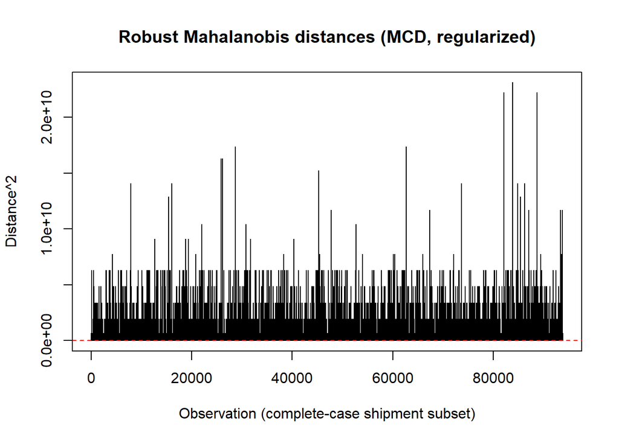

```r
# Distance diagnostics for robust MD^2
plot(
  md_robust,
  type = "h",
  main = "Robust Mahalanobis distances (MCD, regularized)",
  xlab = "Observation (complete-case shipment subset)",
  ylab = "Distance^2"
)
abline(h = cut_chi, col = "red", lty = 2)
```

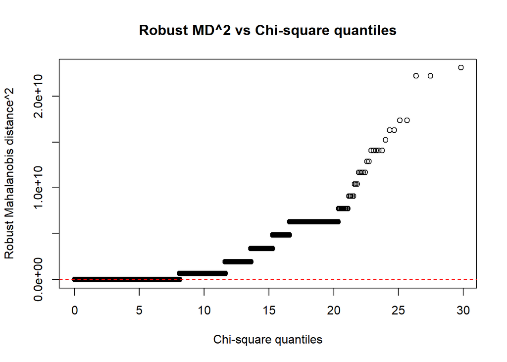

```r
qqplot(
  stats::qchisq(ppoints(length(md_robust)), df = df_md),
  sort(md_robust),
  main = "Robust MD^2 vs Chi-square quantiles",
  xlab = "Chi-square quantiles",
  ylab = "Robust Mahalanobis distance^2"
)
abline(0, 1, col = "red", lty = 2)
```

Interpretation of the diagnostics: the QQ plot departs upward from the 45-degree reference in the right tail, so robust MD$^2$ values are heavier-tailed than a chi-square reference. The distance plot shows a dense central mass plus a visible set of large spikes, indicating a non-trivial group of multivariate shipment outliers rather than a few isolated points. This matches the estimated outlier share (9.64%).

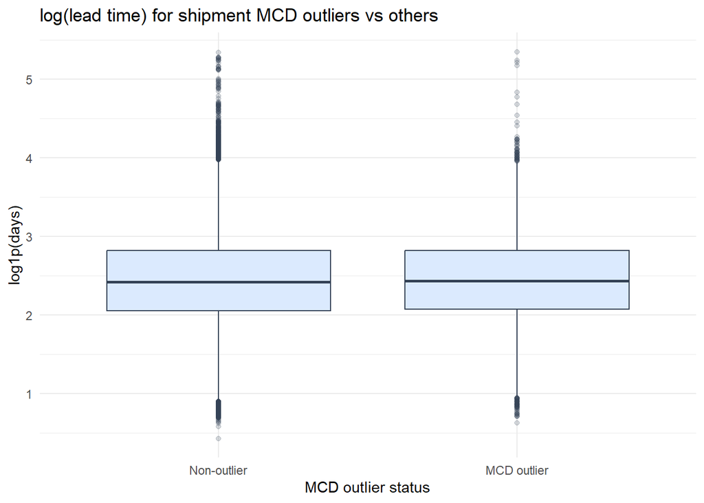

```r
# Compare log_lead_time for MCD outliers vs non-outliers
orders_mod %>%
  mutate(
    ship_outlier_mcd = factor(
      ship_outlier_mcd,
      levels = c(FALSE, TRUE),
      labels = c("Non-outlier", "MCD outlier")
    )
  ) %>%
  ggplot(aes(x = ship_outlier_mcd, y = log_lead_time)) +
  geom_boxplot(outlier.alpha = 0.2) +
  theme_minimal() +
  labs(
    title = "log(lead time) for shipment MCD outliers vs others",
    x = "MCD outlier status",
    y = "log1p(days)"
  )
```

The boxplot compares log1p(lead_time) between orders flagged as multivariate shipment outliers by MCD and all other orders. MCD identifies a subset of orders with unusual shipment profiles, but their delivery times are not systematically extreme.

The medians and interquartile ranges of the two groups are very similar, and the overlap in whiskers and points is substantial. This indicates that although MCD outliers have unusual combinations of shipment characteristics, their delivery times are not systematically more extreme than the rest of the sample. Consequently, I keep these orders in the data and use robust-regression sensitivity plus mixed-model specification checks rather than deleting them.

## 5.2 Models Engineering

In this section, I treat the research questions as a sequence of modelling experiments using `orders_mod`:

- Variance decomposition (M0) to quantify how much variability in log‑lead time is attributable to sellers and customer states via random intercepts.
- Routing experiment (M1) to measure the effect of same‑state and same‑region shipments after accounting for the hierarchy.
- Shipment experiment (M2) to assess how standardized shipment characteristics (weight, volume, value, freight, items) explain remaining variation.
- Baseline full model (M3) adding seasonality, purchase year, and product themes.

Then I extend the baseline with cluster-informed heterogeneity models: - `M4_c1`: add precluster main effects. - `M4_c2`: add precluster interactions for key routing and shipment terms.

For interpretation, I use M3 as the reference baseline and `M4_c2` as the preferred heterogeneity specification.

### 5.2.1 M0: Null model

```r
# Mixed-effects models M0–M3
## Response: log_lead_time
## Random effects: seller_id, customer_state


##  Model M0 – Null model (variance decomposition)
# Why: quantify how much variation is at seller vs customer_state level.

mod_M0 <- lmer(
  log_lead_time ~ 1 +
    (1 | seller_id) +
    (1 | customer_state),
  data = orders_mod,
  REML = TRUE
)

summary(mod_M0)
```

```
## Linear mixed model fit by REML. t-tests use Satterthwaite's method [
## lmerModLmerTest]
## Formula: log_lead_time ~ 1 + (1 | seller_id) + (1 | customer_state)
##    Data: orders_mod
##
## REML criterion at convergence: 133023.2
##
## Scaled residuals:
##     Min      1Q  Median      3Q     Max
## -5.2068 -0.6272 -0.0414  0.5919  6.4038
##
## Random effects:
##  Groups         Name        Variance Std.Dev.
##  seller_id      (Intercept) 0.05885  0.2426
##  customer_state (Intercept) 0.06911  0.2629
##  Residual                   0.23162  0.4813
## Number of obs: 93853, groups:  seller_id, 2892; customer_state, 27
##
## Fixed effects:
##             Estimate Std. Error       df t value Pr(>|t|)
## (Intercept)  2.80175    0.05118 26.53551   54.74   <2e-16 ***
## ---
## Signif. codes:  0 '***' 0.001 '**' 0.01 '*' 0.05 '.' 0.1 ' ' 1
```

```r
# Variance components and ICC-style interpretation
VarCorr(mod_M0)
```

```
##  Groups         Name        Std.Dev.
##  seller_id      (Intercept) 0.24260
##  customer_state (Intercept) 0.26289
##  Residual                   0.48126
```

```r
sigma_M0 <- sigma(mod_M0)^2  # residual variance
```

This null model provides the baseline variance decomposition before any fixed predictors are added. It tells us how much delivery-time heterogeneity is attributable to seller-level and customer-state-level clustering versus within-group residual variation.

Random intercept variances:

Seller: 0.0589 (SD ≈ 0.243).

Customer state:0.0691 (SD ≈ 0.263).

Residual: 0.2316 (SD ≈ 0.481).

Interpretation:

- There is substantial variation in log‑lead time across both sellers and customer states even before adding any covariates.
- Roughly speaking, the between‑state variability is similar in magnitude to the between‑seller variability, which supports your variance‑decomposition RQ about hierarchy

Even without covariates, there is substantial heterogeneity in log‑lead time across both sellers and customer states, with between‑state and between‑seller variation of comparable magnitude.

### 5.2.2 M1: Add routing

```r
## Model M1 – Add routing (same state / same region)
# Why: test how much routing alone explains after accounting for hierarchy.

mod_M1 <- lmer(
  log_lead_time ~
    is_same_state + is_same_region +
    (1 | seller_id) +
    (1 | customer_state),
  data = orders_mod,
  REML = TRUE
)

summary(mod_M1)
```

```
## Linear mixed model fit by REML. t-tests use Satterthwaite's method [
## lmerModLmerTest]
## Formula: log_lead_time ~ is_same_state + is_same_region + (1 | seller_id) +
##     (1 | customer_state)
##    Data: orders_mod
##
## REML criterion at convergence: 124682.6
##
## Scaled residuals:
##     Min      1Q  Median      3Q     Max
## -5.5274 -0.6522 -0.0561  0.5850  6.8524
##
## Random effects:
##  Groups         Name        Variance Std.Dev.
##  seller_id      (Intercept) 0.05431  0.2331
##  customer_state (Intercept) 0.04293  0.2072
##  Residual                   0.21187  0.4603
## Number of obs: 93853, groups:  seller_id, 2892; customer_state, 27
##
## Fixed effects:
##                      Estimate Std. Error         df t value Pr(>|t|)
## (Intercept)         2.829e+00  4.056e-02  2.658e+01   69.76   <2e-16 ***
## is_same_stateTRUE  -4.020e-01  5.513e-03  9.342e+04  -72.91   <2e-16 ***
## is_same_regionTRUE -9.362e-02  5.649e-03  9.341e+04  -16.57   <2e-16 ***
## ---
## Signif. codes:  0 '***' 0.001 '**' 0.01 '*' 0.05 '.' 0.1 ' ' 1
##
## Correlation of Fixed Effects:
##             (Intr) is_sm_sTRUE
## is_sm_sTRUE  0.005
## is_sm_rTRUE -0.019 -0.478
```

Adding routing indicators (`is_same_state`, `is_same_region`) tests whether geography alone explains meaningful variation in lead time after accounting for random intercepts. A negative same-state effect is consistent with faster within-state delivery.

Key changes:

- Random‑effect variances shrink:

Seller SD: from 0.243 → 0.233.

State SD: from 0.263 → 0.207.

Residual SD: from 0.481 → 0.460.

- Routing coefficients:

is_same_stateTRUE ≈ -0.402, statistic significant.

is_same_regionTRUE ≈ -0.094 statistic significant

Interpretation:

- Negative sign means faster deliveries (lower log‑lead time) for same‑state and same‑region shipments.
- Effect sizes are large: same‑state alone corresponds roughly to exp(−0.40)≈0.67, i.e. about 33% shorter expected lead time, holding random effects fixed.
- Likelihood ratio test M0 vs M1: Chisquare ≈8358 on 2 df, p < 2.2e‑16 → routing explains a huge chunk of structured variation.

After including routing, same‑state shipments are on average about one‑third faster and same‑region shipments about 9% faster than cross‑region shipments, and routing alone explains roughly 14% of the variance in log‑lead time.

### 5.2.3 M2: Add shipment predictors

```r
##  Model M2 – Add shipment predictors
# Why: see how much of remaining variation is explained by shipment profile.

mod_M2 <- lmer(
  log_lead_time ~
    is_same_state + is_same_region +
    z_log_wgt + z_log_vol + z_log_value + z_log_freight + z_log_items +
    (1 | seller_id) +
    (1 | customer_state),
  data = orders_mod,
  REML = TRUE
)

summary(mod_M2)
```

```
## Linear mixed model fit by REML. t-tests use Satterthwaite's method [
## lmerModLmerTest]
## Formula: log_lead_time ~ is_same_state + is_same_region + z_log_wgt +
##     z_log_vol + z_log_value + z_log_freight + z_log_items + (1 |
##     seller_id) + (1 | customer_state)
##    Data: orders_mod
##
## REML criterion at convergence: 123976.4
##
## Scaled residuals:
##     Min      1Q  Median      3Q     Max
## -5.3774 -0.6539 -0.0560  0.5871  6.8376
##
## Random effects:
##  Groups         Name        Variance Std.Dev.
##  seller_id      (Intercept) 0.05202  0.2281
##  customer_state (Intercept) 0.03455  0.1859
##  Residual                   0.21033  0.4586
## Number of obs: 93853, groups:  seller_id, 2892; customer_state, 27
##
## Fixed effects:
##                      Estimate Std. Error         df t value Pr(>|t|)
## (Intercept)         2.774e+00  3.659e-02  2.685e+01  75.830  < 2e-16 ***
## is_same_stateTRUE  -3.689e-01  5.710e-03  9.347e+04 -64.602  < 2e-16 ***
## is_same_regionTRUE -8.345e-02  5.643e-03  9.325e+04 -14.787  < 2e-16 ***
## z_log_wgt           9.816e-03  3.617e-03  7.583e+04   2.714  0.00665 **
## z_log_vol          -3.934e-03  3.591e-03  7.221e+04  -1.096  0.27320
## z_log_value         9.185e-03  2.971e-03  5.651e+04   3.091  0.00199 **
## z_log_freight       5.627e-02  2.858e-03  9.332e+04  19.690  < 2e-16 ***
## z_log_items        -3.630e-02  1.845e-03  9.302e+04 -19.669  < 2e-16 ***
## ---
## Signif. codes:  0 '***' 0.001 '**' 0.01 '*' 0.05 '.' 0.1 ' ' 1
##
## Correlation of Fixed Effects:
##             (Intr) is_sm_sTRUE is_sm_rTRUE z_lg_w z_log_vol z_log_val z_lg_f
## is_sm_sTRUE -0.012
## is_sm_rTRUE -0.026 -0.437
## z_log_wgt    0.012 -0.056      -0.017
## z_log_vol    0.007 -0.038      -0.007      -0.495
## z_log_value -0.003 -0.027      -0.001      -0.357 -0.100
## z_log_frght -0.059  0.268       0.075      -0.125 -0.106    -0.303
## z_log_items  0.029 -0.122      -0.039       0.074 -0.078    -0.063    -0.415
```

This model adds shipment characteristics (weight, volume, value, freight, items) on top of routing. Changes in coefficients and fit relative to M1 show how much shipment composition explains additional lead-time variation.

Key points:

Random‑effect SDs shrink further:

Seller: 0.233 → 0.228.

State: 0.207 → 0.186.

Residual: 0.460 → 0.459 (small change).

Shipment effects:

z_log_freight: strong positive (≈ 0.056, p < 2e‑16) → more expensive freight ↔︎ longer lead time, once routing is controlled.

z_log_items: strong negative (≈ -0.036, p < 2e‑16) → orders with more items (relative to typical) tend to be delivered faster, possibly reflecting batching or different logistics channels.

z_log_value: small positive but significant (≈ 0.009, p ≈ 0.002): higher‑value orders are slightly slower, conditional on other factors.

Shipment characteristics significantly refine the model: higher freight cost predicts slower deliveries, while orders with more items tend to be delivered slightly faster, possibly reflecting different consolidation and handling practices.

### 5.2.4 M3: Full model with time + product themes

```r
##Model M3 – Full model with time + themes
# Why: control for seasonality, calendar year, and product themes.

mod_M3 <- lmer(
  log_lead_time ~
    is_same_state + is_same_region +
    z_log_wgt + z_log_vol + z_log_value + z_log_freight + z_log_items +
    season + purchase_year + theme_name +
    (1 | seller_id) +
    (1 | customer_state),
  data = orders_mod,
  REML = TRUE
)

summary(mod_M3)
```

```
## Linear mixed model fit by REML. t-tests use Satterthwaite's method [
## lmerModLmerTest]
## Formula: log_lead_time ~ is_same_state + is_same_region + z_log_wgt +
##     z_log_vol + z_log_value + z_log_freight + z_log_items + season +
##     purchase_year + theme_name + (1 | seller_id) + (1 | customer_state)
##    Data: orders_mod
##
## REML criterion at convergence: 117291
##
## Scaled residuals:
##     Min      1Q  Median      3Q     Max
## -5.0639 -0.6479 -0.0448  0.5921  7.3219
##
## Random effects:
##  Groups         Name        Variance Std.Dev.
##  seller_id      (Intercept) 0.03730  0.1931
##  customer_state (Intercept) 0.03157  0.1777
##  Residual                   0.19667  0.4435
## Number of obs: 93853, groups:  seller_id, 2892; customer_state, 27
##
## Fixed effects:
##                                      Estimate Std. Error         df t value
## (Intercept)                         3.333e+00  4.594e-02  7.966e+01  72.541
## is_same_stateTRUE                  -3.478e-01  5.523e-03  9.363e+04 -62.980
## is_same_regionTRUE                 -7.814e-02  5.441e-03  9.294e+04 -14.362
## z_log_wgt                          -1.836e-03  3.485e-03  7.134e+04  -0.527
## z_log_vol                          -7.142e-03  3.444e-03  6.655e+04  -2.074
## z_log_value                         5.876e-03  2.845e-03  5.127e+04   2.065
## z_log_freight                       8.086e-02  2.779e-03  9.271e+04  29.095
## z_log_items                        -4.442e-02  1.783e-03  9.231e+04 -24.912
## seasonMAM                          -1.312e-01  4.234e-03  9.366e+04 -30.997
## seasonJJA                          -3.479e-01  4.357e-03  9.333e+04 -79.857
## seasonSON                          -1.572e-01  5.389e-03  9.374e+04 -29.171
## purchase_year2017                  -3.656e-01  2.942e-02  8.496e+04 -12.426
## purchase_year2018                  -4.172e-01  2.977e-02  8.431e+04 -14.014
## theme_nameExperience + Utilitarian  1.614e-02  7.086e-03  3.348e+04   2.278
## theme_nameSearch + Hedonic         -5.022e-03  8.244e-03  4.392e+04  -0.609
## theme_nameSearch + Utilitarian      5.475e-03  7.094e-03  2.774e+04   0.772
##                                    Pr(>|t|)
## (Intercept)                          <2e-16 ***
## is_same_stateTRUE                    <2e-16 ***
## is_same_regionTRUE                   <2e-16 ***
## z_log_wgt                            0.5983
## z_log_vol                            0.0381 *
## z_log_value                          0.0389 *
## z_log_freight                        <2e-16 ***
## z_log_items                          <2e-16 ***
## seasonMAM                            <2e-16 ***
## seasonJJA                            <2e-16 ***
## seasonSON                            <2e-16 ***
## purchase_year2017                    <2e-16 ***
## purchase_year2018                    <2e-16 ***
## theme_nameExperience + Utilitarian   0.0227 *
## theme_nameSearch + Hedonic           0.5424
## theme_nameSearch + Utilitarian       0.4403
## ---
## Signif. codes:  0 '***' 0.001 '**' 0.01 '*' 0.05 '.' 0.1 ' ' 1
```

```r
vc_m2 <- as.data.frame(VarCorr(mod_M2))
vc_m3 <- as.data.frame(VarCorr(mod_M3))

sd_m2_seller <- vc_m2$sdcor[vc_m2$grp == "seller_id" & vc_m2$var1 == "(Intercept)"][1]
sd_m2_state <- vc_m2$sdcor[vc_m2$grp == "customer_state" & vc_m2$var1 == "(Intercept)"][1]
sd_m2_resid <- sigma(mod_M2)

sd_m3_seller <- vc_m3$sdcor[vc_m3$grp == "seller_id" & vc_m3$var1 == "(Intercept)"][1]
sd_m3_state <- vc_m3$sdcor[vc_m3$grp == "customer_state" & vc_m3$var1 == "(Intercept)"][1]
sd_m3_resid <- sigma(mod_M3)

m3_fixef_tbl <- broom.mixed::tidy(mod_M3, effects = "fixed")
m3_r2 <- performance::r2(mod_M3)
```

Comment (M3): this is the fully adjusted pooled baseline specification. It controls for time and product mix and provides the benchmark for cluster-conditioned heterogeneity in `M4_c1` and `M4_c2`.

- Random-effect dispersion continues to shrink from M2 to M3: seller SD 0.228 $\rightarrow$ 0.193, state SD 0.186 $\rightarrow$ 0.178, residual SD 0.459 $\rightarrow$ 0.443.
- Baseline fit is stronger in fixed effects: marginal $R^2 = 0.222$, conditional $R^2 = 0.424$.
- Core direction remains stable: same-state and same-region coefficients are negative; freight is positive; items are negative.
- Time controls remain informative, with faster delivery relative to DJF in MAM/JJA/SON and negative year dummies for 2017/2018 versus 2016.
- Theme effects are comparatively small versus routing and freight, so themes act mainly as adjustment controls rather than primary drivers.

### 5.2.5 M4: Full model with Cluster-informed heterogeneity

I now use the pre-model shipment clusters as a model-engineering diagnostic. The purpose is to test whether core effects in M3 (routing and shipment terms) are approximately constant across shipment regimes, or whether there is meaningful heterogeneity that should be acknowledged in interpretation.

```r
orders_mod_cluster <- orders_mod %>%
  dplyr::filter(!is.na(precluster)) %>%
  dplyr::mutate(precluster = factor(precluster))

orders_mod_cluster %>%
  dplyr::count(precluster, name = "n_orders") %>%
  dplyr::mutate(pct_sample = 100 * n_orders / sum(n_orders))
```

| precluster | n_orders | pct_sample |
| --- | --- | --- |
| 1 | 29845 | 31.79973 |
| 2 | 13107 | 13.96546 |
| 3 | 23392 | 24.92408 |
| 4 | 15135 | 16.12628 |
| 5 | 12374 | 13.18445 |

```r
mod_M4_c1 <- lmer(
  log_lead_time ~
    is_same_state + is_same_region +
    z_log_wgt + z_log_vol + z_log_value + z_log_freight + z_log_items +
    season + purchase_year + theme_name +
    precluster +
    (1 | seller_id) +
    (1 | customer_state),
  data = orders_mod_cluster,
  REML = TRUE
)

mod_M4_c2 <- lmer(
  log_lead_time ~
    is_same_state * precluster +
    is_same_region +
    z_log_wgt + z_log_vol + z_log_value +
    z_log_freight * precluster +
    z_log_items * precluster +
    season + purchase_year + theme_name +
    (1 | seller_id) +
    (1 | customer_state),
  data = orders_mod_cluster,
  REML = TRUE
)
```

```r
extract_r2_local <- function(model_obj) {
  r2_obj <- performance::r2(model_obj)
  tibble::tibble(
    r2_marginal = unname(r2_obj[["R2_marginal"]]),
    r2_conditional = unname(r2_obj[["R2_conditional"]])
  )
}

mod_M3_base_ML_cluster <- update(mod_M3, data = orders_mod_cluster, REML = FALSE)
mod_M4_c1_ML <- update(mod_M4_c1, REML = FALSE)
mod_M4_c2_ML <- update(mod_M4_c2, REML = FALSE)

cluster_model_tbl <- tibble::tibble(
  model = c("M3_base", "M4_c1_precluster_main", "M4_c2_cluster_interactions"),
  AIC = c(AIC(mod_M3_base_ML_cluster), AIC(mod_M4_c1_ML), AIC(mod_M4_c2_ML)),
  BIC = c(BIC(mod_M3_base_ML_cluster), BIC(mod_M4_c1_ML), BIC(mod_M4_c2_ML)),
  logLik = c(as.numeric(logLik(mod_M3_base_ML_cluster)),
             as.numeric(logLik(mod_M4_c1_ML)),
             as.numeric(logLik(mod_M4_c2_ML)))
) %>%
  dplyr::bind_cols(dplyr::bind_rows(
    extract_r2_local(mod_M3),
    extract_r2_local(mod_M4_c1),
    extract_r2_local(mod_M4_c2)
  )) %>%
  dplyr::mutate(
    delta_AIC = AIC - min(AIC),
    delta_BIC = BIC - min(BIC)
  ) %>%
  dplyr::arrange(delta_AIC)

cluster_model_tbl
```

| model | AIC | BIC | logLik | r2_marginal | r2_conditional | delta_AIC | delta_BIC |
| --- | --- | --- | --- | --- | --- | --- | --- |
| M4_c2_cluster_interactions | 115806.0 | 116099.0 | -57872.02 | 0.2466368 | 0.4283398 | 0.000 | 0.000 |
| M4_c1_precluster_main | 117138.2 | 117355.5 | -58546.09 | 0.2226147 | 0.4238774 | 1332.138 | 1256.542 |
| M3_base | 117189.1 | 117368.7 | -58575.56 | 0.2217012 | 0.4235631 | 1383.085 | 1269.691 |

```r
lrt_base_vs_M4_c1 <- anova(mod_M3_base_ML_cluster, mod_M4_c1_ML)
lrt_M4_c1_vs_M4_c2 <- anova(mod_M4_c1_ML, mod_M4_c2_ML)

lrt_base_vs_M4_c1
```

|  | npar | AIC | BIC | logLik | -2*log(L) | Chisq | Df | Pr(>Chisq) |
| --- | --- | --- | --- | --- | --- | --- | --- | --- |
| mod_M3_base_ML_cluster | 19 | 117189.1 | 117368.7 | -58575.56 | 117151.1 | NA | NA | NA |
| mod_M4_c1_ML | 23 | 117138.2 | 117355.5 | -58546.09 | 117092.2 | 58.94727 | 4 | 4.827117e-12 |

```r
lrt_M4_c1_vs_M4_c2
```

|  | npar | AIC | BIC | logLik | -2*log(L) | Chisq | Df | Pr(>Chisq) |
| --- | --- | --- | --- | --- | --- | --- | --- | --- |
| mod_M4_c1_ML | 23 | 117138.2 | 117355.5 | -58546.09 | 117092.2 | NA | NA | NA |
| mod_M4_c2_ML | 31 | 115806.0 | 116099.0 | -57872.02 | 115744.0 | 1348.138 | 8 | 9.236586e-286 |

```r
cluster_interaction_terms <- broom.mixed::tidy(mod_M4_c2, effects = "fixed", conf.int = TRUE) %>%
  dplyr::filter(stringr::str_detect(term, "precluster")) %>%
  dplyr::arrange(term)

cluster_interaction_terms
```

| effect | term | estimate | std.error | statistic | df | p.value | conf.low | conf.high |
| --- | --- | --- | --- | --- | --- | --- | --- | --- |
| fixed | is_same_stateTRUE:precluster2 | -0.11026153 | 0.014951257 | -7.374733 | 93235.24 | 1.660333e-13 | -0.13956584 | -0.08095723 |
| fixed | is_same_stateTRUE:precluster3 | -0.10446762 | 0.012276004 | -8.509905 | 93285.50 | 1.766066e-17 | -0.12852846 | -0.08040679 |
| fixed | is_same_stateTRUE:precluster4 | -0.14844957 | 0.012805564 | -11.592584 | 93678.51 | 4.718738e-31 | -0.17354833 | -0.12335080 |
| fixed | is_same_stateTRUE:precluster5 | -0.19567184 | 0.013045168 | -14.999565 | 93475.21 | 8.469877e-51 | -0.22124023 | -0.17010345 |
| fixed | precluster2 | -0.04810055 | 0.007728352 | -6.223908 | 93046.54 | 4.869810e-10 | -0.06324804 | -0.03295306 |
| fixed | precluster2:z_log_freight | -0.16835174 | 0.011998904 | -14.030593 | 93490.17 | 1.124637e-44 | -0.19186946 | -0.14483401 |
| fixed | precluster3 | -0.04313215 | 0.007122397 | -6.055847 | 93356.82 | 1.402117e-09 | -0.05709197 | -0.02917232 |
| fixed | precluster3:z_log_freight | -0.14295471 | 0.012246243 | -11.673353 | 93559.26 | 1.834076e-31 | -0.16695722 | -0.11895221 |
| fixed | precluster4 | -0.03356508 | 0.010276809 | -3.266099 | 93610.82 | 1.090793e-03 | -0.05370751 | -0.01342264 |
| fixed | precluster4:z_log_freight | -0.27330654 | 0.009749031 | -28.034226 | 93795.03 | 3.211005e-172 | -0.29241453 | -0.25419854 |

[output cut: 2 more lines]

```r
cluster_key_terms <- c("is_same_stateTRUE", "is_same_regionTRUE", "z_log_freight", "z_log_items", "z_log_value")

fit_cluster_stratified <- function(cluster_label) {
  dat <- orders_mod_cluster %>%
    dplyr::filter(precluster == cluster_label)

  fit_try <- tryCatch(
    lmer(
      log_lead_time ~
        is_same_state + is_same_region +
        z_log_freight + z_log_items + z_log_value +
        season + purchase_year + theme_name +
        (1 | seller_id) + (1 | customer_state),
      data = dat,
      REML = TRUE
    ),
    error = function(e) NULL
  )

  model_used <- "seller + state random intercepts"
  if (is.null(fit_try)) {
    fit_try <- tryCatch(
      lmer(
        log_lead_time ~
          is_same_state + is_same_region +
          z_log_freight + z_log_items + z_log_value +
          season + purchase_year + theme_name +
          (1 | seller_id),
        data = dat,
        REML = TRUE
      ),
      error = function(e) NULL
    )
    model_used <- "seller random intercept only"
  }

  if (is.null(fit_try)) {
    return(tibble::tibble(
      precluster = as.character(cluster_label),
      model_used = "fit_failed",
      term = NA_character_,
      estimate = NA_real_,
      std.error = NA_real_,
      conf.low = NA_real_,
      conf.high = NA_real_,
      p.value = NA_real_
    ))
  }

  broom.mixed::tidy(fit_try, effects = "fixed", conf.int = TRUE) %>%
    dplyr::mutate(
      precluster = as.character(cluster_label),
      model_used = model_used
    ) %>%
    dplyr::select(precluster, model_used, term, estimate, std.error, conf.low, conf.high, p.value)
}

cluster_stratified_tbl <- purrr::map_dfr(levels(orders_mod_cluster$precluster), fit_cluster_stratified) %>%
  dplyr::filter(term %in% cluster_key_terms)

cluster_stratified_tbl
```

| precluster | model_used | term | estimate | std.error | conf.low | conf.high | p.value |
| --- | --- | --- | --- | --- | --- | --- | --- |
| 1 | seller + state random intercepts | is_same_stateTRUE | -0.188787131 | 0.011601589 | -0.211526852 | -0.166047410 | 2.969874e-59 |
| 1 | seller + state random intercepts | is_same_regionTRUE | -0.026030617 | 0.010343230 | -0.046304031 | -0.005757203 | 1.185326e-02 |
| 1 | seller + state random intercepts | z_log_freight | 0.399469477 | 0.009308594 | 0.381223929 | 0.417715024 | 0.000000e+00 |
| 1 | seller + state random intercepts | z_log_value | -0.019688768 | 0.006745297 | -0.032910104 | -0.006467432 | 3.516718e-03 |
| 2 | seller + state random intercepts | is_same_stateTRUE | -0.308571871 | 0.015026993 | -0.338026969 | -0.279116774 | 3.018540e-92 |
| 2 | seller + state random intercepts | is_same_regionTRUE | -0.049059587 | 0.012586642 | -0.073731252 | -0.024387923 | 9.757818e-05 |
| 2 | seller + state random intercepts | z_log_freight | 0.177517837 | 0.012076405 | 0.153846092 | 0.201189582 | 1.738474e-48 |
| 2 | seller + state random intercepts | z_log_value | 0.001199295 | 0.008674908 | -0.015805229 | 0.018203818 | 8.900466e-01 |
| 3 | seller + state random intercepts | is_same_stateTRUE | -0.258535039 | 0.011734760 | -0.281535961 | -0.235534116 | 1.826783e-106 |
| 3 | seller + state random intercepts | is_same_regionTRUE | -0.072774124 | 0.011515210 | -0.095344859 | -0.050203388 | 2.672735e-10 |

[output cut: 11 more lines]

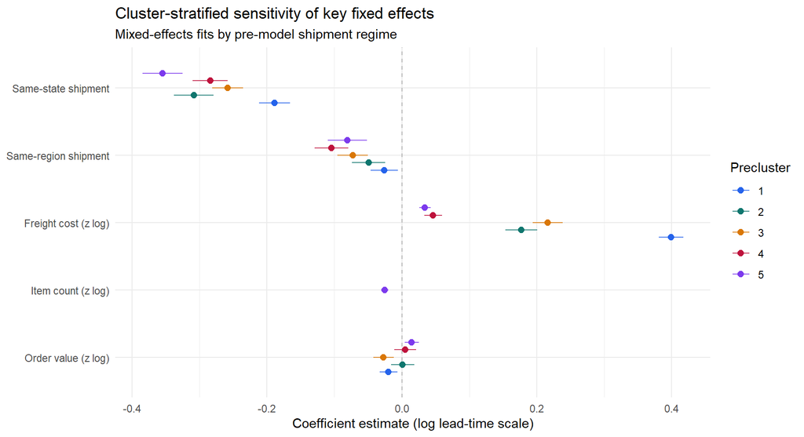

```r
cluster_term_labels <- c(
  is_same_stateTRUE = "Same-state shipment",
  is_same_regionTRUE = "Same-region shipment",
  z_log_freight = "Freight cost (z log)",
  z_log_items = "Item count (z log)",
  z_log_value = "Order value (z log)"
)

plot_cluster_strata <- cluster_stratified_tbl %>%
  dplyr::mutate(
    term_label = factor(cluster_term_labels[term], levels = rev(unname(cluster_term_labels))),
    precluster = factor(precluster, levels = sort(unique(precluster)))
  )

ggplot(plot_cluster_strata, aes(x = estimate, y = term_label, color = precluster)) +
  geom_vline(xintercept = 0, color = "grey70", linetype = 2) +
  geom_point(position = position_dodge(width = 0.55), size = 2.1) +
  geom_errorbar(
    aes(xmin = conf.low, xmax = conf.high),
    width = 0,
    position = position_dodge(width = 0.55),
    alpha = 0.8
  ) +
  labs(
    title = "Cluster-stratified sensitivity of key fixed effects",
    subtitle = "Mixed-effects fits by pre-model shipment regime",
    x = "Coefficient estimate (log lead-time scale)",
    y = NULL,
    color = "Precluster"
  ) +
  theme_minimal(base_size = 11)
```

Interpretation for this run:

- The selected partition (`K = 5) is usable for mixed modelling: cluster shares range from 13.2% to 31.8%.
- Adding cluster main effects (`M4_c1`) improves fit versus M3 ($\chi^2 = 58.95$, $df = 4$, p = 4.83e-12).
- Adding interactions (`M4_c2`) gives a much larger gain ($\chi^2 = 1348.1$, $df = 8$, p <1e-16) and improves AIC/BIC from 117189/117369 to 115806/116099.
- Marginal $R^2$ increases from 0.222 (M3) to 0.247 (M4_c2), while conditional $R^2$ moves from 0.424 to 0.428.
- Direction is stable but magnitude is regime-specific: same-state effects are negative in every cluster (-0.355 to -0.189), while freight effects stay positive (0.034 to 0.399).

## 5.3 Model comparison and final selection

```r
# Likelihood ratio test M0 vs M1 (REML off for fair comparison)
mod_M0_ML <- update(mod_M0, REML = FALSE)
mod_M1_ML <- update(mod_M1, REML = FALSE)
lrt_M0_M1 <- anova(mod_M0_ML, mod_M1_ML)
lrt_M0_M1
```

|  | npar | AIC | BIC | logLik | -2*log(L) | Chisq | Df | Pr(>Chisq) |
| --- | --- | --- | --- | --- | --- | --- | --- | --- |
| mod_M0_ML | 4 | 133027.1 | 133064.9 | -66509.54 | 133019.1 | NA | NA | NA |
| mod_M1_ML | 6 | 124672.7 | 124729.4 | -62330.35 | 124660.7 | 8358.365 | 2 | 0 |

```r
mod_M2_ML <- update(mod_M2, REML = FALSE)
lrt_M1_M2 <- anova(mod_M1_ML, mod_M2_ML)
lrt_M1_M2
```

|  | npar | AIC | BIC | logLik | -2*log(L) | Chisq | Df | Pr(>Chisq) |
| --- | --- | --- | --- | --- | --- | --- | --- | --- |
| mod_M1_ML | 6 | 124672.7 | 124729.4 | -62330.35 | 124660.7 | NA | NA | NA |
| mod_M2_ML | 11 | 123925.8 | 124029.8 | -61951.92 | 123903.8 | 756.8647 | 5 | 2.477332e-161 |

```r
mod_M3_ML <- update(mod_M3, REML = FALSE)
lrt_M2_M3 <- anova(mod_M2_ML, mod_M3_ML)
lrt_M2_M3
```

|  | npar | AIC | BIC | logLik | -2*log(L) | Chisq | Df | Pr(>Chisq) |
| --- | --- | --- | --- | --- | --- | --- | --- | --- |
| mod_M2_ML | 11 | 123925.8 | 124029.8 | -61951.92 | 123903.8 | NA | NA | NA |
| mod_M3_ML | 19 | 117189.1 | 117368.7 | -58575.56 | 117151.1 | 6752.716 | 8 | 0 |

```r
# M3 vs M4 comparison on common cluster-ready sample
lrt_base_vs_M4_c1
```

|  | npar | AIC | BIC | logLik | -2*log(L) | Chisq | Df | Pr(>Chisq) |
| --- | --- | --- | --- | --- | --- | --- | --- | --- |
| mod_M3_base_ML_cluster | 19 | 117189.1 | 117368.7 | -58575.56 | 117151.1 | NA | NA | NA |
| mod_M4_c1_ML | 23 | 117138.2 | 117355.5 | -58546.09 | 117092.2 | 58.94727 | 4 | 4.827117e-12 |

```r
lrt_M4_c1_vs_M4_c2
```

|  | npar | AIC | BIC | logLik | -2*log(L) | Chisq | Df | Pr(>Chisq) |
| --- | --- | --- | --- | --- | --- | --- | --- | --- |
| mod_M4_c1_ML | 23 | 117138.2 | 117355.5 | -58546.09 | 117092.2 | NA | NA | NA |
| mod_M4_c2_ML | 31 | 115806.0 | 116099.0 | -57872.02 | 115744.0 | 1348.138 | 8 | 9.236586e-286 |

Model comparison takeaway:

- M1 $\rightarrow$ M2 is strongly supported ($\chi^2 = 756.9$, $df = 5$, p <1e-16); shipment variables add clear explanatory value beyond routing.
- M2 $\rightarrow$ M3 is also strongly supported ($\chi^2 = 6752.7$, $df = 8$, p <1e-16); time and theme controls matter materially.
- On the common cluster-ready sample, M3 $\rightarrow$ M4_c1 and M4_c1 $\rightarrow$ M4_c2 are both decisively supported (4.83e-12 and <1e-16), confirming non-trivial cluster-conditioned heterogeneity.
- Final choice: `M4_c2_cluster_interactions` is the preferred inferential model; M3 remains the pooled baseline comparator.

```r
##  Model fit diagnostics and R²

# Marginal and conditional R² for each model
R2_M0 <- performance::r2(mod_M0)
R2_M1 <- performance::r2(mod_M1)
R2_M2 <- performance::r2(mod_M2)
R2_M3 <- performance::r2(mod_M3)

R2_M0
```

```
## # R2 for Mixed Models
##
##   Conditional R2: 0.356
##      Marginal R2: 0.000
```

```r
R2_M1
```

```
## # R2 for Mixed Models
##
##   Conditional R2: 0.409
##      Marginal R2: 0.138
```

```r
R2_M2
```

```
## # R2 for Mixed Models
##
##   Conditional R2: 0.405
##      Marginal R2: 0.160
```

```r
R2_M3
```

```
## # R2 for Mixed Models
##
##   Conditional R2: 0.424
##      Marginal R2: 0.222
```

```r
extract_r2 <- function(model) {
  r2_obj <- performance::r2(model)
  tibble::tibble(
    r2_marginal = unname(r2_obj[["R2_marginal"]]),
    r2_conditional = unname(r2_obj[["R2_conditional"]])
  )
}

model_list_ml <- list(
  M0 = mod_M0_ML,
  M1 = mod_M1_ML,
  M2 = mod_M2_ML,
  M3 = mod_M3_ML
)

model_compare_tbl <- tibble::tibble(
  model = names(model_list_ml),
  AIC = sapply(model_list_ml, AIC),
  BIC = sapply(model_list_ml, BIC),
  logLik = sapply(model_list_ml, function(m) as.numeric(logLik(m)))
) %>%
  dplyr::bind_cols(dplyr::bind_rows(lapply(model_list_ml, extract_r2))) %>%
  dplyr::mutate(
    delta_AIC = AIC - min(AIC),
    delta_BIC = BIC - min(BIC)
  )

model_compare_tbl
```

| model | AIC | BIC | logLik | r2_marginal | r2_conditional | delta_AIC | delta_BIC |
| --- | --- | --- | --- | --- | --- | --- | --- |
| M0 | 133027.1 | 133064.9 | -66509.54 | 0.0000000 | 0.3512403 | 15837.946 | 15696.204 |
| M1 | 124672.7 | 124729.4 | -62330.35 | 0.1386981 | 0.4065571 | 7483.581 | 7360.738 |
| M2 | 123925.8 | 124029.8 | -61951.92 | 0.1602639 | 0.4024622 | 6736.716 | 6661.121 |
| M3 | 117189.1 | 117368.7 | -58575.56 | 0.2225355 | 0.4215180 | 0.000 | 0.000 |

For the final model decision, the key comparison is M3 versus M4 on the common cluster-ready sample:

```r
cluster_model_tbl %>%
  dplyr::mutate(
    selected_final = dplyr::if_else(
      model == "M4_c2_cluster_interactions",
      "YES",
      "NO"
    )
  ) %>%
  dplyr::arrange(delta_AIC, delta_BIC)
```

| model | AIC | BIC | logLik | r2_marginal | r2_conditional | delta_AIC | delta_BIC | selected_final |
| --- | --- | --- | --- | --- | --- | --- | --- | --- |
| M4_c2_cluster_interactions | 115806.0 | 116099.0 | -57872.02 | 0.2466368 | 0.4283398 | 0.000 | 0.000 | YES |
| M4_c1_precluster_main | 117138.2 | 117355.5 | -58546.09 | 0.2226147 | 0.4238774 | 1332.138 | 1256.542 | NO |
| M3_base | 117189.1 | 117368.7 | -58575.56 | 0.2217012 | 0.4235631 | 1383.085 | 1269.691 | NO |

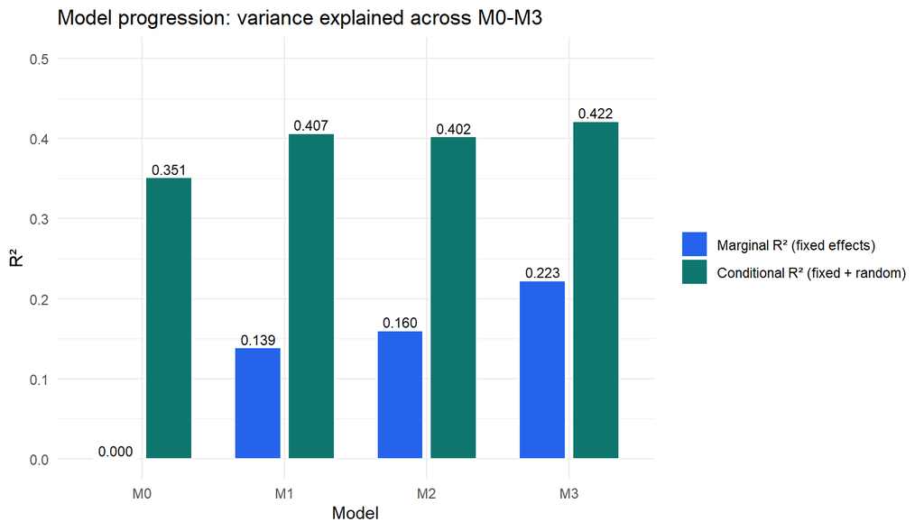

```r
model_r2_plot <- model_compare_tbl %>%
  dplyr::select(model, r2_marginal, r2_conditional) %>%
  tidyr::pivot_longer(
    cols = c(r2_marginal, r2_conditional),
    names_to = "metric",
    values_to = "value"
  ) %>%
  dplyr::mutate(
    metric = factor(
      metric,
      levels = c("r2_marginal", "r2_conditional"),
      labels = c("Marginal R² (fixed effects)", "Conditional R² (fixed + random)")
    )
  )

ggplot(model_r2_plot, aes(x = model, y = value, fill = metric)) +
  geom_col(position = position_dodge(width = 0.75), width = 0.65) +
  geom_text(
    aes(label = sprintf("%.3f", value)),
    position = position_dodge(width = 0.75),
    vjust = -0.3,
    size = 3
  ) +
  scale_fill_manual(values = c("Marginal R² (fixed effects)" = "#2563eb", "Conditional R² (fixed + random)" = "#0f766e")) +
  labs(
    title = "Model progression: variance explained across M0-M3",
    x = "Model",
    y = "R²",
    fill = NULL
  ) +
  coord_cartesian(ylim = c(0, max(model_r2_plot$value, na.rm = TRUE) + 0.08)) +
  theme_minimal(base_size = 11)
```

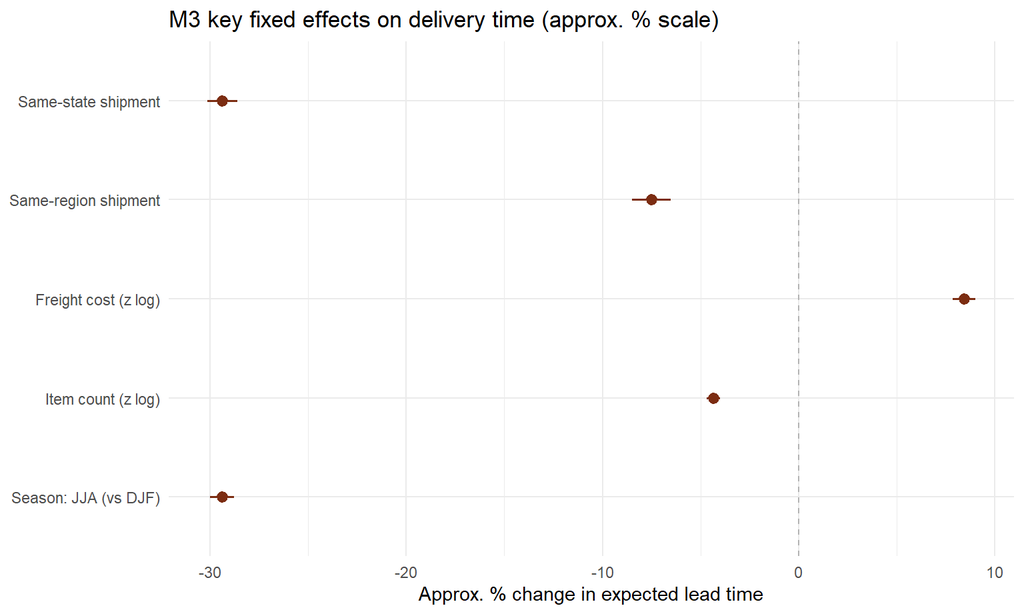

```r
m3_key_terms <- c("is_same_stateTRUE", "is_same_regionTRUE", "z_log_freight", "z_log_items", "seasonJJA")
m3_term_labels <- c(
  is_same_stateTRUE = "Same-state shipment",
  is_same_regionTRUE = "Same-region shipment",
  z_log_freight = "Freight cost (z log)",
  z_log_items = "Item count (z log)",
  seasonJJA = "Season: JJA (vs DJF)"
)

m3_key_effects <- broom.mixed::tidy(
  mod_M3_ML,
  effects = "fixed",
  conf.int = TRUE,
  conf.method = "Wald"
) %>%
  dplyr::filter(term %in% m3_key_terms) %>%
  dplyr::mutate(
    term_label = factor(m3_term_labels[term], levels = rev(unname(m3_term_labels))),
    pct_effect = 100 * (exp(estimate) - 1),
    pct_low = 100 * (exp(conf.low) - 1),
    pct_high = 100 * (exp(conf.high) - 1)
  )

ggplot(m3_key_effects, aes(x = pct_effect, y = term_label)) +
  geom_vline(xintercept = 0, color = "grey70", linetype = 2) +
  geom_pointrange(aes(xmin = pct_low, xmax = pct_high), color = "#7c2d12", linewidth = 0.7) +
  labs(
    title = "M3 key fixed effects on delivery time (approx. % scale)",
    x = "Approx. % change in expected lead time",
    y = NULL
  ) +
  theme_minimal(base_size = 11)
```

R² evolution (marginal vs conditional):

- M0: 0.000 / 0.351.
- M1: 0.139 / 0.407.
- M2: 0.160 / 0.402.
- M3: 0.223 / 0.422.

In plain terms, hierarchy explains a large base share, routing gives the first major fixed-effects jump, shipment terms add incremental refinement, and time/theme controls add the final substantial gain in the pooled baseline.

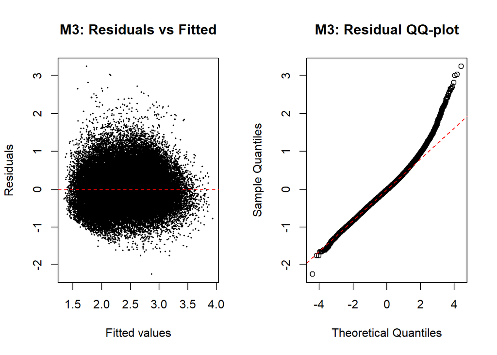

```r
# Simple residual diagnostics for M3
par(mfrow = c(1, 2))
plot(fitted(mod_M3), resid(mod_M3),
     pch = 16, cex = 0.3,
     xlab = "Fitted values", ylab = "Residuals",
     main = "M3: Residuals vs Fitted")
abline(h = 0, col = "red", lty = 2)

qqnorm(resid(mod_M3), main = "M3: Residual QQ-plot")
qqline(resid(mod_M3), col = "red", lty = 2)
```

```r
par(mfrow = c(1, 1))
```

From the residual vs fitted and residual QQ‑plot for M3:

Residual vs fitted: cloud is roughly symmetric around zero, with no strong funnel shape or obvious non‑linear pattern → variance is reasonably stable across the fitted range.

Residual QQ‑plot: middle of the distribution lies close to the 45° line, but the upper tail bends upwards (a few residuals much larger than Gaussian) and lower tail slightly downwards.

→ The log transformation handled most skewness, but there remain heavy tails and a small number of large residuals.

These diagnostics suggest that the log‑mixed model captures most systematic structure, but residuals remain heavy‑tailed, reinforcing the need for the robust and trimming experiments planned in the next section.

Conclusion: Across models M0–M3, hierarchy, routing, shipment features, and time controls explain a substantial share of variability in log‑delivery lead time. The M4 extensions then show that key routing and freight effects are heterogeneous across shipment regimes, with large fit gains relative to the pooled M3 baseline. Residuals remain heavy‑tailed, and multivariate shipment outliers are non-trivial, so the next section stress-tests inference with robust flat estimators, mixed-model variants, regional refits, and bootstrap intervals.

Model-engineering conclusion:

- Cluster-informed heterogeneity is not only descriptive; it materially improves model fit and changes substantive interpretation of effect sizes.
- `M4_c2_cluster_interactions` is the preferred inferential model in this run because it strongly outperforms both `M3_base` and `M4_c1_precluster_main` on likelihood and information criteria, while improving marginal $R^2$.
- Section 6 therefore stress-tests `M4_c2` directly.

# 6. Robustness & Bootstrap Analysis

**Observation:** Section 5 models fit well overall, but tails and influential profiles remain visible.

**Risk:** A small subset of atypical orders or sellers could distort fixed-effect inference and subgroup interpretation.

**Experiment design:** I run a sequence of sensitivity experiments on the same modelling sample: robust flat regressions, trimmed/variant mixed models, region-wise mixed models, and bootstrap uncertainty checks.

**Decision rule:** I treat conclusions as robust when key effect signs remain stable and effect magnitudes/CIs change only modestly across these stress tests.

This robustness section is anchored on the preferred M4_c2 specification.

```r
s6_data <- orders_mod_cluster
s6_model_ref <- mod_M4_c2

s6_core_terms <- c(
  "is_same_stateTRUE",
  "is_same_regionTRUE",
  "z_log_freight",
  "z_log_items",
  "z_log_value"
)

s6_terms_compare <- c(
  "is_same_stateTRUE",
  "is_same_regionTRUE",
  "z_log_freight",
  "z_log_items",
  "is_same_stateTRUE:precluster5",
  "precluster5:z_log_freight",
  "seasonJJA"
)

s6_fixed_terms <- paste(
  "is_same_state * precluster + is_same_region +",
  "z_log_wgt + z_log_vol + z_log_value + z_log_freight * precluster + z_log_items * precluster +",
  "season + purchase_year + theme_name"
)

s6_fixed_terms_no_theme <- paste(
  "is_same_state * precluster + is_same_region +",
  "z_log_wgt + z_log_vol + z_log_value + z_log_freight * precluster + z_log_items * precluster +",
  "season + purchase_year"
)

tibble::tibble(
  n_orders = nrow(s6_data),
  n_sellers = dplyr::n_distinct(s6_data$seller_id),
  n_customer_states = dplyr::n_distinct(s6_data$customer_state),
  n_preclusters = dplyr::n_distinct(s6_data$precluster)
)
```

| n_orders | n_sellers | n_customer_states | n_preclusters |
| --- | --- | --- | --- |
| 93853 | 2892 | 27 | 5 |

**Observation:** Delivery lead times are right-skewed with a long upper tail, residuals remain mildly heavy-tailed after log transformation, and some shipment/seller profiles are clearly atypical.

**Risk:** Classical estimates can be over-influenced by these tails/outliers.

```r
lead_quantiles <- stats::quantile(
  s6_data$lead_time_days_raw,
  probs = c(0.50, 0.90, 0.95, 0.99),
  na.rm = TRUE
)

std_resid <- as.numeric(scale(residuals(s6_model_ref)))
tail_share_25 <- mean(abs(std_resid) > 2.5, na.rm = TRUE)
tail_share_30 <- mean(abs(std_resid) > 3.0, na.rm = TRUE)

outlier_share_mcd <- if ("ship_outlier_mcd" %in% names(s6_data)) {
  mean(s6_data$ship_outlier_mcd, na.rm = TRUE)
} else {
  NA_real_
}

seller_re <- ranef(s6_model_ref)$seller_id[[1]]
seller_re_quantiles <- stats::quantile(seller_re, probs = c(0.01, 0.50, 0.99), na.rm = TRUE)

list(
  lead_time_quantiles_days = lead_quantiles,
  residual_tail_share_abs_gt_2_5 = tail_share_25,
  residual_tail_share_abs_gt_3_0 = tail_share_30,
  shipment_mcd_outlier_share = outlier_share_mcd,
  seller_random_intercept_quantiles = seller_re_quantiles
)
```

```
## $lead_time_quantiles_days
##      50%      90%      95%      99%
## 10.24818 23.14667 29.39409 46.18046
##
## $residual_tail_share_abs_gt_2_5
## [1] 0.01761265
##
## $residual_tail_share_abs_gt_3_0
## [1] 0.006883104
##
## $shipment_mcd_outlier_share
## [1] 0.09637412
##
## $seller_random_intercept_quantiles
##          1%         50%         99%
## -0.28641024 -0.01177465  0.41313119
```

**Experiment framing (AMS-consistent):** These diagnostics match the robust-settings from class (heavy tails, vertical outliers, leverage risk), so each subsection below tests whether the main effects survive alternative estimators and perturbations.